# Biologie et données : une nouvelle lecture de la biodiversité

### 5.2.18 Diversité de Shannon par site d’échantillonnage

Interprétation du graphique : diversité de Shannon par site d’échantillonnage Ce graphique compare la diversité biologique des communautés d’invertébrés et de poissons entre les différents sites d’échantillonnage, à partir de l’indice de Shannon.

L’indice de Shannon ($H'$) prend en compte à la fois le nombre d’OTU présentes (richesse) et leur répartition relative (équitabilité). Plus sa valeur est élevée, plus la diversité de la communauté est importante. À l’inverse, une valeur faible peut traduire une faible richesse en OTU et/ou une forte dominance de certaines OTU.

Le graphique présente deux panneaux : les invertébrés à gauche et les poissons à droite. Les points représentent les valeurs individuelles de Shannon, tandis que les boîtes résument leur distribution pour chaque site. 1. Diversité de Shannon chez les invertébrés Dans le panneau de gauche, les valeurs de Shannon sont globalement comprises entre 3,9 et 5,1.

Plusieurs observations se dégagent : - Le site **Berge des Baigneurs présente une diversité relativement élevée, avec des valeurs situées approximativement entre 4,7 et 5,1.** - Plusieurs sites, notamment **Les Écluses, Route Verte, Parc de la Fabrique et Parc André-J.-Côté, présentent également des valeurs relativement élevées, proches de 4,8 à 4,9.** - À l’inverse, des **valeurs plus faibles sont observées notamment à Descente rue Gilmour, Montée Robert, Parc Léon-Gravel et Parc du barrage, avec des valeurs proches de 3,9 à 4,4.** - La boîte associée à **Berge des Baigneurs** montre une dispersion relativement importante, indiquant une variabilité des valeurs entre les échantillons de ce site.

**Interprétation** : les communautés d’invertébrés présentent une diversité relativement élevée dans l’ensemble des sites, mais cette diversité varie d’un site à l’autre. Certains sites semblent abriter des communautés plus diversifiées et/ou présentant une répartition plus équilibrée des OTU que d’autres.

**2. Diversité de Shannon chez les poissons** Dans le panneau de droite, les valeurs de Shannon sont comprises approximativement entre 0 et 1,6, ce qui est nettement inférieur aux valeurs observées chez les invertébrés.

**Diversité de Shannon selon les sites d’échantillonnage**

L’analyse de l’indice de Shannon révèle des différences de diversité entre les sites d’échantillonnage et entre les deux groupes biologiques étudiés. Chez les invertébrés, les valeurs de Shannon varient approximativement entre 3,9 et 5,1. Les valeurs les plus élevées sont notamment observées à Berge des Baigneurs, tandis que des valeurs relativement faibles sont relevées à Descente rue Gilmour, Montée Robert et Parc Léon-Gravel. Globalement, les communautés d’invertébrés présentent des niveaux de diversité relativement élevés, malgré des variations entre les sites.

La comparaison des deux groupes a mis ainsi en évidence une diversité de Shannon plus élevée chez les invertébrés que chez les poissons. Par ailleurs, les variations observées entre les sites suggèrent une hétérogénéité spatiale de la diversité des communautés biologiques étudiées. Ces résultats descriptifs pourront être approfondis par des analyses statistiques afin d’évaluer la significativité des différences entre les sites d’échantillonnage.

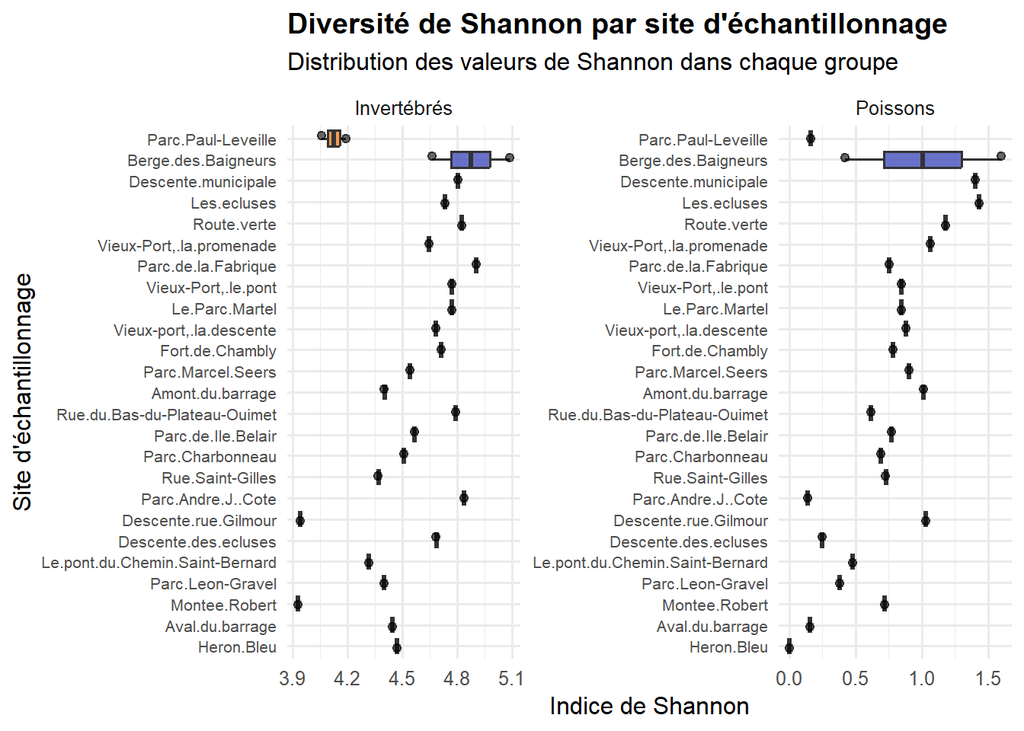

```r
## 31. Diversité de Shannon par site d'échantillonnage

ggplot2::ggplot(
  indices_diversite,
  ggplot2::aes(
    x = reorder(SiteEchantillonnage, Shannon, FUN = median),
    y = Shannon,
    fill = SiteEchantillonnage
  )
) +
  ggplot2::geom_boxplot(
    alpha = 0.8,
    outlier.shape = NA
  ) +
  ggplot2::geom_jitter(
    width = 0.15,
    alpha = 0.6,
    size = 1.8
  ) +
  ggplot2::facet_wrap(
    ~ Groupe,
    scales = "free"
  ) +
  ggplot2::coord_flip() +
  ggplot2::scale_fill_viridis_d(
    option = "turbo"
  ) +
  ggplot2::labs(
    title = "Diversité de Shannon par site d'échantillonnage",
    subtitle = "Distribution des valeurs de Shannon dans chaque groupe",
    x = "Site d'échantillonnage",
    y = "Indice de Shannon",
    fill = "Site"
  ) +
  ggplot2::theme_minimal(base_size = 12) +
  ggplot2::theme(
    plot.title = ggplot2::element_text(face = "bold"),
    axis.text.y = ggplot2::element_text(size = 8),
    legend.position = "none"
  )
```

### 5.2.19 Vérification des annotations taxonomiques

Chez les invertébrés : les 7 727 OTU présentes dans la matrice disposent d’une annotation taxonomique. Aucune OTU n’a été considérée comme non assignée par le contrôle effectué.

Chez les poissons : les 310 OTU disposent également d’une annotation taxonomique, soit un taux d’assignation de 100 % selon le même critère.

Ces résultats indiquent donc une couverture complète de l’annotation taxonomique au sens du contrôle réalisé. 2. Conclusion du bloc 28 L’analyse montre que l’ensemble des OTU des deux groupes possède une annotation taxonomique dans les fichiers analysés. Cette couverture constitue un résultat favorable pour la poursuite de l’analyse écologique, car elle permet d’examiner la composition taxonomique des communautés détectées.

Cependant, il est important de **distinguer annotation taxonomique et identification taxonomique précise. Une OTU peut être annotée uniquement au niveau du règne, de l’embranchement ou de la famille, sans être identifiée jusqu’au genre ou à l’espèce.**

Le *taux de 100 % ne signifie donc pas nécessairement que toutes les OTU ont été identifiées jusqu’à l’espèce.*

```r
## 32. Vérification des annotations taxonomiques

verifier_taxonomie <- function(matrice, groupe) {

  taxonomie <- trimws(as.character(matrice$taxonomy))

  non_assignees <- is.na(taxonomie) |
    taxonomie == "" |
    grepl(
      "unclassified|unassigned|unknown|unidentified|uncultured",
      taxonomie,
      ignore.case = TRUE
    )

  resultats <- data.frame(
    Groupe = groupe,
    Nombre_total_OTU = length(taxonomie),
    OTU_assignees = sum(!non_assignees),
    OTU_non_assignees = sum(non_assignees),
    Pourcentage_assignees = round(
      mean(!non_assignees) * 100,
      2
    ),
    Pourcentage_non_assignees = round(
      mean(non_assignees) * 100,
      2
    )
  )

  return(resultats)
}

taxonomie_invertebres <- verifier_taxonomie(
  data_invertebres,
  "Invertébrés"
)

taxonomie_poissons <- verifier_taxonomie(
  data_poissons,
  "Poissons"
)

resume_taxonomie <- dplyr::bind_rows(
  taxonomie_invertebres,
  taxonomie_poissons
)

print(as.data.frame(resume_taxonomie), row.names = FALSE)
```

```
##       Groupe Nombre_total_OTU OTU_assignees OTU_non_assignees
##  Invertébrés             7727          7727                 0
##     Poissons              310           310                 0
##  Pourcentage_assignees Pourcentage_non_assignees
##                    100                         0
##                    100                         0
```

### 5.2.20 Évaluation du niveau de résolution taxonomique

**Interprétation** Ces résultats apportent une précision importante à l’analyse du bloc 28 : même si 100 % des OTU possèdent une annotation taxonomique, toutes ne sont pas identifiées au même niveau de précision.

En effet, aucune OTU n’est identifiée jusqu’au niveau de l’espèce, ni chez les invertébrés ni chez les poissons. Les annotations sont principalement réparties entre les niveaux du genre, de la famille, de l’ordre, de la classe, de l’embranchement et du règne.

**–Analyse des résultats**

**A. Invertébrés** 7 727 OTU annotées - **46,71 % des OTU (3 609) disposent d’une annotation au niveau du genre.** - **51,09 % (3 948) sont annotées au niveau de la famille.** - **53,51 % (4 135) sont annotées au niveau de l’ordre.** - **58,78 % (4 542) sont annotées au niveau de la classe.** - **68,88 % (5 322) sont annotées au niveau de l’embranchement.** - **100 % (7 727) sont annotées au niveau du règne.** - **Aucune OTU n’est identifiée au niveau de l’espèce.** Cela montre que les invertébrés présentent une résolution taxonomique relativement variable. Une partie importante des OTU est identifiée au niveau du genre, mais une proportion plus importante reste associée à des niveaux taxonomiques supérieurs. **B. Poissons** 310 OTU annotées - **92,90 % des OTU (288) disposent d’une annotation au niveau du genre.** - **95,48 % (296) sont annotées au niveau de la famille.** - **95,81 % (297) sont annotées au niveau de l’ordre.** - **100 % (310) sont annotées au niveau de la classe, de l’embranchement et du règne.** - **Aucune OTU n’est identifiée au niveau de l’espèce.** Les résultats montrent une meilleure résolution taxonomique des OTU de poissons au niveau du genre par rapport aux invertébrés. En effet, près de 93 % des OTU de poissons sont annotées à ce niveau, contre environ 47 % chez les invertébrés.

```r
## 33. Évaluation du niveau de résolution taxonomique

analyser_resolution_taxonomique <- function(matrice, groupe) {

  taxonomie <- trimws(as.character(matrice$taxonomy))

  niveaux <- c(
    "Espèce" = "species|s__",
    "Genre" = "genus|g__",
    "Famille" = "family|f__",
    "Ordre" = "order|o__",
    "Classe" = "class|c__",
    "Embranchement" = "phylum|p__",
    "Règne" = "kingdom|k__"
  )

  resultats <- lapply(names(niveaux), function(niveau) {

    motif <- niveaux[[niveau]]

    nombre <- sum(
      grepl(motif, taxonomie, ignore.case = TRUE),
      na.rm = TRUE
    )

    data.frame(
      Groupe = groupe,
      Niveau_taxonomique = niveau,
      Nombre_OTU = nombre,
      Pourcentage = round(
        nombre / length(taxonomie) * 100, 2
      )
    )
  })

  dplyr::bind_rows(resultats)
}

resolution_invertebres <- analyser_resolution_taxonomique(
  data_invertebres, "Invertébrés"
)

resolution_poissons <- analyser_resolution_taxonomique(
  data_poissons, "Poissons"
)

resolution_taxonomique <- dplyr::bind_rows(
  resolution_invertebres,
  resolution_poissons
)

print(resolution_taxonomique)
```

```
##         Groupe Niveau_taxonomique Nombre_OTU Pourcentage
## 1  Invertébrés             Espèce          0        0.00
## 2  Invertébrés              Genre       3609       46.71
## 3  Invertébrés            Famille       3948       51.09
## 4  Invertébrés              Ordre       4135       53.51
## 5  Invertébrés             Classe       4542       58.78
## 6  Invertébrés      Embranchement       5322       68.88
## 7  Invertébrés              Règne       7727      100.00
## 8     Poissons             Espèce          0        0.00
## 9     Poissons              Genre        288       92.90
## 10    Poissons            Famille        296       95.48
## 11    Poissons              Ordre        297       95.81
## 12    Poissons             Classe        310      100.00
## 13    Poissons      Embranchement        310      100.00
## 14    Poissons              Règne        310      100.00
```

### 5.2.21 Comparaison de la résolution taxonomique

**Interprétation**

L’analyse de la résolution taxonomique met en évidence une différence entre les deux groupes étudiés. Les OTU de poissons présentent une meilleure résolution taxonomique que celles des invertébrés, notamment au niveau du genre. En effet, 92,90 % des OTU de poissons sont annotées à ce niveau, contre 46,71 % chez les invertébrés.

Chez les invertébrés, la résolution taxonomique diminue progressivement des niveaux supérieurs vers les niveaux plus précis. Ainsi, si 100 % des OTU possèdent une annotation au niveau du règne, seules 68,88 % sont annotées au niveau de l’embranchement et 46,71 % au niveau du genre. Cette situation traduit une résolution taxonomique plus limitée pour une partie importante des séquences analysées.

Chez les poissons, la majorité des OTU bénéficie d’une annotation au niveau du genre (92,90 %), ce qui permet une caractérisation taxonomique relativement précise des séquences détectées. Toutefois, aucune OTU des deux groupes n’a été assignée au niveau de l’espèce.

Plusieurs facteurs pourraient expliquer ces différences de résolution, notamment **la représentation des organismes dans les bases de référence génétiques, les caractéristiques des marqueurs moléculaires utilisés, la spécificité des amorces et les paramètres d’assignation taxonomique. Ces facteurs constituent des explications possibles qui nécessiteraient des vérifications complémentaires.**

Il convient également de souligner que **les matrices analysées peuvent contenir des séquences provenant d’organismes autres que les groupes initialement ciblés.** *Une vérification de la composition taxonomique globale est donc nécessaire avant de considérer toutes les OTU comme appartenant exclusivement aux invertébrés ou aux poissons.*

En définitive, les résultats montrent une meilleure résolution taxonomique des séquences du groupe poissons au niveau du genre. Cependant, l’absence d’identification au niveau de l’espèce et les différences de résolution observées doivent être prises en compte dans l’interprétation de la composition des communautés détectées par l’ADNe.

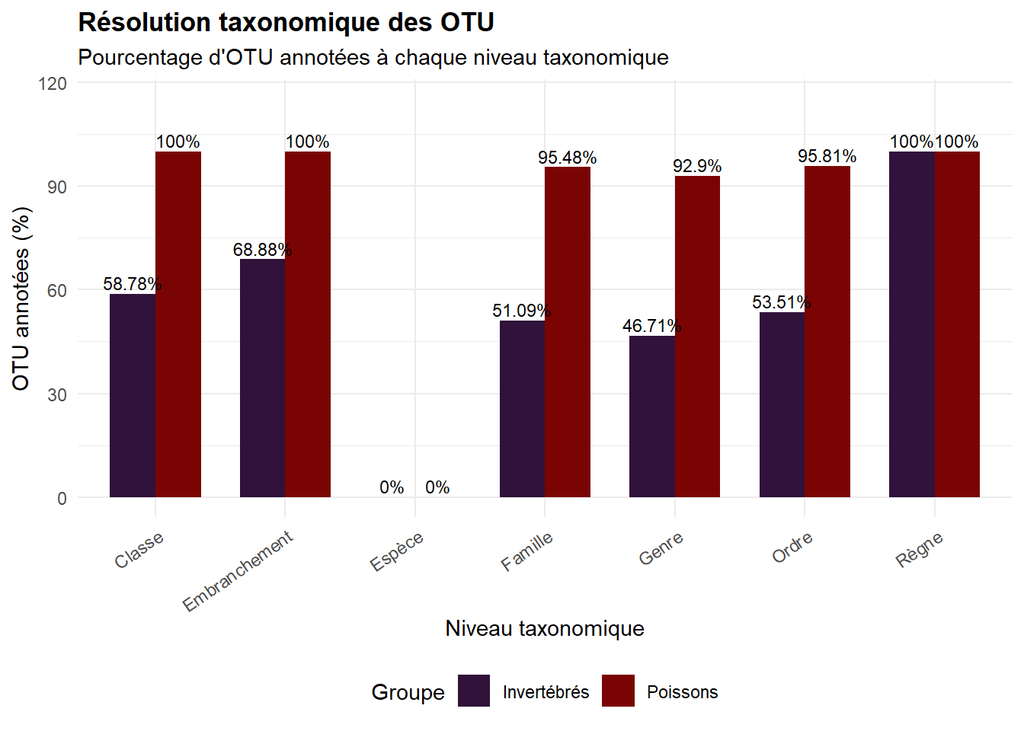

```r
## 34. Comparaison de la résolution taxonomique

library(ggplot2)

ggplot(
  resolution_taxonomique,
  aes(
    x = Niveau_taxonomique,
    y = Pourcentage,
    fill = Groupe
  )
) +
  geom_col(
    position = "dodge",
    width = 0.7
  ) +
  geom_text(
    aes(label = paste0(Pourcentage, "%")),
    position = position_dodge(width = 0.7),
    vjust = -0.3,
    size = 3
  ) +
  scale_fill_viridis_d(option = "turbo") +
  labs(
    title = "Résolution taxonomique des OTU",
    subtitle = "Pourcentage d'OTU annotées à chaque niveau taxonomique",
    x = "Niveau taxonomique",
    y = "OTU annotées (%)",
    fill = "Groupe"
  ) +
  coord_cartesian(ylim = c(0, 115)) +
  theme_minimal() +
  theme(
    axis.text.x = element_text(
      angle = 35,
      hjust = 1
    ),
    legend.position = "bottom",
    plot.title = element_text(face = "bold")
  )
```

### 5.2.22 Exploration des annotations taxonomiques

L’exploration des annotations taxonomiques a permis de vérifier leur organisation, d’identifier les niveaux de classification disponibles et de préparer la détection des annotations taxonomiques atypiques.

```r
## 35. Exploration des annotations taxonomiques

# 1. Vérifier quelques annotations chez les invertébrés
cat("\n===== EXEMPLES D'ANNOTATIONS TAXONOMIQUES : INVERTÉBRÉS =====\n")
```

```
##
## ===== EXEMPLES D'ANNOTATIONS TAXONOMIQUES : INVERTÉBRÉS =====
```

```r
exemples_taxonomie_invertebres <- data.frame(
  OTU = data_invertebres$`#FEATURE_ID`,
  Taxonomie = as.character(data_invertebres$taxonomy)
) %>%
  dplyr::distinct() %>%
  dplyr::slice_head(n = 15)

print(exemples_taxonomie_invertebres, row.names = FALSE)
```

```
##  OTU
##    1
##    2
##    3
##    4
##    5
##    6
##    7
##    8
##    9
##   11
##   12
##   13
##   14
##   15
##   16
##                                                                                                             Taxonomie
##                                                                                                         k__Eukaryota;
##                                                                                 k__Eukaryota;p__Cnidaria;c__Hydrozoa;
##                                                                                                         k__Eukaryota;
##         k__Eukaryota;p__undef-PH-Eukaryota;c__Haptophyta;o__Prymnesiales;f__Chrysochromulinaceae;g__Chrysochromulina;
##                       k__Eukaryota;p__Ochrophyta;c__Xanthophyceae;o__Mischococcales;f__Pleurochloridaceae;g__Monodus;
##           k__Eukaryota;p__Chlorophyta;c__Mamiellophyceae;o__Dolichomastigales;f__Dolichomastigaceae;g__Dolichomastix;
##  k__Bacteria;p__Proteobacteria;c__Alphaproteobacteria;o__Holosporales;f__Caedimonadaceae;g__Candidatus Nucleicultrix;
##                                                                                                         k__Eukaryota;
##                                                                                          k__Eukaryota;p__Chlorophyta;
##                                                                                      k__Eukaryota;p__Bacillariophyta;
##                                                                                          k__Eukaryota;p__Chlorophyta;
##                                                                                                         k__Eukaryota;
##                                                                           k__Eukaryota;p__Ochrophyta;c__Phaeophyceae;
##                                                                                      k__Eukaryota;p__Bacillariophyta;
##    k__Eukaryota;p__Bacillariophyta;c__Coscinodiscophyceae;o__Thalassiosirales;f__Stephanodiscaceae;g__Cyclostephanos;
```

```r
# 2. Vérifier quelques annotations chez les poissons
cat("\n===== EXEMPLES D'ANNOTATIONS TAXONOMIQUES : POISSONS =====\n")
```

```
##
## ===== EXEMPLES D'ANNOTATIONS TAXONOMIQUES : POISSONS =====
```

```r
exemples_taxonomie_poissons <- data.frame(
  OTU = data_poissons$`#FEATURE_ID`,
  Taxonomie = as.character(data_poissons$taxonomy)
) %>%
  dplyr::distinct() %>%
  dplyr::slice_head(n = 15)

print(exemples_taxonomie_poissons, row.names = FALSE)
```

```
##  OTU
##    1
##    2
##    3
##    4
##    5
##    6
##    7
##    8
##    9
##   10
##   11
##   12
##   13
##   14
##   15
##                                                                                                        Taxonomie
##                                           k__Eukaryota;p__Chordata;c__Mammalia;o__Primates;f__Hominidae;g__Homo;
##                     k__Eukaryota;p__Chordata;c__Actinopteri;o__Centrarchiformes;f__Centrarchidae;g__Ambloplites;
##                         k__Eukaryota;p__Chordata;c__Actinopteri;o__Centrarchiformes;f__Centrarchidae;g__Lepomis;
##                                                                         k__Eukaryota;p__Chordata;c__Actinopteri;
##                             k__Eukaryota;p__Chordata;c__Actinopteri;o__Cypriniformes;f__Cyprinidae;g__Lythrurus;
##                              k__Eukaryota;p__Chordata;c__Actinopteri;o__Cypriniformes;f__Cyprinidae;g__Notropis;
##                                     k__Eukaryota;p__Chordata;c__Actinopteri;o__Perciformes;f__Percidae;g__Perca;
##                                      k__Eukaryota;p__Chordata;c__Actinopteri;o__Esociformes;f__Esocidae;g__Esox;
##                                 k__Eukaryota;p__Chordata;c__Actinopteri;o__Cypriniformes;f__Cyprinidae;g__Tinca;
##                                k__Eukaryota;p__Chordata;c__Actinopteri;o__Perciformes;f__Percidae;g__Etheostoma;
##                             k__Eukaryota;p__Chordata;c__Actinopteri;o__Siluriformes;f__Ictaluridae;g__Ictalurus;
##                     k__Eukaryota;p__Chordata;c__Actinopteri;o__Centrarchiformes;f__Centrarchidae;g__Ambloplites;
##                                      k__Eukaryota;p__Chordata;c__Actinopteri;o__Esociformes;f__Esocidae;g__Esox;
##  k__Bacteria;p__Proteobacteria;c__Deltaproteobacteria;o__Desulfovibrionales;f__Desulfovibrionaceae;g__Bilophila;
##                           k__Eukaryota;p__Chordata;c__Actinopteri;o__Cypriniformes;f__Cyprinidae;g__Notemigonus;
```

```r
# 3. Examiner les séparateurs utilisés dans les annotations
cat("\n===== SÉPARATEURS UTILISÉS =====\n")
```

```
##
## ===== SÉPARATEURS UTILISÉS =====
```

```r
separateurs_taxonomie <- data.frame(
  Groupe = c("Invertébrés", "Poissons"),
  Point_virgule = c(
    sum(grepl(";", data_invertebres$taxonomy, fixed = TRUE), na.rm = TRUE),
    sum(grepl(";", data_poissons$taxonomy, fixed = TRUE), na.rm = TRUE)
  ),
  Barre_verticale = c(
    sum(grepl("|", data_invertebres$taxonomy, fixed = TRUE), na.rm = TRUE),
    sum(grepl("|", data_poissons$taxonomy, fixed = TRUE), na.rm = TRUE)
  ),
  Virgule = c(
    sum(grepl(",", data_invertebres$taxonomy, fixed = TRUE), na.rm = TRUE),
    sum(grepl(",", data_poissons$taxonomy, fixed = TRUE), na.rm = TRUE)
  )
)

print(separateurs_taxonomie, row.names = FALSE)
```

```
##       Groupe Point_virgule Barre_verticale Virgule
##  Invertébrés          7727               0       0
##     Poissons           310               0       0
```

```r
# 4. Vérifier les valeurs taxonomiques manquantes
controle_annotations <- data.frame(
  Groupe = c("Invertébrés", "Poissons"),
  Total_OTU = c(
    nrow(data_invertebres),
    nrow(data_poissons)
  ),
  Taxonomie_manquante = c(
    sum(is.na(data_invertebres$taxonomy) |
          trimws(as.character(data_invertebres$taxonomy)) == ""),
    sum(is.na(data_poissons$taxonomy) |
          trimws(as.character(data_poissons$taxonomy)) == "")
  )
)

print(controle_annotations, row.names = FALSE)
```

```
##       Groupe Total_OTU Taxonomie_manquante
##  Invertébrés      7727                   0
##     Poissons       310                   0
```

### 5.2.23 Extraction et caractérisation des niveaux taxonomiques

L’extraction des annotations taxonomiques a permis de structurer les données en sept niveaux : règne, embranchement, classe, ordre, famille, genre et espèce. Au total, **8 037 OTU ont été traitées**, dont **7 727 pour les invertébrés** et **310 pour les poissons.**

Les premières observations révèlent une **hétérogénéité dans le niveau de résolution taxonomique des OTU.** Pour les invertébrés, **certaines séquences sont identifiées jusqu’au genre, tandis que d’autres ne sont renseignées qu’au niveau du règne ou de l’embranchement.** Les annotations comprennent également **plusieurs groupes d’algues et de micro-organismes eucaryotes**, ainsi que **des séquences bactériennes**. Cette diversité d’annotations invite à examiner la composition taxonomique de la matrice avant de considérer l’ensemble des OTU comme représentatif des invertébrés.

Pour les poissons, les annotations sont majoritairement associées à **l’embranchement des Chordés et à la classe des Actinoptérygiens.** **Plusieurs OTU sont identifiées jusqu’au genre.** Toutefois, une annotation correspondant au genre Homo, rattaché aux mammifères, a été observée. Cette attribution atypique devra faire l’objet d’une vérification dans le cadre du contrôle de qualité des données.

Dans l’ensemble, cette étape confirme que les annotations présentent des niveaux de précision variables et que leur cohérence biologique doit être examinée avant les analyses approfondies de composition taxonomique.

```r
## 36. Extraction des niveaux taxonomiques

# Fonction d'extraction des niveaux taxonomiques
extraire_niveaux_taxonomiques <- function(matrice, groupe) {

  taxonomie <- as.character(matrice$taxonomy)

  # Fonction permettant d'extraire un niveau taxonomique
  extraire_niveau <- function(x, prefixe) {

    resultat <- rep(NA_character_, length(x))

    # Repérer les annotations contenant le préfixe recherché
    positions <- grep(prefixe, x, fixed = TRUE)

    if (length(positions) > 0) {

      # Extraire la partie correspondant au niveau taxonomique
      valeurs <- vapply(
        positions,
        function(i) {
          morceaux <- strsplit(x[i], ";", fixed = TRUE)[[1]]
          element <- morceaux[startsWith(morceaux, prefixe)]

          if (length(element) == 0) {
            return(NA_character_)
          }

          sub(
            paste0("^", prefixe),
            "",
            element[1]
          )
        },
        character(1)
      )

      resultat[positions] <- valeurs
    }

    # Remplacer les annotations non résolues par NA
    resultat <- trimws(resultat)

    resultat[
      is.na(resultat) |
        resultat == "" |
        grepl(
          "undef|unclassified|unknown|uncultured|unidentified",
          resultat,
          ignore.case = TRUE
        )
    ] <- NA_character_

    return(resultat)
  }

  # Création du tableau taxonomique
  data.frame(
    OTU = as.character(matrice$`#FEATURE_ID`),
    Groupe = rep(groupe, nrow(matrice)),
    Regne = extraire_niveau(taxonomie, "k__"),
    Embranchement = extraire_niveau(taxonomie, "p__"),
    Classe = extraire_niveau(taxonomie, "c__"),
    Ordre = extraire_niveau(taxonomie, "o__"),
    Famille = extraire_niveau(taxonomie, "f__"),
    Genre = extraire_niveau(taxonomie, "g__"),
    Espece = extraire_niveau(taxonomie, "s__"),
    stringsAsFactors = FALSE
  )
}


# Extraction pour les invertébrés
niveaux_invertebres <- extraire_niveaux_taxonomiques(
  data_invertebres,
  "Invertébrés"
)

# Extraction pour les poissons
niveaux_poissons <- extraire_niveaux_taxonomiques(
  data_poissons,
  "Poissons"
)


# Regroupement des deux tableaux
niveaux_taxonomiques_complets <- dplyr::bind_rows(
  niveaux_invertebres,
  niveaux_poissons
)


# Vérification des résultats
cat("\n===== EXTRACTION TAXONOMIQUE : INVERTÉBRÉS =====\n")
```

```
##
## ===== EXTRACTION TAXONOMIQUE : INVERTÉBRÉS =====
```

```r
print(head(niveaux_invertebres, 10))
```

```
##    OTU      Groupe     Regne   Embranchement              Classe
## 1    1 Invertébrés Eukaryota            <NA>                <NA>
## 2    2 Invertébrés Eukaryota        Cnidaria            Hydrozoa
## 3    3 Invertébrés Eukaryota            <NA>                <NA>
## 4    4 Invertébrés Eukaryota            <NA>          Haptophyta
## 5    5 Invertébrés Eukaryota      Ochrophyta       Xanthophyceae
## 6    6 Invertébrés Eukaryota     Chlorophyta     Mamiellophyceae
## 7    7 Invertébrés  Bacteria  Proteobacteria Alphaproteobacteria
## 8    8 Invertébrés Eukaryota            <NA>                <NA>
## 9    9 Invertébrés Eukaryota     Chlorophyta                <NA>
## 10  11 Invertébrés Eukaryota Bacillariophyta                <NA>
##                Ordre              Famille                    Genre Espece
## 1               <NA>                 <NA>                     <NA>   <NA>
## 2               <NA>                 <NA>                     <NA>   <NA>
## 3               <NA>                 <NA>                     <NA>   <NA>
## 4       Prymnesiales Chrysochromulinaceae         Chrysochromulina   <NA>
## 5     Mischococcales   Pleurochloridaceae                  Monodus   <NA>
## 6  Dolichomastigales   Dolichomastigaceae            Dolichomastix   <NA>
## 7       Holosporales      Caedimonadaceae Candidatus Nucleicultrix   <NA>
## 8               <NA>                 <NA>                     <NA>   <NA>
## 9               <NA>                 <NA>                     <NA>   <NA>
## 10              <NA>                 <NA>                     <NA>   <NA>
```

```r
cat("\n===== EXTRACTION TAXONOMIQUE : POISSONS =====\n")
```

```
##
## ===== EXTRACTION TAXONOMIQUE : POISSONS =====
```

```r
print(head(niveaux_poissons, 10))
```

```
##    OTU   Groupe     Regne Embranchement      Classe            Ordre
## 1    1 Poissons Eukaryota      Chordata    Mammalia         Primates
## 2    2 Poissons Eukaryota      Chordata Actinopteri Centrarchiformes
## 3    3 Poissons Eukaryota      Chordata Actinopteri Centrarchiformes
## 4    4 Poissons Eukaryota      Chordata Actinopteri             <NA>
## 5    5 Poissons Eukaryota      Chordata Actinopteri    Cypriniformes
## 6    6 Poissons Eukaryota      Chordata Actinopteri    Cypriniformes
## 7    7 Poissons Eukaryota      Chordata Actinopteri      Perciformes
## 8    8 Poissons Eukaryota      Chordata Actinopteri      Esociformes
## 9    9 Poissons Eukaryota      Chordata Actinopteri    Cypriniformes
## 10  10 Poissons Eukaryota      Chordata Actinopteri      Perciformes
##          Famille       Genre Espece
## 1      Hominidae        Homo   <NA>
## 2  Centrarchidae Ambloplites   <NA>
## 3  Centrarchidae     Lepomis   <NA>
## 4           <NA>        <NA>   <NA>
## 5     Cyprinidae   Lythrurus   <NA>
## 6     Cyprinidae    Notropis   <NA>
## 7       Percidae       Perca   <NA>
## 8       Esocidae        Esox   <NA>
## 9     Cyprinidae       Tinca   <NA>
## 10      Percidae  Etheostoma   <NA>
```

```r
# Vérification du nombre d'OTU extraites
cat("\n===== NOMBRE D'OTU APRÈS EXTRACTION =====\n")
```

```
##
## ===== NOMBRE D'OTU APRÈS EXTRACTION =====
```

```r
verification_extraction <- niveaux_taxonomiques_complets %>%
  dplyr::group_by(Groupe) %>%
  dplyr::summarise(
    Nombre_OTU = dplyr::n(),
    .groups = "drop"
  )

print(verification_extraction)
```

```
## # A tibble: 2 × 2
##   Groupe      Nombre_OTU
##   <chr>            <int>
## 1 Invertébrés       7727
## 2 Poissons           310
```

### 5.2.24 Analyse de la répartition des OTU par règne selon le règne taxonomique

L’analyse de la répartition des OTU selon le règne taxonomique met en évidence la présence de deux grands groupes dans les matrices étudiées : les **Eukaryota et les Bacteria**.

Dans la matrice des invertébrés, les Eukaryota représentent **75,3 % des OTU (5 816 OTU)**, contre **24,7 % pour les Bacteria (1 911 OTU)**. Les séquences eucaryotes sont donc majoritaires, mais la proportion d’OTU annotées comme bactériennes reste importante.

Dans la matrice des poissons, les Eukaryota représentent **88,4 % des OTU (274 OTU)**, tandis que les Bacteria correspondent à **11,6 % (36 OTU)**. La proportion d’OTU eucaryotes est ainsi plus élevée dans cette matrice que dans celle des invertébrés.

La comparaison des deux groupes révèle une différence de 13,1 points de pourcentage dans la proportion d’OTU bactériennes, plus élevée dans la matrice des invertébrés. Cette différence doit toutefois être interprétée avec prudence, car les deux analyses moléculaires peuvent reposer sur des marqueurs et des paramètres d’assignation taxonomique différents.

**Ces résultats soulignent la nécessité d’examiner plus précisément la composition taxonomique des OTU et leur présence dans les échantillons biologiques et les blancs, afin de distinguer les séquences pertinentes pour les groupes étudiés des éventuelles contaminations ou assignations taxonomiques atypiques**.

```r
## 37. Analyse de la répartition des OTU par règne

# 1. Comptage des OTU par règne et par groupe
repartition_regnes <- niveaux_taxonomiques_complets %>%
  dplyr::mutate(
    Regne = dplyr::if_else(
      is.na(Regne),
      "Non renseigné",
      Regne
    )
  ) %>%
  dplyr::group_by(Groupe, Regne) %>%
  dplyr::summarise(
    Nombre_OTU = dplyr::n(),
    .groups = "drop"
  ) %>%
  dplyr::group_by(Groupe) %>%
  dplyr::mutate(
    Pourcentage = round(
      Nombre_OTU / sum(Nombre_OTU) * 100,
      2
    )
  ) %>%
  dplyr::ungroup()

print(repartition_regnes)
```

```
## # A tibble: 4 × 4
##   Groupe      Regne     Nombre_OTU Pourcentage
##   <chr>       <chr>          <int>       <dbl>
## 1 Invertébrés Bacteria        1911        24.7
## 2 Invertébrés Eukaryota       5816        75.3
## 3 Poissons    Bacteria          36        11.6
## 4 Poissons    Eukaryota        274        88.4
```

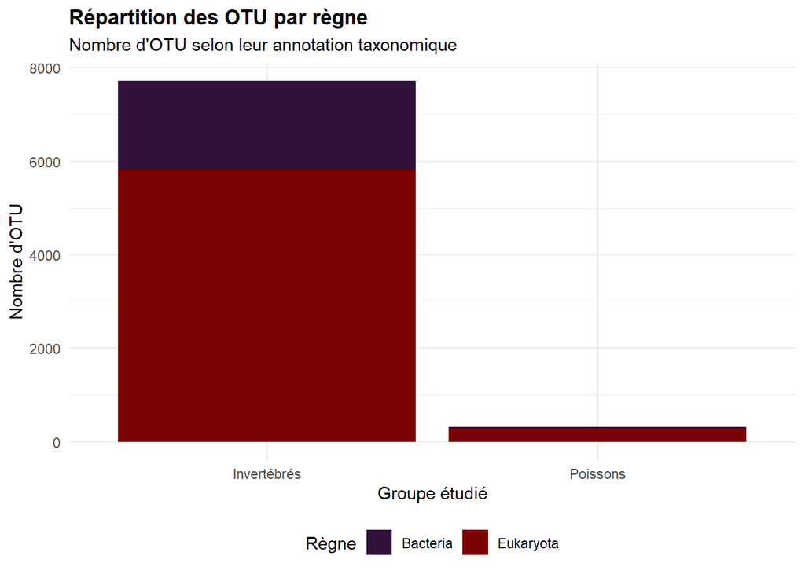

```r
# 2. Graphique de répartition par règne
graphique_regnes <- ggplot(
  repartition_regnes,
  aes(x = Groupe, y = Nombre_OTU, fill = Regne)
) +
  geom_col(position = "stack") +
  labs(
    title = "Répartition des OTU par règne",
    subtitle = "Nombre d'OTU selon leur annotation taxonomique",
    x = "Groupe étudié",
    y = "Nombre d'OTU",
    fill = "Règne"
  ) +
  scale_fill_viridis_d(option = "turbo") +
  theme_minimal() +
  theme(
    plot.title = element_text(face = "bold"),
    legend.position = "bottom"
  )

print(graphique_regnes)
```

```r
# 3. Tableau des pourcentages
tableau_pourcentages_regnes <- repartition_regnes %>%
  dplyr::select(Groupe, Regne, Pourcentage) %>%
  tidyr::pivot_wider(
    names_from = Regne,
    values_from = Pourcentage,
    values_fill = 0
  )

print(tableau_pourcentages_regnes)
```

```
## # A tibble: 2 × 3
##   Groupe      Bacteria Eukaryota
##   <chr>          <dbl>     <dbl>
## 1 Invertébrés     24.7      75.3
## 2 Poissons        11.6      88.4
```

###Répartition des OTU selon les embranchements taxonomiques

L’analyse de la répartition des OTU selon les embranchements taxonomiques met en évidence des différences importantes entre les deux groupes étudiés.

Dans la matrice des invertébrés, les annotations sont réparties entre plusieurs embranchements. Les **Bacteroidetes** constituent le groupe le plus représenté avec *1 259 OTU (16,3 %)*, suivis des **Arthropoda avec 803 OTU (10,4 %)**, des **Ochrophyta avec 694 OTU (8,98 %*) **et des** Proteobacteria avec 523 OTU (6,77 %)**. Les Rotifera représentent également une proportion notable, avec** 492 OTU (6,37 %)**. Cette distribution révèle *la présence d’annotations appartenant à différents groupes biologiques, notamment des animaux, des bactéries et des organismes photosynthétiques*.

Dans la matrice des poissons, l’embranchement des **Chordata** domine largement, avec **264 OTU, soit 85,2 % du total**. Cette prédominance est cohérente avec l’objectif de caractérisation des poissons, qui appartiennent à cet embranchement. Les **46 autres OTU (14,8 %)** sont réparties entre différents embranchements, notamment les **Verrucomicrobia, les Proteobacteria et les Planctomycetes**.

La comparaison des deux matrices montre ainsi une distribution taxonomique plus concentrée chez les poissons, dominée par les Chordata, tandis que les annotations de la matrice des invertébrés sont réparties entre un plus grand nombre d’embranchements.

La *présence d’annotations bactériennes et d’autres groupes ne correspondant pas directement aux organismes ciblés souligne la nécessité de poursuivre les vérifications taxonomiques et le contrôle de qualité des données.* Ces résultats décrivent la répartition des annotations obtenues et ne constituent pas une mesure directe de l’abondance des organismes dans les milieux échantillonnés.

```r
## 38. Répartition des OTU par embranchement

# 1. Comptage des OTU par embranchement
repartition_embranchements <- niveaux_taxonomiques_complets %>%
  dplyr::mutate(
    Embranchement = dplyr::if_else(
      is.na(Embranchement),
      "Non renseigné",
      Embranchement
    )
  ) %>%
  dplyr::group_by(Groupe, Embranchement) %>%
  dplyr::summarise(
    Nombre_OTU = dplyr::n(),
    .groups = "drop"
  ) %>%
  dplyr::group_by(Groupe) %>%
  dplyr::mutate(
    Pourcentage = round(
      Nombre_OTU / sum(Nombre_OTU) * 100,
      2
    )
  ) %>%
  dplyr::ungroup()


# 2. Afficher le tableau complet
print(repartition_embranchements)
```

```
## # A tibble: 43 × 4
##    Groupe      Embranchement      Nombre_OTU Pourcentage
##    <chr>       <chr>                   <int>       <dbl>
##  1 Invertébrés Actinobacteria              8        0.1
##  2 Invertébrés Amoebozoa                  13        0.17
##  3 Invertébrés Annelida                   82        1.06
##  4 Invertébrés Arthropoda                803       10.4
##  5 Invertébrés Ascomycota                130        1.68
##  6 Invertébrés Bacillariophyta           237        3.07
##  7 Invertébrés Bacteroidetes            1259       16.3
##  8 Invertébrés Basidiomycota              34        0.44
##  9 Invertébrés Blastocladiomycota          5        0.06
## 10 Invertébrés Bryozoa                    10        0.13
## # ℹ 33 more rows
```

```r
# 3. Identifier les 10 embranchements les plus représentés
top10_embranchements <- repartition_embranchements %>%
  dplyr::filter(Embranchement != "Non renseigné") %>%
  dplyr::group_by(Groupe) %>%
  dplyr::slice_max(
    order_by = Nombre_OTU,
    n = 10,
    with_ties = FALSE
  ) %>%
  dplyr::ungroup()

print(top10_embranchements)
```

```
## # A tibble: 20 × 4
##    Groupe      Embranchement         Nombre_OTU Pourcentage
##    <chr>       <chr>                      <int>       <dbl>
##  1 Invertébrés Bacteroidetes               1259       16.3
##  2 Invertébrés Arthropoda                   803       10.4
##  3 Invertébrés Ochrophyta                   694        8.98
##  4 Invertébrés Proteobacteria               523        6.77
##  5 Invertébrés Rotifera                     492        6.37
##  6 Invertébrés Chlorophyta                  371        4.8
##  7 Invertébrés Bacillariophyta              237        3.07
##  8 Invertébrés Oomycota                     135        1.75
##  9 Invertébrés Ascomycota                   130        1.68
## 10 Invertébrés Cnidaria                     109        1.41
## 11 Poissons    Chordata                     264       85.2
## 12 Poissons    Verrucomicrobia               11        3.55
## 13 Poissons    Proteobacteria                 8        2.58
## 14 Poissons    Planctomycetes                 7        2.26
## 15 Poissons    Myzozoa                        6        1.94
## 16 Poissons    Armatimonadetes                4        1.29
## 17 Poissons    Bacillariophyta                4        1.29
## 18 Poissons    Chloroflexi                    3        0.97
## 19 Poissons    Bacteroidetes                  2        0.65
## 20 Poissons    Thermodesulfobacteria          1        0.32
```

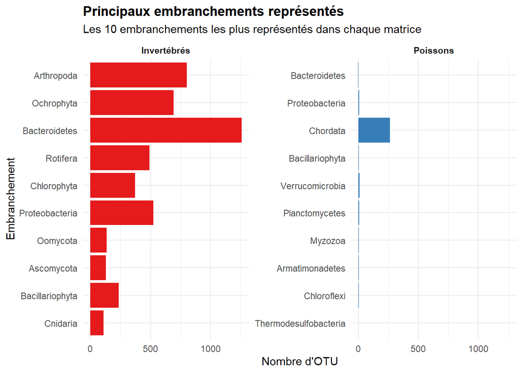

```r
# 4. Graphique des 10 embranchements les plus représentés
graphique_embranchements <- ggplot(
  top10_embranchements,
  aes(
    x = reorder(Embranchement, Nombre_OTU),
    y = Nombre_OTU,
    fill = Groupe
  )
) +
  geom_col(show.legend = FALSE) +
  coord_flip() +
  facet_wrap(~ Groupe, scales = "free_y") +
  scale_fill_brewer(palette = "Set1") +
  labs(
    title = "Principaux embranchements représentés",
    subtitle = "Les 10 embranchements les plus représentés dans chaque matrice",
    x = "Embranchement",
    y = "Nombre d'OTU"
  ) +
  theme_minimal() +
  theme(
    plot.title = element_text(face = "bold"),
    strip.text = element_text(face = "bold")
  )

print(graphique_embranchements)
```

###Analyse de la composition taxonomique au niveau des familles et des genres

L’analyse de la composition taxonomique au niveau des familles et des genres met en évidence une diversité d’affiliations taxonomiques dans les deux matrices étudiées. **Chez les invertébrés, les familles Chitinophagaceae (6,26 %), Flavobacteriaceae (5,97 %) et Alteromonadaceae (4,68 %) sont les plus représentées. Au niveau du genre, les principales annotations concernent Glaciecola (4,68 %), Filimonas (4,26 %), Polyarthra (3,52 %) et Flavobacterium (3,07 %).** La *présence de familles et de genres bactériens, algaux et animaux montre que les annotations obtenues ne se limitent pas exclusivement aux organismes invertébrés.*

Dans la matrice des poissons, **les familles Centrarchidae (20,3 %), Hominidae (14,8 %) et Percidae (11,3 %) sont les plus représentées. Au niveau du genre, Homo (14,2 %), Lepomis (13,2 %), Esox (7,74 %) et Ambloplites (7,10 %) occupent les premières positions.** Si plusieurs genres identifiés correspondent à des poissons, la **présence de taxons associés aux mammifères, notamment Homo et Bos, constitue une anomalie apparente par rapport à la cible de l’analyse.** Ces annotations nécessitent des vérifications complémentaires avant toute interprétation écologique.

L’évaluation de la **résolution taxonomique montre que 48,8 % des OTU de la matrice des invertébrés sont identifiés au niveau de la famille et 44,4 % au niveau du genre.** Pour les **poissons**, ces proportions **atteignent respectivement 91,0 % et 87,1 %. La matrice des poissons présente ainsi une couverture taxonomique plus élevée aux niveaux étudiés.** Cette différence pourrait notamment être liée aux caractéristiques des marqueurs moléculaires et à la représentation des taxons dans les bases de référence.

Dans l’ensemble, ces résultats soulignent l’intérêt de l’analyse taxonomique à plusieurs niveaux, tout en mettant en évidence la nécessité d’un contrôle de cohérence des annotations avant de retenir les OTU pour les analyses écologiques ultérieures.

```r
## 39. Analyse de la composition taxonomique par famille et par genre


# A. REPARTITION DES OTU PAR FAMILLE

repartition_familles <- niveaux_taxonomiques_complets %>%
  dplyr::mutate(
    Famille = dplyr::if_else(
      is.na(Famille), "Non renseignée", Famille
    )
  ) %>%
  dplyr::group_by(Groupe, Famille) %>%
  dplyr::summarise(
    Nombre_OTU = dplyr::n(),
    .groups = "drop"
  ) %>%
  dplyr::group_by(Groupe) %>%
  dplyr::mutate(
    Pourcentage = round(
      Nombre_OTU / sum(Nombre_OTU) * 100, 2
    )
  ) %>%
  dplyr::ungroup()

# Sélection des 15 familles les plus représentées
top15_familles <- repartition_familles %>%
  dplyr::filter(Famille != "Non renseignée") %>%
  dplyr::group_by(Groupe) %>%
  dplyr::slice_max(
    order_by = Nombre_OTU,
    n = 15,
    with_ties = FALSE
  ) %>%
  dplyr::ungroup()

print(top15_familles)
```

```
## # A tibble: 30 × 4
##    Groupe      Famille           Nombre_OTU Pourcentage
##    <chr>       <chr>                  <int>       <dbl>
##  1 Invertébrés Chitinophagaceae         484        6.26
##  2 Invertébrés Flavobacteriaceae        461        5.97
##  3 Invertébrés Alteromonadaceae         362        4.68
##  4 Invertébrés Synchaetidae             295        3.82
##  5 Invertébrés Volvocaceae              105        1.36
##  6 Invertébrés Noctuidae                 90        1.16
##  7 Invertébrés Varroidae                 72        0.93
##  8 Invertébrés Macrotrichidae            70        0.91
##  9 Invertébrés Brachionidae              69        0.89
## 10 Invertébrés Chironomidae              69        0.89
## # ℹ 20 more rows
```

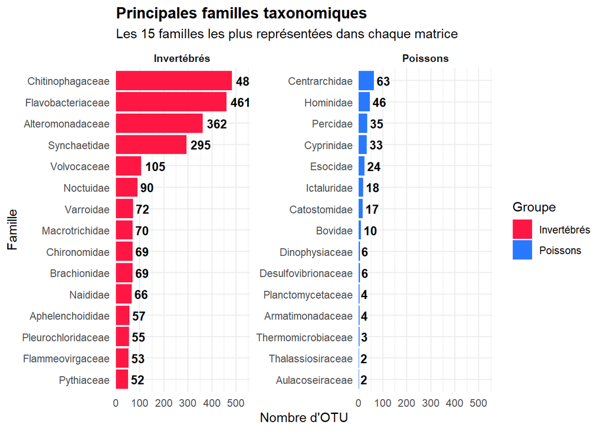

```r
# Graphique des 15 principales familles
graphique_familles <- ggplot(
  top15_familles,
  aes(
    x = reorder(Famille, Nombre_OTU),
    y = Nombre_OTU,
    fill = Groupe
  )
) +
  geom_col() +
  geom_text(
    aes(label = Nombre_OTU),
    hjust = -0.2,
    size = 3.5,
    fontface = "bold"
  ) +
  coord_flip() +
  facet_wrap(~ Groupe, scales = "free_y") +
  scale_fill_manual(
    values = c(
      "Invertébrés" = "#FF1744",
      "Poissons" = "#2979FF"
    )
  ) +
  scale_y_continuous(
    expand = expansion(mult = c(0, 0.15))
  ) +
  labs(
    title = "Principales familles taxonomiques",
    subtitle = "Les 15 familles les plus représentées dans chaque matrice",
    x = "Famille",
    y = "Nombre d'OTU"
  ) +
  theme_minimal() +
  theme(
    plot.title = element_text(face = "bold"),
    strip.text = element_text(face = "bold")
  )

print(graphique_familles)
```

```r
# ============================================================
# B. REPARTITION DES OTU PAR GENRE
# ============================================================

repartition_genres <- niveaux_taxonomiques_complets %>%
  dplyr::mutate(
    Genre = dplyr::if_else(
      is.na(Genre), "Non renseigné", Genre
    )
  ) %>%
  dplyr::group_by(Groupe, Genre) %>%
  dplyr::summarise(
    Nombre_OTU = dplyr::n(),
    .groups = "drop"
  ) %>%
  dplyr::group_by(Groupe) %>%
  dplyr::mutate(
    Pourcentage = round(
      Nombre_OTU / sum(Nombre_OTU) * 100, 2
    )
  ) %>%
  dplyr::ungroup()

# Sélection des 15 genres les plus représentés
top15_genres <- repartition_genres %>%
  dplyr::filter(Genre != "Non renseigné") %>%
  dplyr::group_by(Groupe) %>%
  dplyr::slice_max(
    order_by = Nombre_OTU,
    n = 15,
    with_ties = FALSE
  ) %>%
  dplyr::ungroup()

print(top15_genres)
```

```
## # A tibble: 30 × 4
##    Groupe      Genre           Nombre_OTU Pourcentage
##    <chr>       <chr>                <int>       <dbl>
##  1 Invertébrés Glaciecola             362        4.68
##  2 Invertébrés Filimonas              329        4.26
##  3 Invertébrés Polyarthra             272        3.52
##  4 Invertébrés Flavobacterium         237        3.07
##  5 Invertébrés Spodoptera              90        1.16
##  6 Invertébrés Gonium                  77        1
##  7 Invertébrés Varroa                  72        0.93
##  8 Invertébrés Macrothrix              70        0.91
##  9 Invertébrés Bursaphelenchus         57        0.74
## 10 Invertébrés Monodus                 55        0.71
## # ℹ 20 more rows
```

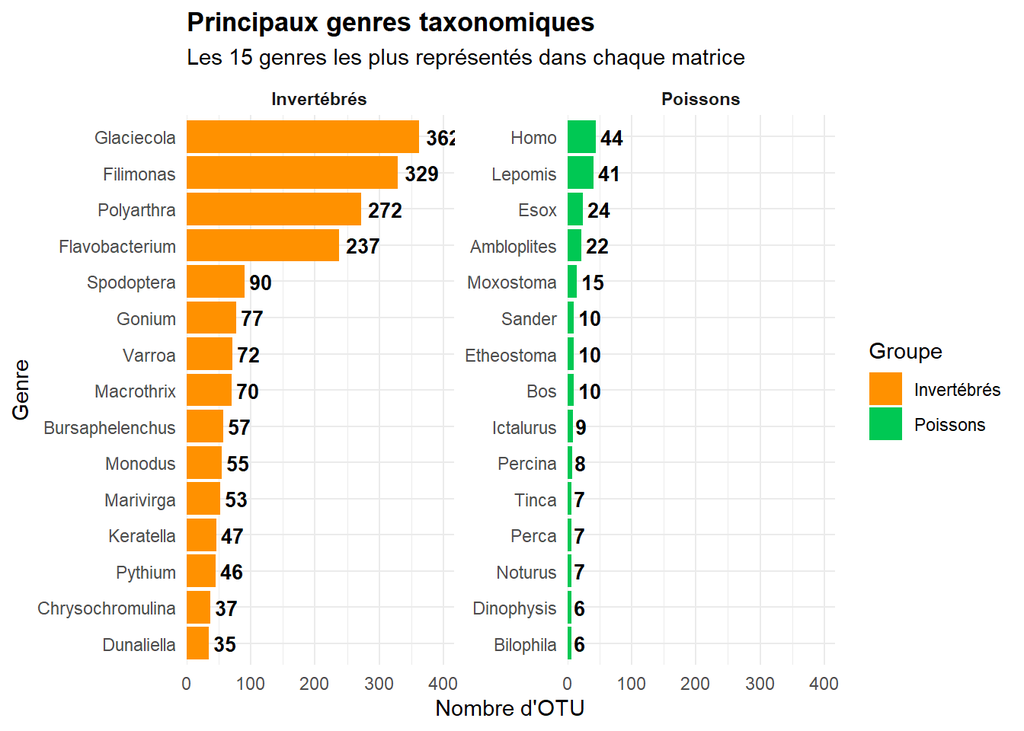

```r
# Graphique des 15 principaux genres
graphique_genres <- ggplot(
  top15_genres,
  aes(
    x = reorder(Genre, Nombre_OTU),
    y = Nombre_OTU,
    fill = Groupe
  )
) +
  geom_col() +
  geom_text(
    aes(label = Nombre_OTU),
    hjust = -0.2,
    size = 3.5,
    fontface = "bold"
  ) +
  coord_flip() +
  facet_wrap(~ Groupe, scales = "free_y") +
  scale_fill_manual(
    values = c(
      "Invertébrés" = "#FF9100",
      "Poissons" = "#00C853"
    )
  ) +
  scale_y_continuous(
    expand = expansion(mult = c(0, 0.15))
  ) +
  labs(
    title = "Principaux genres taxonomiques",
    subtitle = "Les 15 genres les plus représentés dans chaque matrice",
    x = "Genre",
    y = "Nombre d'OTU"
  ) +
  theme_minimal() +
  theme(
    plot.title = element_text(face = "bold"),
    strip.text = element_text(face = "bold")
  )

print(graphique_genres)
```

```r
# ============================================================
# C. SYNTHESE DU NIVEAU DE RESOLUTION TAXONOMIQUE
# ============================================================

synthese_familles_genres <- niveaux_taxonomiques_complets %>%
  dplyr::group_by(Groupe) %>%
  dplyr::summarise(
    Total_OTU = dplyr::n(),

    OTU_avec_famille = sum(!is.na(Famille)),
    Pourcentage_famille = round(
      sum(!is.na(Famille)) / dplyr::n() * 100, 2
    ),

    OTU_avec_genre = sum(!is.na(Genre)),
    Pourcentage_genre = round(
      sum(!is.na(Genre)) / dplyr::n() * 100, 2
    ),

    .groups = "drop"
  )

print(synthese_familles_genres)
```

```
## # A tibble: 2 × 6
##   Groupe      Total_OTU OTU_avec_famille Pourcentage_famille OTU_avec_genre
##   <chr>           <int>            <int>               <dbl>          <int>
## 1 Invertébrés      7727             3768                48.8           3427
## 2 Poissons          310              282                91.0            270
## # ℹ 1 more variable: Pourcentage_genre <dbl>
```

```r
print(top15_familles, n = 30)
```

```
## # A tibble: 30 × 4
##    Groupe      Famille             Nombre_OTU Pourcentage
##    <chr>       <chr>                    <int>       <dbl>
##  1 Invertébrés Chitinophagaceae           484        6.26
##  2 Invertébrés Flavobacteriaceae          461        5.97
##  3 Invertébrés Alteromonadaceae           362        4.68
##  4 Invertébrés Synchaetidae               295        3.82
##  5 Invertébrés Volvocaceae                105        1.36
##  6 Invertébrés Noctuidae                   90        1.16
##  7 Invertébrés Varroidae                   72        0.93
##  8 Invertébrés Macrotrichidae              70        0.91
##  9 Invertébrés Brachionidae                69        0.89
## 10 Invertébrés Chironomidae                69        0.89
## 11 Invertébrés Naididae                    66        0.85
## 12 Invertébrés Aphelenchoididae            57        0.74
```

[output cut: 18 more lines]

```r
print(top15_genres, n = 30)
```

```
## # A tibble: 30 × 4
##    Groupe      Genre            Nombre_OTU Pourcentage
##    <chr>       <chr>                 <int>       <dbl>
##  1 Invertébrés Glaciecola              362        4.68
##  2 Invertébrés Filimonas               329        4.26
##  3 Invertébrés Polyarthra              272        3.52
##  4 Invertébrés Flavobacterium          237        3.07
##  5 Invertébrés Spodoptera               90        1.16
##  6 Invertébrés Gonium                   77        1
##  7 Invertébrés Varroa                   72        0.93
##  8 Invertébrés Macrothrix               70        0.91
##  9 Invertébrés Bursaphelenchus          57        0.74
## 10 Invertébrés Monodus                  55        0.71
## 11 Invertébrés Marivirga                53        0.69
## 12 Invertébrés Keratella                47        0.61
```

[output cut: 18 more lines]

**Conclusion partielle - OS2**

Les analyses décrivent la richesse en OTU, les indices de diversité, la profondeur de séquençage, la distribution spatiale et la composition taxonomique. La richesse observée est en moyenne plus élevée dans la matrice des invertébrés (528,4 OTU par échantillon; médiane de 551) que dans celle des poissons (12,3; médiane de 11). Les indices de Shannon, Simpson et Pielou décrivent également des profils différents, mais ces valeurs ne doivent pas être interprétées comme une comparaison directe de la biodiversité entre les deux groupes, puisque les marqueurs et les protocoles analytiques diffèrent.

Les annotations taxonomiques montrent une composition diversifiée chez les invertébrés, tandis que les annotations de poissons sont majoritairement associées aux Chordata. Une part des OTU ne bénéficie pas d’une résolution taxonomique complète; les résultats doivent donc être présentés au niveau réellement atteint par l’annotation. Les cartes et résumés par site permettent de visualiser les détections, mais plusieurs sites ne disposent que d’un seul échantillon. Les tendances spatiales restent ainsi exploratoires et descriptives, et ne permettent pas à elles seules de conclure à des différences écologiques entre sites.

## 5.3 OS3 – Evaluer les signaux potentiels de contamination et les détections taxonomiques atypiques afin d’identifier les OTU nécessitant des vérifications complémentaires.

### 5.3.1 Contrôle des blancs et identification des annotations taxonomiques atypiques

L’analyse des contrôles négatifs et des annotations taxonomiques atypiques de la matrice des poissons a permis d’identifier 54 OTU assignées aux genres Homo et Bos, deux genres appartenant à la classe des Mammalia et non aux poissons.

Les résultats montrent des profils de détection différents selon les deux genres. Les OTU attribuées à Bos sont détectées uniquement dans certains échantillons biologiques, avec des quantités de lectures particulièrement élevées dans quelques prélèvements. Cette observation pourrait traduire une présence d’ADN de mammifère dans l’environnement échantillonné, mais une amplification non spécifique ou une erreur d’assignation taxonomique ne peuvent être exclues.

En revanche, les OTU attribuées à Homo présentent un profil plus préoccupant. Elles sont détectées dans plusieurs échantillons biologiques, mais également dans de nombreux blancs, notamment le blanc d’extraction, où **102 396 lectures ont été recensées.** Certaines autres préparations de blancs présentent également des nombres élevés de lectures. Cette distribution suggère un possible phénomène de contamination au cours du processus d’extraction ou de préparation des échantillons, susceptible d’affecter certains résultats biologiques.

Ces observations soulignent l’importance d’intégrer les contrôles négatifs dans le processus de validation des données de métabarcodage. Les OTU concernées ne doivent pas être supprimées automatiquement sur la seule base de leur annotation taxonomique. Une investigation complémentaire portant sur leur séquence, leur distribution entre les échantillons et les blancs ainsi que leur niveau de détection est nécessaire avant de décider de leur inclusion dans les analyses écologiques ultérieures.

```r
options(na.print = "NA")
getOption("na.print")
```

```
## [1] "NA"
```

```r
## 40. Contrôle des blancs et des annotations atypiques

# 40.1 Vérification des catégories d'échantillons

# Répartition des échantillons dans le mapping des invertébrés
catégories_invertebres <- mapping_invertebres %>%
  dplyr::count(TypeEchantillon, Treatment, name = "Effectif") %>%
  dplyr::arrange(dplyr::desc(Effectif))

print(tibble::as_tibble(catégories_invertebres), n = Inf)
```

```
## # A tibble: 53 × 3
##    TypeEchantillon  Treatment                                           Effectif
##    <chr>            <chr>                                                  <int>
##  1 Biologique       Ecole.Sainte-Martine_Riviere.Chateauguay_Parc.Paul…        2
##  2 Blanc            Ecole.Sainte-Martine_Riviere.Chateauguay_Parc.Paul…        2
##  3 Biologique       College.Charles-Lemoyne_Fleuve.St-Laurent.-.Canal.…        1
##  4 Biologique       College.Charles-Lemoyne_Fleuve.St-Laurent.-.Canal.…        1
##  5 Biologique       College.Charles-Lemoyne_Fleuve.St-Laurent.-.Canal.…        1
##  6 Biologique       College.Heritage_Riviere.Chateauguay_Descente.rue.…        1
##  7 Biologique       College.Heritage_Riviere.Chateauguay_Le.pont.du.Ch…        1
##  8 Biologique       College.Heritage_Riviere.Chateauguay_Parc.Marcel.S…        1
##  9 Biologique       College.Ville-Marie_Fleuve.St-Laurent_Vieux-Port,.…        1
## 10 Biologique       College.Ville-Marie_Fleuve.St-Laurent_Vieux-Port,.…        1
## 11 Biologique       College.Ville-Marie_Fleuve.St-Laurent_Vieux-port,.…        1
## 12 Biologique       Ecole.Secondaire.Andre-Laurendeau_Riviere.Richelie…        1
```

[output cut: 41 more lines]

```r
# Répartition des échantillons dans le mapping des poissons
catégories_poissons <- mapping_poissons %>%
  dplyr::count(TypeEchantillon, Treatment, name = "Effectif") %>%
  dplyr::arrange(dplyr::desc(Effectif))

print(tibble::as_tibble(catégories_poissons), n = Inf)
```

```
## # A tibble: 53 × 3
##    TypeEchantillon  Treatment                                           Effectif
##    <chr>            <chr>                                                  <int>
##  1 Biologique       Ecole.Sainte-Martine_Riviere.Chateauguay_Parc.Paul…        2
##  2 Blanc            Ecole.Sainte-Martine_Riviere.Chateauguay_Parc.Paul…        2
##  3 Biologique       College.Charles-Lemoyne_Fleuve.St-Laurent.-.Canal.…        1
##  4 Biologique       College.Charles-Lemoyne_Fleuve.St-Laurent.-.Canal.…        1
##  5 Biologique       College.Charles-Lemoyne_Fleuve.St-Laurent.-.Canal.…        1
##  6 Biologique       College.Heritage_Riviere.Chateauguay_Descente.rue.…        1
##  7 Biologique       College.Heritage_Riviere.Chateauguay_Le.pont.du.Ch…        1
##  8 Biologique       College.Heritage_Riviere.Chateauguay_Parc.Marcel.S…        1
##  9 Biologique       College.Ville-Marie_Fleuve.St-Laurent_Vieux-Port,.…        1
## 10 Biologique       College.Ville-Marie_Fleuve.St-Laurent_Vieux-Port,.…        1
## 11 Biologique       College.Ville-Marie_Fleuve.St-Laurent_Vieux-port,.…        1
## 12 Biologique       Ecole.Secondaire.Andre-Laurendeau_Riviere.Richelie…        1
```

[output cut: 41 more lines]

```r
# Vérification des échantillons réellement présents dans les matrices OTU
echantillons_invertebres <- setdiff(
  names(data_invertebres),
  c("#FEATURE_ID", "taxonomy")
)

echantillons_poissons <- setdiff(
  names(data_poissons),
  c("#FEATURE_ID", "taxonomy")
)

# Rattachement des échantillons présents dans les matrices aux mappings
mapping_invertebres_controle <- mapping_invertebres %>%
  dplyr::filter(SampleID %in% echantillons_invertebres)

mapping_poissons_controle <- mapping_poissons %>%
  dplyr::filter(SampleID %in% echantillons_poissons)

# Répartition des échantillons effectivement présents dans les matrices
cat("\n--- Invertébrés : échantillons présents dans la matrice ---\n")
```

```
##
## --- Invertébrés : échantillons présents dans la matrice ---
```

```r
print(
  tibble::as_tibble(
    mapping_invertebres_controle %>%
      dplyr::count(TypeEchantillon, Treatment, name = "Effectif")
  ),
  n = Inf
)
```

```
## # A tibble: 51 × 3
##    TypeEchantillon  Treatment                                           Effectif
##    <chr>            <chr>                                                  <int>
##  1 Biologique       College.Charles-Lemoyne_Fleuve.St-Laurent.-.Canal.…        1
##  2 Biologique       College.Charles-Lemoyne_Fleuve.St-Laurent.-.Canal.…        1
##  3 Biologique       College.Charles-Lemoyne_Fleuve.St-Laurent.-.Canal.…        1
##  4 Biologique       College.Heritage_Riviere.Chateauguay_Descente.rue.…        1
##  5 Biologique       College.Heritage_Riviere.Chateauguay_Le.pont.du.Ch…        1
##  6 Biologique       College.Heritage_Riviere.Chateauguay_Parc.Marcel.S…        1
##  7 Biologique       College.Ville-Marie_Fleuve.St-Laurent_Vieux-Port,.…        1
##  8 Biologique       College.Ville-Marie_Fleuve.St-Laurent_Vieux-Port,.…        1
##  9 Biologique       College.Ville-Marie_Fleuve.St-Laurent_Vieux-port,.…        1
## 10 Biologique       Ecole.Sainte-Martine_Riviere.Chateauguay_Parc.Paul…        2
## 11 Biologique       Ecole.Secondaire.Andre-Laurendeau_Riviere.Richelie…        1
## 12 Biologique       Ecole.polyvalente.Lavigne_Riviere.des.Outaouais_Am…        1
```

[output cut: 39 more lines]

```r
cat("\n--- Poissons : échantillons présents dans la matrice ---\n")
```

```
##
## --- Poissons : échantillons présents dans la matrice ---
```

```r
print(
  tibble::as_tibble(
    mapping_poissons_controle %>%
      dplyr::count(TypeEchantillon, Treatment, name = "Effectif")
  ),
  n = Inf
)
```

```
## # A tibble: 41 × 3
##    TypeEchantillon  Treatment                                           Effectif
##    <chr>            <chr>                                                  <int>
##  1 Biologique       College.Charles-Lemoyne_Fleuve.St-Laurent.-.Canal.…        1
##  2 Biologique       College.Charles-Lemoyne_Fleuve.St-Laurent.-.Canal.…        1
##  3 Biologique       College.Charles-Lemoyne_Fleuve.St-Laurent.-.Canal.…        1
##  4 Biologique       College.Heritage_Riviere.Chateauguay_Descente.rue.…        1
##  5 Biologique       College.Heritage_Riviere.Chateauguay_Le.pont.du.Ch…        1
##  6 Biologique       College.Heritage_Riviere.Chateauguay_Parc.Marcel.S…        1
##  7 Biologique       College.Ville-Marie_Fleuve.St-Laurent_Vieux-Port,.…        1
##  8 Biologique       College.Ville-Marie_Fleuve.St-Laurent_Vieux-Port,.…        1
##  9 Biologique       College.Ville-Marie_Fleuve.St-Laurent_Vieux-port,.…        1
## 10 Biologique       Ecole.Sainte-Martine_Riviere.Chateauguay_Parc.Paul…        1
## 11 Biologique       Ecole.Secondaire.Andre-Laurendeau_Riviere.Richelie…        1
## 12 Biologique       Ecole.polyvalente.Lavigne_Riviere.des.Outaouais_Am…        1
```

[output cut: 29 more lines]

```r
# 40.2 Identification des annotations atypiques chez les poissons

# Extraction des OTU annotées comme Homo ou Bos
otu_atypiques_poissons <- niveaux_poissons %>%
  dplyr::filter(
    grepl("Homo|Bos", paste(Famille, Genre), ignore.case = TRUE)
  )

cat("\n--- OTU présentant des annotations Homo ou Bos ---\n")
```

```
##
## --- OTU présentant des annotations Homo ou Bos ---
```

```r
print(
  tibble::as_tibble(otu_atypiques_poissons),
  n = Inf
)
```

```
## # A tibble: 54 × 9
##    OTU   Groupe   Regne     Embranchement Classe   Ordre    Famille Genre Espece
##    <chr> <chr>    <chr>     <chr>         <chr>    <chr>    <chr>   <chr> <chr>
##  1 1     Poissons Eukaryota Chordata      Mammalia Primates Homini… Homo  <NA>
##  2 21    Poissons Eukaryota Chordata      Mammalia Artioda… Bovidae Bos   <NA>
##  3 33    Poissons Eukaryota Chordata      Mammalia Artioda… Bovidae Bos   <NA>
##  4 38    Poissons Eukaryota Chordata      Mammalia Primates Homini… Homo  <NA>
##  5 39    Poissons Eukaryota Chordata      Mammalia Primates Homini… Homo  <NA>
##  6 41    Poissons Eukaryota Chordata      Mammalia Primates Homini… Homo  <NA>
##  7 51    Poissons Eukaryota Chordata      Mammalia Primates Homini… Homo  <NA>
##  8 56    Poissons Eukaryota Chordata      Mammalia Primates Homini… Homo  <NA>
##  9 57    Poissons Eukaryota Chordata      Mammalia Artioda… Bovidae Bos   <NA>
## 10 58    Poissons Eukaryota Chordata      Mammalia Primates Homini… Homo  <NA>
## 11 63    Poissons Eukaryota Chordata      Mammalia Primates Homini… Homo  <NA>
## 12 65    Poissons Eukaryota Chordata      Mammalia Primates Homini… Homo  <NA>
```

[output cut: 42 more lines]

```r
# Extraction des OTU correspondantes dans la matrice des poissons
# Harmonisation du type des identifiants avant le filtrage
matrice_otu_atypiques <- data_poissons %>%
  dplyr::mutate(`#FEATURE_ID` = as.character(`#FEATURE_ID`)) %>%
  dplyr::filter(
    `#FEATURE_ID` %in% as.character(otu_atypiques_poissons$OTU)
  )


# Transformation de la matrice en format long
lectures_otu_atypiques <- matrice_otu_atypiques %>%
  tidyr::pivot_longer(
    cols = -c(`#FEATURE_ID`, taxonomy),
    names_to = "SampleID",
    values_to = "Nombre_lectures"
  ) %>%
  dplyr::mutate(`#FEATURE_ID` = as.character(`#FEATURE_ID`)) %>%

  # Ajout des informations sur les échantillons
  dplyr::left_join(
    mapping_poissons %>%
      dplyr::select(SampleID, TypeEchantillon, Treatment),
    by = "SampleID"
  ) %>%

  # Ajout des annotations taxonomiques
  dplyr::left_join(
    otu_atypiques_poissons %>%
      dplyr::mutate(OTU = as.character(OTU)) %>%
      dplyr::select(OTU, Famille, Genre),
    by = c("#FEATURE_ID" = "OTU")
  )


# 40.3 Identification des détections positives

detections_otu_atypiques <- lectures_otu_atypiques %>%
  dplyr::filter(Nombre_lectures > 0) %>%
  dplyr::arrange(Genre, dplyr::desc(Nombre_lectures))

cat("\n--- Détections positives des OTU atypiques ---\n")
```

```
##
## --- Détections positives des OTU atypiques ---
```

```r
print(
  tibble::as_tibble(detections_otu_atypiques),
  n = Inf
)
```

```
## # A tibble: 80 × 8
##    `#FEATURE_ID` taxonomy     SampleID Nombre_lectures TypeEchantillon Treatment
##    <chr>         <chr>        <chr>              <dbl> <chr>           <chr>
##  1 21            k__Eukaryot… MI.M058…           62040 Biologique      Ecole.se…
##  2 33            k__Eukaryot… MI.M058…           22788 Biologique      Ecole.se…
##  3 57            k__Eukaryot… MI.M058…            2048 Biologique      Ecole.se…
##  4 121           k__Eukaryot… MI.M058…             645 Biologique      Ecole.se…
##  5 143           k__Eukaryot… MI.M058…             513 Biologique      Ecole.se…
##  6 247           k__Eukaryot… MI.M058…             110 Biologique      College.…
##  7 282           k__Eukaryot… MI.M058…              34 Biologique      Ecole.se…
##  8 300           k__Eukaryot… MI.M058…              10 Biologique      Ecole.se…
##  9 301           k__Eukaryot… MI.M058…               9 Biologique      Ecole.Se…
## 10 304           k__Eukaryot… MI.M058…               8 Biologique      Ecole.se…
## 11 1             k__Eukaryot… MI.M058…           95848 Blanc.Extracti… Blanc.Ex…
## 12 1             k__Eukaryot… MI.M058…           71803 Blanc           Ecole.se…
```

[output cut: 69 more lines]

```r
# 40.4 Synthèse des détections selon le type d'échantillon

synthese_otu_atypiques <- lectures_otu_atypiques %>%
  dplyr::group_by(Genre, TypeEchantillon, Treatment) %>%
  dplyr::summarise(
    Nombre_OTU_detectes = dplyr::n_distinct(
      `#FEATURE_ID`[Nombre_lectures > 0]
    ),
    Total_lectures = sum(Nombre_lectures, na.rm = TRUE),
    .groups = "drop"
  ) %>%
  dplyr::arrange(Genre, TypeEchantillon)

cat("\n--- Synthèse des OTU atypiques par type d'échantillon ---\n")
```

```
##
## --- Synthèse des OTU atypiques par type d'échantillon ---
```

```r
print(
  tibble::as_tibble(synthese_otu_atypiques),
  n = Inf
)
```

```
## # A tibble: 82 × 5
##    Genre TypeEchantillon  Treatment           Nombre_OTU_detectes Total_lectures
##    <chr> <chr>            <chr>                             <int>          <dbl>
##  1 Bos   Biologique       College.Charles-Le…                   0              0
##  2 Bos   Biologique       College.Charles-Le…                   0              0
##  3 Bos   Biologique       College.Charles-Le…                   0              0
##  4 Bos   Biologique       College.Heritage_R…                   0              0
##  5 Bos   Biologique       College.Heritage_R…                   0              0
##  6 Bos   Biologique       College.Heritage_R…                   1            110
##  7 Bos   Biologique       College.Ville-Mari…                   0              0
##  8 Bos   Biologique       College.Ville-Mari…                   0              0
##  9 Bos   Biologique       College.Ville-Mari…                   0              0
## 10 Bos   Biologique       Ecole.Sainte-Marti…                   0              0
## 11 Bos   Biologique       Ecole.Secondaire.A…                   1              9
## 12 Bos   Biologique       Ecole.polyvalente.…                   0              0
```

[output cut: 70 more lines]

### 5.3.2 Dépistage global des OTU potentiellement contaminantes

**Analyse des blancs et dépistage des OTU potentiellement contaminantes**

L’analyse des blancs a permis d’évaluer la présence d’OTU dans les échantillons de contrôle et de comparer leur distribution à celle observée dans les échantillons biologiques.

Chez les poissons, sur les **310 OTU recensées, 255 ont été détectées uniquement dans les échantillons biologiques. En revanche, 42 OTU étaient présentes uniquement dans les blancs, 9 uniquement dans le blanc d’extraction, et 4 étaient également détectées dans les échantillons biologiques et dans les contrôles.** La détection de plusieurs OTU annotées comme **Mammalia dans les blancs, notamment dans le blanc d’extraction**, constitue un signal particulièrement préoccupant. L’**OTU 1 présente notamment 95 848 lectures dans le blanc d’extraction,** contre **3 449 dans les échantillons biologiques.**

Dans l’ensemble, les résultats révèlent des profils de détection différents entre les deux groupes, avec une proportion plus importante d’OTU détectées dans les blancs chez les poissons. Ces observations suggèrent la possibilité de contaminations ou d’amplifications non spécifiques, mais ne permettent pas d’en confirmer définitivement l’origine.

Une vérification complémentaire des séquences, des annotations taxonomiques et de la distribution des lectures dans les échantillons est donc nécessaire avant toute décision de filtrage. Les OTU détectées uniquement dans les blancs et celles présentant un signal élevé dans les contrôles seront examinées en priorité. Aucune suppression systématique ne sera effectuée sur la seule base de leur présence dans un blanc.

```r
## 41. Dépistage global des OTU potentiellement contaminantes

# 41.1 Classification des échantillons

# Cette fonction distingue les échantillons biologiques,
# les blancs et les blancs d'extraction à partir des colonnes
# TypeEchantillon et Treatment.

classifier_echantillons <- function(mapping) {

  mapping %>%
    dplyr::mutate(
      Texte_controle = tolower(
        paste(TypeEchantillon, Treatment)
      ),
      Classe = dplyr::case_when(
        grepl("extraction|extract", Texte_controle) ~
          "Blanc_extraction",

        grepl(
          "blanc|blank|negative|négatif|ntc",
          Texte_controle
        ) ~ "Blanc",

        TRUE ~ "Biologique"
      )
    )
}

mapping_invertebres_41 <- classifier_echantillons(mapping_invertebres)
mapping_poissons_41 <- classifier_echantillons(mapping_poissons)

cat("\n--- Répartition des échantillons : invertébrés ---\n")
```

```
##
## --- Répartition des échantillons : invertébrés ---
```

```r
print(
  mapping_invertebres_41 %>%
    dplyr::count(Classe, name = "Nombre_echantillons")
)
```

```
## # A tibble: 3 × 2
##   Classe           Nombre_echantillons
##   <chr>                          <int>
## 1 Biologique                        27
## 2 Blanc                             27
## 3 Blanc_extraction                   1
```

```r
cat("\n--- Répartition des échantillons : poissons ---\n")
```

```
##
## --- Répartition des échantillons : poissons ---
```

```r
print(
  mapping_poissons_41 %>%
    dplyr::count(Classe, name = "Nombre_echantillons")
)
```

```
## # A tibble: 3 × 2
##   Classe           Nombre_echantillons
##   <chr>                          <int>
## 1 Biologique                        27
## 2 Blanc                             27
## 3 Blanc_extraction                   1
```

```r
# 41.2 Fonction d'analyse globale des OTU

analyser_blancs_otu <- function(matrice, mapping, groupe) {

  # Identification des colonnes correspondant aux échantillons
  colonnes_echantillons <- setdiff(
    names(matrice),
    c("#FEATURE_ID", "taxonomy")
  )

  # Passage au format long
  donnees_longues <- matrice %>%
    dplyr::mutate(
      OTU = as.character(`#FEATURE_ID`)
    ) %>%
    tidyr::pivot_longer(
      cols = dplyr::all_of(colonnes_echantillons),
      names_to = "SampleID",
      values_to = "Nombre_lectures"
    ) %>%
    dplyr::mutate(
      Nombre_lectures = as.numeric(Nombre_lectures)
    ) %>%
    dplyr::left_join(
      mapping %>%
        dplyr::select(SampleID, Classe),
      by = "SampleID"
    ) %>%
    dplyr::mutate(
      Classe = factor(
        Classe,
        levels = c(
          "Biologique",
          "Blanc",
          "Blanc_extraction"
        )
      )
    )

  # Vérification des correspondances
  cat("\n--- Vérification des échantillons :", groupe, "---\n")
  cat(
    "Échantillons sans catégorie :",
    sum(is.na(donnees_longues$Classe)),
    "\n"
  )

  # Nombre total d'échantillons dans chaque catégorie
  effectifs_classes <- mapping %>%
    dplyr::count(Classe, name = "N_total") %>%
    tidyr::complete(
      Classe = c(
        "Biologique",
        "Blanc",
        "Blanc_extraction"
      ),
      fill = list(N_total = 0)
    )

  # Calcul des indicateurs pour chaque OTU et chaque catégorie
  bilan <- donnees_longues %>%
    dplyr::filter(!is.na(Classe)) %>%
    dplyr::group_by(OTU, taxonomy, Classe) %>%
    dplyr::summarise(
      N_echantillons_positifs = dplyr::n_distinct(
        SampleID[Nombre_lectures > 0]
      ),
      Total_lectures = sum(Nombre_lectures, na.rm = TRUE),
      .groups = "drop"
    ) %>%
    tidyr::pivot_wider(
      names_from = Classe,
      values_from = c(
        N_echantillons_positifs,
        Total_lectures
      ),
      names_glue = "{.value}_{Classe}",
      values_fill = 0,
      names_expand = TRUE
    )

  # Ajout des effectifs de chaque catégorie
  effectifs_wide <- effectifs_classes %>%
    tidyr::pivot_wider(
      names_from = Classe,
      values_from = N_total,
      names_prefix = "N_total_",
      values_fill = 0
    )

  bilan <- bilan %>%
    dplyr::mutate(
      Groupe = groupe
    ) %>%
    dplyr::cross_join(effectifs_wide) %>%
    dplyr::mutate(
      Prevalence_biologique = dplyr::if_else(
        N_total_Biologique > 0,
        100 * N_echantillons_positifs_Biologique /
          N_total_Biologique,
        NA_real_
      ),
      Prevalence_blancs = dplyr::if_else(
        N_total_Blanc > 0,
        100 * N_echantillons_positifs_Blanc /
          N_total_Blanc,
        NA_real_
      ),
      Prevalence_blanc_extraction = dplyr::if_else(
        N_total_Blanc_extraction > 0,
        100 * N_echantillons_positifs_Blanc_extraction /
          N_total_Blanc_extraction,
        NA_real_
      )
    ) %>%
    dplyr::mutate(
      Detection_blanc = Total_lectures_Blanc > 0,
      Detection_blanc_extraction =
        Total_lectures_Blanc_extraction > 0,

      Detection_biologique =
        Total_lectures_Biologique > 0,

      Profil_detection = dplyr::case_when(
        Detection_blanc_extraction &
          Detection_biologique ~
          "Biologique et blanc d'extraction",

        Detection_blanc_extraction ~
          "Blanc d'extraction uniquement",

        Detection_blanc &
          Detection_biologique ~
          "Biologique et blancs",

        Detection_blanc ~
          "Blancs uniquement",

        Detection_biologique ~
          "Biologique uniquement",

        TRUE ~ "Aucune détection"
      )
    )

  return(
    list(
      donnees_longues = donnees_longues,
      bilan = bilan
    )
  )
}


# 41.3 Analyse des invertébrés

analyse_blancs_invertebres <- analyser_blancs_otu(
  matrice = data_invertebres,
  mapping = mapping_invertebres_41,
  groupe = "Invertébrés"
)
```

```
##
## --- Vérification des échantillons : Invertébrés ---
## Échantillons sans catégorie : 0
```

```r
bilan_blancs_invertebres <- analyse_blancs_invertebres$bilan


# 41.4 Analyse des poissons

analyse_blancs_poissons <- analyser_blancs_otu(
  matrice = data_poissons,
  mapping = mapping_poissons_41,
  groupe = "Poissons"
)
```

```
##
## --- Vérification des échantillons : Poissons ---
## Échantillons sans catégorie : 0
```

```r
bilan_blancs_poissons <- analyse_blancs_poissons$bilan


# 41.5 Synthèse générale des deux groupes

bilan_global_blancs <- dplyr::bind_rows(
  bilan_blancs_invertebres,
  bilan_blancs_poissons
)

cat("\n--- Synthèse des profils de détection ---\n")
```

```
##
## --- Synthèse des profils de détection ---
```

```r
synthese_profils_blancs <- bilan_global_blancs %>%
  dplyr::count(
    Groupe,
    Profil_detection,
    name = "Nombre_OTU"
  ) %>%
  dplyr::arrange(Groupe, dplyr::desc(Nombre_OTU))

print(
  tibble::as_tibble(synthese_profils_blancs),
  n = Inf
)
```

```
## # A tibble: 10 × 3
##    Groupe      Profil_detection                 Nombre_OTU
##    <chr>       <chr>                                 <int>
##  1 Invertébrés Biologique uniquement                  7666
##  2 Invertébrés Biologique et blancs                     29
##  3 Invertébrés Blancs uniquement                        29
##  4 Invertébrés Blanc d'extraction uniquement             2
##  5 Invertébrés Biologique et blanc d'extraction          1
##  6 Poissons    Biologique uniquement                   255
##  7 Poissons    Blancs uniquement                        42
##  8 Poissons    Blanc d'extraction uniquement             9
##  9 Poissons    Biologique et blancs                      3
## 10 Poissons    Biologique et blanc d'extraction          1
```

```r
# 41.6 Nombre d'OTU détectées dans les blancs

synthese_detection_blancs <- bilan_global_blancs %>%
  dplyr::group_by(Groupe) %>%
  dplyr::summarise(
    Nombre_OTU_total = dplyr::n(),

    OTU_dans_biologiques = sum(
      Detection_biologique
    ),

    OTU_dans_blancs = sum(
      Detection_blanc
    ),

    OTU_dans_blancs_extraction = sum(
      Detection_blanc_extraction
    ),

    OTU_uniquement_dans_blancs = sum(
      Profil_detection %in% c(
        "Blancs uniquement",
        "Blanc d'extraction uniquement"
      )
    ),

    .groups = "drop"
  )

cat("\n--- Bilan général des détections ---\n")
```

```
##
## --- Bilan général des détections ---
```

```r
print(
  tibble::as_tibble(synthese_detection_blancs),
  n = Inf
)
```

```
## # A tibble: 2 × 6
##   Groupe      Nombre_OTU_total OTU_dans_biologiques OTU_dans_blancs
##   <chr>                  <int>                <int>           <int>
## 1 Invertébrés             7727                 7696              59
## 2 Poissons                 310                  259              47
## # ℹ 2 more variables: OTU_dans_blancs_extraction <int>,
## #   OTU_uniquement_dans_blancs <int>
```

```r
# 41.7 Identification des OTU prioritaires à vérifier

otu_a_verifier <- bilan_global_blancs %>%
  dplyr::filter(
    Detection_blanc |
      Detection_blanc_extraction
  ) %>%
  dplyr::mutate(
    Rapport_lectures_blancs_biologiques =
      dplyr::if_else(
        Total_lectures_Biologique > 0,
        (
          Total_lectures_Blanc +
            Total_lectures_Blanc_extraction
        ) / Total_lectures_Biologique,
        NA_real_
      )
  ) %>%
  dplyr::arrange(
    Groupe,
    dplyr::desc(Detection_blanc_extraction),
    dplyr::desc(Total_lectures_Blanc_extraction),
    dplyr::desc(Total_lectures_Blanc)
  )

cat("\n--- OTU détectées dans au moins un blanc ---\n")
```

```
##
## --- OTU détectées dans au moins un blanc ---
```

```r
print(
  tibble::as_tibble(
    otu_a_verifier %>%
      dplyr::select(
        Groupe,
        OTU,
        taxonomy,
        Profil_detection,
        N_echantillons_positifs_Biologique,
        N_echantillons_positifs_Blanc,
        N_echantillons_positifs_Blanc_extraction,
        Total_lectures_Biologique,
        Total_lectures_Blanc,
        Total_lectures_Blanc_extraction,
        Prevalence_biologique,
        Prevalence_blancs,
        Prevalence_blanc_extraction,
        Rapport_lectures_blancs_biologiques
      )
  ),
  n = 50
)
```

```
## # A tibble: 116 × 14
##    Groupe      OTU   taxonomy            Profil_detection N_echantillons_posit…¹
##    <chr>       <chr> <chr>               <chr>                             <int>
##  1 Invertébrés 22    k__Eukaryota;p__Ch… Biologique et b…                      7
##  2 Invertébrés 604   k__Eukaryota;p__Ch… Blanc d'extract…                      0
##  3 Invertébrés 2741  k__Eukaryota;p__Ch… Blanc d'extract…                      0
##  4 Invertébrés 7     k__Bacteria;p__Pro… Blancs uniqueme…                      0
##  5 Invertébrés 623   k__Eukaryota;       Blancs uniqueme…                      0
##  6 Invertébrés 627   k__Bacteria;p__Bac… Blancs uniqueme…                      0
##  7 Invertébrés 1179  k__Bacteria;p__Pro… Blancs uniqueme…                      0
##  8 Invertébrés 710   k__Eukaryota;p__Oc… Biologique et b…                      4
##  9 Invertébrés 1292  k__Eukaryota;p__Ch… Blancs uniqueme…                      0
## 10 Invertébrés 1406  k__Eukaryota;p__Ch… Blancs uniqueme…                      0
## 11 Invertébrés 1559  k__Bacteria;p__Pro… Blancs uniqueme…                      0
## 12 Invertébrés 1660  k__Eukaryota;p__As… Blancs uniqueme…                      0
```

[output cut: 45 more lines]

```r
# 41.8 OTU détectées dans les blancs d'extraction

otu_blancs_extraction <- bilan_global_blancs %>%
  dplyr::filter(Detection_blanc_extraction) %>%
  dplyr::arrange(
    Groupe,
    dplyr::desc(Total_lectures_Blanc_extraction)
  )

cat("\n--- OTU détectées dans les blancs d'extraction ---\n")
```

```
##
## --- OTU détectées dans les blancs d'extraction ---
```

```r
print(
  tibble::as_tibble(
    otu_blancs_extraction %>%
      dplyr::select(
        Groupe,
        OTU,
        taxonomy,
        N_echantillons_positifs_Biologique,
        Total_lectures_Biologique,
        Total_lectures_Blanc_extraction,
        Prevalence_biologique,
        Prevalence_blanc_extraction
      )
  ),
  n = Inf
)
```

```
## # A tibble: 13 × 8
##    Groupe      OTU   taxonomy      N_echantillons_posit…¹ Total_lectures_Biolo…²
##    <chr>       <chr> <chr>                          <int>                  <dbl>
##  1 Invertébrés 22    k__Eukaryota…                      7                   2755
##  2 Invertébrés 604   k__Eukaryota…                      0                      0
##  3 Invertébrés 2741  k__Eukaryota…                      0                      0
##  4 Poissons    1     k__Eukaryota…                      6                   3449
##  5 Poissons    56    k__Eukaryota…                      0                      0
##  6 Poissons    77    k__Eukaryota…                      0                      0
##  7 Poissons    41    k__Eukaryota…                      0                      0
##  8 Poissons    95    k__Eukaryota…                      0                      0
##  9 Poissons    124   k__Eukaryota…                      0                      0
## 10 Poissons    132   k__Eukaryota…                      0                      0
## 11 Poissons    229   k__Eukaryota…                      0                      0
## 12 Poissons    274   k__Eukaryota…                      0                      0
## 13 Poissons    306   k__Eukaryota…                      0                      0
## # ℹ abbreviated names: ¹N_echantillons_positifs_Biologique,
## #   ²Total_lectures_Biologique
## # ℹ 3 more variables: Total_lectures_Blanc_extraction <dbl>,
## #   Prevalence_biologique <dbl>, Prevalence_blanc_extraction <dbl>
```

```r
# 41.9 OTU présentes uniquement dans les blancs

otu_uniquement_blancs <- bilan_global_blancs %>%
  dplyr::filter(
    Profil_detection %in% c(
      "Blancs uniquement",
      "Blanc d'extraction uniquement"
    )
  ) %>%
  dplyr::arrange(
    Groupe,
    dplyr::desc(
      Total_lectures_Blanc +
        Total_lectures_Blanc_extraction
    )
  )

cat("\n--- OTU détectées uniquement dans les blancs ---\n")
```

```
##
## --- OTU détectées uniquement dans les blancs ---
```

```r
print(
  tibble::as_tibble(
    otu_uniquement_blancs %>%
      dplyr::select(
        Groupe,
        OTU,
        taxonomy,
        Profil_detection,
        Total_lectures_Blanc,
        Total_lectures_Blanc_extraction
      )
  ),
  n = 50
)
```

```
## # A tibble: 82 × 6
##    Groupe      OTU   taxonomy              Profil_detection Total_lectures_Blanc
##    <chr>       <chr> <chr>                 <chr>                           <dbl>
##  1 Invertébrés 7     k__Bacteria;p__Prote… Blancs uniqueme…                71803
##  2 Invertébrés 604   k__Eukaryota;p__Chor… Blanc d'extract…                    0
##  3 Invertébrés 623   k__Eukaryota;         Blancs uniqueme…                  856
##  4 Invertébrés 627   k__Bacteria;p__Bacte… Blancs uniqueme…                  852
##  5 Invertébrés 1179  k__Bacteria;p__Prote… Blancs uniqueme…                  394
##  6 Invertébrés 1292  k__Eukaryota;p__Chor… Blancs uniqueme…                  345
##  7 Invertébrés 1406  k__Eukaryota;p__Chor… Blancs uniqueme…                  311
##  8 Invertébrés 1559  k__Bacteria;p__Prote… Blancs uniqueme…                  270
##  9 Invertébrés 1660  k__Eukaryota;p__Asco… Blancs uniqueme…                  247
## 10 Invertébrés 1838  k__Bacteria;p__Prote… Blancs uniqueme…                  212
## 11 Invertébrés 1945  k__Eukaryota;p__Chor… Blancs uniqueme…                  192
## 12 Invertébrés 2003  k__Bacteria;p__Prote… Blancs uniqueme…                  185
```

[output cut: 40 more lines]

**Interprétation des résultats de l’analyse des contrôles (blancs)**

Ces résultats permettent d’évaluer la présence éventuelle de contaminations dans les échantillons d’ADN environnemental (ADNe), en comparant les détections obtenues dans les échantillons biologiques avec celles observées dans les blancs de terrain et le blanc d’extraction.

L’analyse porte sur les OTU détectées dans les contrôles et permet de distinguer trois situations : les OTU présentes uniquement dans les échantillons biologiques, celles détectées à la fois dans les échantillons biologiques et les contrôles, et celles retrouvées exclusivement dans les contrôles. - **Effectifs réellement analysés** Les effectifs pris en compte dans l’analyse sont les suivants : Type d’échantillon Invertébrés Poissons Échantillons biologiques 27 26 Blancs de terrain 25 14 Blancs d’extraction 1 1 Total 53 41

Les effectifs montrent que les deux groupes ne disposent pas du même nombre de contrôles. L’analyse des invertébrés comprend 25 blancs de terrain, contre seulement 14 pour les poissons. Dans les deux cas, un seul blanc d’extraction est disponible.

Cette différence doit être prise en compte dans l’interprétation : les probabilités de détecter une OTU dans les blancs ne sont pas directement comparables entre les deux groupes. Les prévalences ont néanmoins été calculées à partir des effectifs réellement présents dans les matrices, ce qui évite de sous-estimer ou de surestimer artificiellement les fréquences de détection. - **Prévalences corrigées** des OTU détectées dans les contrôles Au total, 116 OTU ont été identifiées comme nécessitant une vérification en raison de leur présence dans au moins un contrôle : - 61 OTU pour les invertébrés ; - 55 OTU pour les poissons. Les prévalences biologiques indiquent la proportion d’échantillons biologiques dans lesquels chaque OTU a été détectée. - **Invertébrés** Sur les 61 OTU détectées dans au moins un contrôle : - 30 sont également présentes dans les échantillons biologiques ; - 31 sont présentes uniquement dans les contrôles ; - 3 ont été détectées dans le blanc d’extraction. La présence d’une OTU dans un contrôle ne signifie donc pas systématiquement qu’elle est contaminante. Certaines OTU sont également détectées dans plusieurs échantillons biologiques.

Par exemple, l’**OTU 22 est détectée dans 7 des 27 échantillons biologiques**, soit une prévalence de 25,9 %. Toutefois, elle est également présente dans plusieurs blancs de terrain et dans le blanc d’extraction. Elle présente ainsi un profil qui mérite une attention particulière : sa détection dans les échantillons biologiques pourrait correspondre à un signal environnemental réel, mais une contribution liée à une contamination est également possible.

À l’inverse, les **OTU 604 et 2741 sont détectées uniquement dans le blanc d’extraction**, avec respectivement **902 et 111 lectures**. Elles ne sont retrouvées dans aucun des **27 échantillons biologiques.** Leur profil est donc plus compatible avec une contamination introduite au cours des étapes d’extraction ou de préparation des échantillons.

L’OTU 7 mérite également une attention particulière : elle présente **71 803 lectures** dans un blanc de terrain, sans détection dans les échantillons biologiques. Une telle quantité de lectures dans un contrôle justifie une vérification approfondie de son origine. - **Poissons** Pour les poissons, 55 OTU ont été détectées dans au moins un contrôle : - 4 sont également présentes dans les échantillons biologiques ; - 51 sont présentes uniquement dans les contrôles ; - 10 ont été détectées dans le blanc d’extraction. Cette situation est particulièrement préoccupante, puisque la grande majorité des OTU détectées dans les contrôles ne sont pas retrouvées dans les échantillons biologiques.

L’**OTU 1 constitue le cas le plus remarquable**. Elle est détectée dans 6 échantillons biologiques sur 26, soit une prévalence de 23,1 %, avec un maximum de 3 013 lectures dans un échantillon biologique. Cependant, elle est également détectée dans plusieurs blancs de terrain, avec des valeurs très élevées, notamment 71 803 et 67 626 lectures, ainsi que dans le blanc d’extraction avec 95 848 lectures.

La présence de cette OTU dans les différents types de contrôles, associée à un nombre très important de lectures dans le blanc d’extraction, constitue un indice fort d’une possible contamination. Il est donc nécessaire de vérifier si les détections observées dans les échantillons biologiques correspondent à un signal environnemental ou à une contamination croisée.

Les OTU 56, 77, 95, 124, 132, 229 et 274 sont également détectées uniquement dans le blanc d’extraction. Leurs nombres de lectures varient de 53 à 2 068. Leur absence dans les échantillons biologiques renforce leur caractère suspect.

Enfin, l’OTU 41 est détectée dans quatre blancs de terrain et dans le blanc d’extraction, mais dans aucun échantillon biologique. Ce profil suggère également une possible contamination. 3. OTU présentes uniquement dans les contrôles L’analyse identifie au total 82 OTU exclusivement détectées dans les contrôles : 31 Invertébrés

OTU uniquement dans les contrôles

51 Poissons

OTU uniquement dans les contrôles

82 Total des OTU exclusivement détectées dans les contrôles

Ces OTU représentent des candidats à examiner avant toute analyse écologique ultérieure. Chez les invertébrés La majorité des OTU exclusivement détectées dans les contrôles sont retrouvées dans les blancs de terrain. Certaines présentent de faibles nombres de lectures, tandis que d’autres montrent des valeurs plus importantes.

L’OTU 7 se distingue particulièrement avec 71 803 lectures dans un blanc de terrain. L’OTU 627 est également détectée dans 17 blancs de terrain, avec 852 lectures au total. Cette fréquence de détection dans les contrôles justifie une vérification de ces OTU.

Les OTU 604 et 2741, quant à elles, sont exclusivement présentes dans le blanc d’extraction. Elles constituent des candidates à une contamination liée à la procédure d’extraction. Chez les poissons Les résultats montrent une concentration importante d’OTU exclusivement détectées dans les contrôles. Certaines présentent des nombres de lectures élevés, notamment : - OTU 38 : 5 765 lectures dans les blancs de terrain ; - OTU 39 : 5 699 lectures ; - OTU 41 : 3 350 lectures dans les blancs de terrain et 952 dans le blanc d’extraction ; - OTU 51 : 2 526 lectures ; - OTU 56 : 2 068 lectures dans le blanc d’extraction. Ces résultats indiquent que les contrôles contiennent une diversité de séquences qui ne sont pas observées dans les échantillons biologiques. Il est donc important de tenir compte de ces détections avant de retenir les OTU correspondantes dans les analyses de diversité et de composition taxonomique.

Il faut toutefois rappeler que la présence d’une OTU dans un blanc ne prouve pas, à elle seule, une contamination. Une vérification de sa séquence, de son annotation taxonomique et de sa distribution dans les différents échantillons reste nécessaire. 4. Analyse détaillée des détections L’examen des détections individuelles permet de mieux comprendre les profils des OTU. 4.1. Invertébrés L’OTU 1 est retrouvée dans 23 échantillons biologiques, avec des nombres de lectures parfois importants, allant jusqu’à 27 441 dans un échantillon. Elle est également détectée dans deux blancs de terrain, mais avec seulement 49 et 5 lectures.

Ce profil est différent de celui de l’OTU 22 : pour l’OTU 1, les lectures sont largement concentrées dans les échantillons biologiques, alors que pour l’OTU 22, les lectures observées dans les contrôles sont particulièrement importantes.

L’OTU 1031 est détectée dans six échantillons biologiques et dans un blanc de terrain, avec seulement deux lectures dans ce dernier. Ce profil suggère une présence principalement associée aux échantillons biologiques, même si la détection dans le blanc doit être signalée.

L’OTU 11 est également détectée dans plusieurs échantillons biologiques, avec des nombres de lectures élevés, et dans un blanc de terrain avec 14 lectures. La différence entre les niveaux de détection mérite d’être prise en compte dans l’évaluation de sa fiabilité. 4.2. Poissons Les résultats de l’OTU 1 sont particulièrement préoccupants. Elle présente une détection dans plusieurs échantillons biologiques, mais également des nombres de lectures extrêmement élevés dans les blancs de terrain et le blanc d’extraction. Ce profil est compatible avec une contamination importante et nécessite une vérification avant son utilisation dans les analyses écologiques.

L’OTU 14 présente un profil différent : elle est détectée dans deux échantillons biologiques, dont un avec 82 423 lectures, et dans un blanc de terrain avec seulement deux lectures. Cette différence importante entre les lectures biologiques et celles du contrôle est un élément favorable à la conservation provisoire de cette OTU, sous réserve de vérifier son annotation et sa séquence.

Les OTU 105, 107 et 119, quant à elles, sont uniquement détectées dans les blancs de terrain dans les résultats présentés. Elles ne disposent donc pas, à ce stade, d’un signal biologique confirmé dans les échantillons analysés. 5. Synthèse comparative Indicateur Invertébrés Poissons OTU à examiner 61 55 OTU également détectées dans les échantillons biologiques 30 4 OTU exclusivement détectées dans les contrôles 31 51 OTU détectées dans le blanc d’extraction 3 10

La comparaison montre que les deux groupes présentent des profils de détection différents.

Chez les invertébrés, près de la moitié des OTU détectées dans les contrôles sont également présentes dans les échantillons biologiques. Cela indique que plusieurs OTU nécessitent une évaluation au cas par cas, notamment lorsque les nombres de lectures dans les contrôles sont élevés.

Chez les poissons, la situation est plus préoccupante : 51 des 55 OTU détectées dans les contrôles sont absentes des échantillons biologiques. De plus, 10 OTU sont présentes dans le blanc d’extraction. Ces résultats soulignent l’importance d’un contrôle qualité approfondi avant de poursuivre les analyses de diversité et de composition taxonomique.

Il convient néanmoins de ne pas interpréter ces différences comme une comparaison directe de la contamination entre les deux groupes, car les effectifs de contrôles et les protocoles moléculaires peuvent différer.

###Analyse des contrôles négatifs et identification des OTU potentiellement contaminantes

L’analyse des contrôles négatifs a permis d’identifier 116 OTU nécessitant une vérification, dont 61 chez les invertébrés et 55 chez les poissons. Parmi celles-ci, 82 OTU sont exclusivement détectées dans les contrôles, soit 31 chez les invertébrés et 51 chez les poissons.

Chez les invertébrés, plusieurs OTU sont détectées à la fois dans les échantillons biologiques et dans les contrôles. L’OTU 22 présente notamment une prévalence biologique de 25,9 %, mais également un nombre important de lectures dans les blancs de terrain et le blanc d’extraction. Les OTU 604 et 2741, exclusivement détectées dans le blanc d’extraction, constituent également des candidates à une contamination liée aux étapes de laboratoire.

```r
## 42. Correction des prévalences et examen détaillé des OTU suspectes

# 42.1 Fonction d'analyse corrigée
# Les dénominateurs sont calculés uniquement à partir
# des échantillons réellement présents dans la matrice.

analyser_blancs_detail <- function(matrice, mapping, groupe) {

  colonnes_echantillons <- setdiff(
    names(matrice),
    c("#FEATURE_ID", "taxonomy")
  )

  # Ne conserver que les échantillons présents dans la matrice
  mapping_present <- mapping %>%
    dplyr::filter(SampleID %in% colonnes_echantillons)

  # Vérifier les identifiants en double
  doublons_mapping <- mapping_present %>%
    dplyr::count(SampleID) %>%
    dplyr::filter(n > 1)

  if (nrow(doublons_mapping) > 0) {
    stop(
      "Des SampleID sont dupliqués dans le mapping du groupe : ",
      groupe
    )
  }

  # Vérifier les colonnes de la matrice sans correspondance
  echantillons_sans_mapping <- setdiff(
    colonnes_echantillons,
    mapping_present$SampleID
  )

  if (length(echantillons_sans_mapping) > 0) {
    stop(
      "Certains échantillons de la matrice ne sont pas présents ",
      "dans le mapping : ", groupe
    )
  }

  # Calcul des effectifs réellement présents
  effectifs_reels <- mapping_present %>%
    dplyr::count(Classe, name = "N_total")

  cat("\n--- Effectifs réellement analysés :", groupe, "---\n")
  print(effectifs_reels)

  # Passage au format long et ajout des informations des échantillons
  donnees_longues <- matrice %>%
    dplyr::mutate(
      OTU = as.character(`#FEATURE_ID`)
    ) %>%
    tidyr::pivot_longer(
      cols = dplyr::all_of(colonnes_echantillons),
      names_to = "SampleID",
      values_to = "Nombre_lectures"
    ) %>%
    dplyr::mutate(
      Nombre_lectures = as.numeric(Nombre_lectures)
    ) %>%
    dplyr::left_join(
      mapping_present %>%
        dplyr::select(
          SampleID,
          Classe,
          TypeEchantillon,
          Treatment,
          SiteEchantillonnage
        ),
      by = "SampleID"
    )

  # Résumé par OTU et catégorie
  bilan <- donnees_longues %>%
    dplyr::group_by(OTU, taxonomy, Classe) %>%
    dplyr::summarise(
      N_echantillons_positifs = dplyr::n_distinct(
        SampleID[Nombre_lectures > 0]
      ),
      Total_lectures = sum(Nombre_lectures, na.rm = TRUE),
      .groups = "drop"
    ) %>%
    tidyr::pivot_wider(
      names_from = Classe,
      values_from = c(
        N_echantillons_positifs,
        Total_lectures
      ),
      names_glue = "{.value}_{Classe}",
      values_fill = 0,
      names_expand = TRUE
    )

  # Compléter les colonnes si une catégorie est absente
  colonnes_a_creer <- c(
    "N_echantillons_positifs_Biologique",
    "N_echantillons_positifs_Blanc",
    "N_echantillons_positifs_Blanc_extraction",
    "Total_lectures_Biologique",
    "Total_lectures_Blanc",
    "Total_lectures_Blanc_extraction"
  )

  for (nom_colonne in colonnes_a_creer) {
    if (!nom_colonne %in% names(bilan)) {
      bilan[[nom_colonne]] <- 0
    }
  }

  # Ajouter les effectifs réels de chaque catégorie
  for (classe in c(
    "Biologique",
    "Blanc",
    "Blanc_extraction"
  )) {

    effectif <- effectifs_reels %>%
      dplyr::filter(Classe == classe) %>%
      dplyr::pull(N_total)

    bilan[[paste0("N_total_", classe)]] <-
      if (length(effectif) == 0) 0 else effectif
  }

  # Calcul des prévalences corrigées
  bilan <- bilan %>%
    dplyr::mutate(
      Groupe = groupe,

      Prevalence_biologique = dplyr::if_else(
        N_total_Biologique > 0,
        100 * N_echantillons_positifs_Biologique /
          N_total_Biologique,
        NA_real_
      ),

      Prevalence_blancs = dplyr::if_else(
        N_total_Blanc > 0,
        100 * N_echantillons_positifs_Blanc /
          N_total_Blanc,
        NA_real_
      ),

      Prevalence_blanc_extraction = dplyr::if_else(
        N_total_Blanc_extraction > 0,
        100 * N_echantillons_positifs_Blanc_extraction /
          N_total_Blanc_extraction,
        NA_real_
      ),

      Detection_biologique =
        Total_lectures_Biologique > 0,

      Detection_blanc =
        Total_lectures_Blanc > 0,

      Detection_blanc_extraction =
        Total_lectures_Blanc_extraction > 0,

      Total_lectures_controles =
        Total_lectures_Blanc +
        Total_lectures_Blanc_extraction,

      Rapport_controles_biologiques = dplyr::if_else(
        Total_lectures_Biologique > 0,
        Total_lectures_controles /
          Total_lectures_Biologique,
        NA_real_
      ),

      Profil_detection = dplyr::case_when(
        Detection_biologique &
          (Detection_blanc | Detection_blanc_extraction) ~
          "Biologique et contrôles",

        Detection_biologique ~
          "Biologique uniquement",

        Detection_blanc | Detection_blanc_extraction ~
          "Contrôles uniquement",

        TRUE ~ "Aucune détection"
      )
    )

  list(
    donnees_longues = donnees_longues,
    bilan = bilan,
    effectifs = effectifs_reels
  )
}


# 42.2 Recalcul pour les invertébrés

analyse_detail_invertebres <- analyser_blancs_detail(
  matrice = data_invertebres,
  mapping = mapping_invertebres_41,
  groupe = "Invertébrés"
)
```

```
##
## --- Effectifs réellement analysés : Invertébrés ---
## # A tibble: 3 × 2
##   Classe           N_total
##   <chr>              <int>
## 1 Biologique            27
## 2 Blanc                 25
## 3 Blanc_extraction       1
```

```r
bilan_detail_invertebres <- analyse_detail_invertebres$bilan


# 42.3 Recalcul pour les poissons

analyse_detail_poissons <- analyser_blancs_detail(
  matrice = data_poissons,
  mapping = mapping_poissons_41,
  groupe = "Poissons"
)
```

```
##
## --- Effectifs réellement analysés : Poissons ---
## # A tibble: 3 × 2
##   Classe           N_total
##   <chr>              <int>
## 1 Biologique            26
## 2 Blanc                 14
## 3 Blanc_extraction       1
```

```r
bilan_detail_poissons <- analyse_detail_poissons$bilan


# 42.4 Regroupement des résultats

bilan_detail_global <- dplyr::bind_rows(
  bilan_detail_invertebres,
  bilan_detail_poissons
)

cat("\n--- Prévalences corrigées des OTU détectées dans les contrôles ---\n")
```

```
##
## --- Prévalences corrigées des OTU détectées dans les contrôles ---
```

```r
otu_prevalences_corrigees <- bilan_detail_global %>%
  dplyr::filter(
    Detection_blanc | Detection_blanc_extraction
  ) %>%
  dplyr::select(
    Groupe,
    OTU,
    taxonomy,
    Detection_blanc_extraction,
    N_total_Biologique,
    N_echantillons_positifs_Biologique,
    Prevalence_biologique,
    N_total_Blanc,
    N_echantillons_positifs_Blanc,
    Prevalence_blancs,
    N_total_Blanc_extraction,
    N_echantillons_positifs_Blanc_extraction,
    Prevalence_blanc_extraction,
    Total_lectures_Biologique,
    Total_lectures_Blanc,
    Total_lectures_Blanc_extraction,
    Rapport_controles_biologiques,
    Profil_detection
  ) %>%
  dplyr::arrange(
    Groupe,
    dplyr::desc(Detection_blanc_extraction),
    dplyr::desc(Rapport_controles_biologiques)
  )

print(
  tibble::as_tibble(otu_prevalences_corrigees),
  n = 30
)
```

```
## # A tibble: 116 × 18
##    Groupe      OTU   taxonomy          Detection_blanc_extr…¹ N_total_Biologique
##    <chr>       <chr> <chr>             <lgl>                               <int>
##  1 Invertébrés 22    k__Eukaryota;p__… TRUE                                   27
##  2 Invertébrés 2741  k__Eukaryota;p__… TRUE                                   27
##  3 Invertébrés 604   k__Eukaryota;p__… TRUE                                   27
##  4 Invertébrés 4917  k__Eukaryota;p__… FALSE                                  27
##  5 Invertébrés 7351  k__Eukaryota;p__… FALSE                                  27
##  6 Invertébrés 2963  k__Eukaryota;p__… FALSE                                  27
##  7 Invertébrés 710   k__Eukaryota;p__… FALSE                                  27
##  8 Invertébrés 4322  k__Eukaryota;     FALSE                                  27
##  9 Invertébrés 2278  k__Eukaryota;p__… FALSE                                  27
## 10 Invertébrés 2168  k__Eukaryota;p__… FALSE                                  27
## 11 Invertébrés 2091  k__Eukaryota;     FALSE                                  27
## 12 Invertébrés 941   k__Eukaryota;     FALSE                                  27
```

[output cut: 25 more lines]

```r
# 42.5 Identification des OTU détectées uniquement dans les contrôles

otu_controles_uniquement <- bilan_detail_global %>%
  dplyr::filter(
    Profil_detection == "Contrôles uniquement"
  ) %>%
  dplyr::arrange(
    Groupe,
    dplyr::desc(Total_lectures_controles)
  )

cat("\n--- OTU présentes uniquement dans les contrôles ---\n")
```

```
##
## --- OTU présentes uniquement dans les contrôles ---
```

```r
print(
  tibble::as_tibble(
    otu_controles_uniquement %>%
      dplyr::select(
        Groupe,
        OTU,
        taxonomy,
        N_echantillons_positifs_Blanc,
        N_echantillons_positifs_Blanc_extraction,
        Total_lectures_Blanc,
        Total_lectures_Blanc_extraction,
        Total_lectures_controles
      )
  ),
  n = 50
)
```

```
## # A tibble: 82 × 8
##    Groupe      OTU   taxonomy      N_echantillons_posit…¹ N_echantillons_posit…²
##    <chr>       <chr> <chr>                          <int>                  <int>
##  1 Invertébrés 7     k__Bacteria;…                      1                      0
##  2 Invertébrés 604   k__Eukaryota…                      0                      1
##  3 Invertébrés 623   k__Eukaryota;                      1                      0
##  4 Invertébrés 627   k__Bacteria;…                     17                      0
##  5 Invertébrés 1179  k__Bacteria;…                      1                      0
##  6 Invertébrés 1292  k__Eukaryota…                      5                      0
##  7 Invertébrés 1406  k__Eukaryota…                      1                      0
##  8 Invertébrés 1559  k__Bacteria;…                      1                      0
##  9 Invertébrés 1660  k__Eukaryota…                      1                      0
## 10 Invertébrés 1838  k__Bacteria;…                      1                      0
## 11 Invertébrés 1945  k__Eukaryota…                      1                      0
## 12 Invertébrés 2003  k__Bacteria;…                      1                      0
```

[output cut: 43 more lines]

```r
# 42.6 Analyse échantillon par échantillon des OTU suspectes

# On sélectionne toutes les OTU détectées dans au moins un contrôle.
# On conserve ensuite toutes leurs détections positives,
# dans les échantillons biologiques comme dans les contrôles.

extraire_detections_suspectes <- function(analyse, bilan) {

  identifiants_suspects <- bilan %>%
    dplyr::filter(
      Detection_blanc | Detection_blanc_extraction
    ) %>%
    dplyr::pull(OTU)

  analyse$donnees_longues %>%
    dplyr::filter(
      OTU %in% identifiants_suspects,
      Nombre_lectures > 0
    ) %>%
    dplyr::select(
      OTU,
      taxonomy,
      SampleID,
      Classe,
      TypeEchantillon,
      Treatment,
      SiteEchantillonnage,
      Nombre_lectures
    ) %>%
    dplyr::arrange(
      OTU,
      Classe,
      dplyr::desc(Nombre_lectures)
    )
}

detections_suspectes_invertebres <-
  extraire_detections_suspectes(
    analyse_detail_invertebres,
    bilan_detail_invertebres
  )

detections_suspectes_poissons <-
  extraire_detections_suspectes(
    analyse_detail_poissons,
    bilan_detail_poissons
  )

cat("\n--- Détections détaillées : invertébrés ---\n")
```

```
##
## --- Détections détaillées : invertébrés ---
```

```r
print(
  tibble::as_tibble(detections_suspectes_invertebres),
  n = 50
)
```

```
## # A tibble: 282 × 8
##    OTU   taxonomy  SampleID Classe TypeEchantillon Treatment SiteEchantillonnage
##    <chr> <chr>     <chr>    <chr>  <chr>           <chr>     <chr>
##  1 1     k__Eukar… MI.M058… Biolo… Biologique      Ecole.po… Amont.du.barrage
##  2 1     k__Eukar… MI.M058… Biolo… Biologique      Ecole.po… Aval.du.barrage
##  3 1     k__Eukar… MI.M058… Biolo… Biologique      College.… Descente.des.eclus…
##  4 1     k__Eukar… MI.M058… Biolo… Biologique      Ecole.se… Fort.de.Chambly
##  5 1     k__Eukar… MI.M058… Biolo… Biologique      College.… Parc.Leon-Gravel
##  6 1     k__Eukar… MI.M058… Biolo… Biologique      Ecole.se… Le.Parc.Martel
##  7 1     k__Eukar… MI.M058… Biolo… Biologique      Ecole.se… Parc.de.Ile.Belair
##  8 1     k__Eukar… MI.M058… Biolo… Biologique      College.… Vieux-Port,.la.pro…
##  9 1     k__Eukar… MI.M058… Biolo… Biologique      Ecole.se… Descente.municipale
## 10 1     k__Eukar… MI.M058… Biolo… Biologique      Ecole.se… Route.verte
## 11 1     k__Eukar… MI.M058… Biolo… Biologique      College.… Parc.Andre.J..Cote
## 12 1     k__Eukar… MI.M058… Biolo… Biologique      Ecole.Se… Montee.Robert
```

[output cut: 40 more lines]

```r
cat("\n--- Détections détaillées : poissons ---\n")
```

```
##
## --- Détections détaillées : poissons ---
```

```r
print(
  tibble::as_tibble(detections_suspectes_poissons),
  n = 50
)
```

```
## # A tibble: 84 × 8
##    OTU   taxonomy  SampleID Classe TypeEchantillon Treatment SiteEchantillonnage
##    <chr> <chr>     <chr>    <chr>  <chr>           <chr>     <chr>
##  1 1     k__Eukar… MI.M058… Biolo… Biologique      College.… Descente.rue.Gilmo…
##  2 1     k__Eukar… MI.M058… Biolo… Biologique      Ecole.Se… Montee.Robert
##  3 1     k__Eukar… MI.M058… Biolo… Biologique      College.… Vieux-port,.la.des…
##  4 1     k__Eukar… MI.M058… Biolo… Biologique      Ecole.se… Descente.municipale
##  5 1     k__Eukar… MI.M058… Biolo… Biologique      Ecole.se… Berge.des.Baigneurs
##  6 1     k__Eukar… MI.M058… Biolo… Biologique      Ecole.se… Route.verte
##  7 1     k__Eukar… MI.M058… Blanc  Blanc           Ecole.se… Les.ecluses
##  8 1     k__Eukar… MI.M058… Blanc  Blanc           Ecole.se… Berge.des.Baigneurs
##  9 1     k__Eukar… MI.M058… Blanc  Blanc           Ecole.se… Fort.de.Chambly
## 10 1     k__Eukar… MI.M058… Blanc  Blanc           Polyvale… Berge.des.Baigneurs
## 11 1     k__Eukar… MI.M058… Blanc  Blanc           Ecole.se… Le.Parc.Martel
## 12 1     k__Eukar… MI.M058… Blanc  Blanc           Ecole.se… Heron.Bleu
```

[output cut: 40 more lines]

```r
# 42.7 Focus sur les OTU prioritaires déjà identifiées

# OTU 22, 604, 2741 chez les invertébrés
# OTU 1, 41, 56, 77, 95, 124, 132, 229, 274 et 306 chez les poissons

otu_prioritaires_invertebres <- c("22", "604", "2741")

otu_prioritaires_poissons <- c(
  "1", "41", "56", "77", "95",
  "124", "132", "229", "274", "306"
)

cat("\n--- Focus sur les OTU prioritaires : invertébrés ---\n")
```

```
##
## --- Focus sur les OTU prioritaires : invertébrés ---
```

```r
print(
  tibble::as_tibble(
    detections_suspectes_invertebres %>%
      dplyr::filter(OTU %in% otu_prioritaires_invertebres)
  ),
  n = Inf
)
```

```
## # A tibble: 21 × 8
##    OTU   taxonomy  SampleID Classe TypeEchantillon Treatment SiteEchantillonnage
##    <chr> <chr>     <chr>    <chr>  <chr>           <chr>     <chr>
##  1 22    k__Eukar… MI.M058… Biolo… Biologique      Ecole.Se… Montee.Robert
##  2 22    k__Eukar… MI.M058… Biolo… Biologique      Ecole.se… Parc.de.la.Fabrique
##  3 22    k__Eukar… MI.M058… Biolo… Biologique      Ecole.se… Le.Parc.Martel
##  4 22    k__Eukar… MI.M058… Biolo… Biologique      College.… Parc.Marcel.Seers
##  5 22    k__Eukar… MI.M058… Biolo… Biologique      Ecole.se… Berge.des.Baigneurs
##  6 22    k__Eukar… MI.M058… Biolo… Biologique      Ecole.se… Descente.municipale
##  7 22    k__Eukar… MI.M058… Biolo… Biologique      Ecole.Sa… Parc.Paul-Leveille
##  8 22    k__Eukar… MI.M058… Blanc  Blanc           Ecole.se… Les.ecluses
##  9 22    k__Eukar… MI.M058… Blanc  Blanc           Ecole.se… Parc.de.la.Fabrique
## 10 22    k__Eukar… MI.M058… Blanc  Blanc           Ecole.se… Fort.de.Chambly
## 11 22    k__Eukar… MI.M058… Blanc  Blanc           Ecole.se… Berge.des.Baigneurs
## 12 22    k__Eukar… MI.M058… Blanc  Blanc           Ecole.se… Rue.du.Bas-du-Plat…
## 13 22    k__Eukar… MI.M058… Blanc  Blanc           College.… Parc.Marcel.Seers
## 14 22    k__Eukar… MI.M058… Blanc  Blanc           Ecole.se… Le.Parc.Martel
## 15 22    k__Eukar… MI.M058… Blanc  Blanc           Ecole.se… Route.verte
## 16 22    k__Eukar… MI.M058… Blanc  Blanc           College.… Parc.Andre.J..Cote
## 17 22    k__Eukar… MI.M058… Blanc  Blanc           College.… Le.pont.du.Chemin.…
## 18 22    k__Eukar… MI.M058… Blanc  Blanc           College.… Vieux-Port,.le.pont
## 19 22    k__Eukar… MI.M058… Blanc… Blanc.Extracti… Blanc.Ex… Blanc.Extraction
## 20 2741  k__Eukar… MI.M058… Blanc… Blanc.Extracti… Blanc.Ex… Blanc.Extraction
## 21 604   k__Eukar… MI.M058… Blanc… Blanc.Extracti… Blanc.Ex… Blanc.Extraction
## # ℹ 1 more variable: Nombre_lectures <dbl>
```

```r
cat("\n--- Focus sur les OTU prioritaires : poissons ---\n")
```

```
##
## --- Focus sur les OTU prioritaires : poissons ---
```

```r
print(
  tibble::as_tibble(
    detections_suspectes_poissons %>%
      dplyr::filter(OTU %in% otu_prioritaires_poissons)
  ),
  n = Inf
)
```

```
## # A tibble: 31 × 8
##    OTU   taxonomy  SampleID Classe TypeEchantillon Treatment SiteEchantillonnage
##    <chr> <chr>     <chr>    <chr>  <chr>           <chr>     <chr>
##  1 1     k__Eukar… MI.M058… Biolo… Biologique      College.… Descente.rue.Gilmo…
##  2 1     k__Eukar… MI.M058… Biolo… Biologique      Ecole.Se… Montee.Robert
##  3 1     k__Eukar… MI.M058… Biolo… Biologique      College.… Vieux-port,.la.des…
##  4 1     k__Eukar… MI.M058… Biolo… Biologique      Ecole.se… Descente.municipale
##  5 1     k__Eukar… MI.M058… Biolo… Biologique      Ecole.se… Berge.des.Baigneurs
##  6 1     k__Eukar… MI.M058… Biolo… Biologique      Ecole.se… Route.verte
##  7 1     k__Eukar… MI.M058… Blanc  Blanc           Ecole.se… Les.ecluses
##  8 1     k__Eukar… MI.M058… Blanc  Blanc           Ecole.se… Berge.des.Baigneurs
##  9 1     k__Eukar… MI.M058… Blanc  Blanc           Ecole.se… Fort.de.Chambly
## 10 1     k__Eukar… MI.M058… Blanc  Blanc           Polyvale… Berge.des.Baigneurs
## 11 1     k__Eukar… MI.M058… Blanc  Blanc           Ecole.se… Le.Parc.Martel
## 12 1     k__Eukar… MI.M058… Blanc  Blanc           Ecole.se… Heron.Bleu
```

[output cut: 20 more lines]

```r
# 42.8 Synthèse comparative des prévalences corrigées

synthese_prevalences_corrigees <- bilan_detail_global %>%
  dplyr::filter(
    Detection_blanc | Detection_blanc_extraction
  ) %>%
  dplyr::group_by(Groupe) %>%
  dplyr::summarise(
    Nombre_OTU_a_examiner = dplyr::n(),

    OTU_detectees_dans_biologiques = sum(
      Detection_biologique
    ),

    OTU_uniquement_dans_controles = sum(
      Profil_detection == "Contrôles uniquement"
    ),

    OTU_detectees_dans_blanc_extraction = sum(
      Detection_blanc_extraction
    ),

    .groups = "drop"
  )

cat("\n--- Synthèse finale des prévalences corrigées ---\n")
```

```
##
## --- Synthèse finale des prévalences corrigées ---
```

```r
print(
  tibble::as_tibble(synthese_prevalences_corrigees),
  n = Inf
)
```

```
## # A tibble: 2 × 5
##   Groupe     Nombre_OTU_a_examiner OTU_detectees_dans_b…¹ OTU_uniquement_dans_…²
##   <chr>                      <int>                  <int>                  <int>
## 1 Invertébr…                    61                     30                     31
## 2 Poissons                      55                      4                     51
## # ℹ abbreviated names: ¹OTU_detectees_dans_biologiques,
## #   ²OTU_uniquement_dans_controles
## # ℹ 1 more variable: OTU_detectees_dans_blanc_extraction <int>
```

**Regroupement et classification des OTU**

Chez les poissons, les résultats révèlent une situation plus préoccupante, avec 51 OTU exclusivement détectées dans les contrôles. L’OTU 1 présente un profil particulièrement suspect, avec 95 848 lectures dans le blanc d’extraction et des nombres de lectures élevés dans plusieurs blancs de terrain, malgré sa présence dans six échantillons biologiques. D’autres OTU, notamment les OTU 56, 77, 95, 124 et 132, sont également exclusivement détectées dans le blanc d’extraction.

Dans l’ensemble, ces résultats mettent en évidence la nécessité d’un filtrage raisonné des données avant les analyses écologiques. Toutefois, la détection d’une OTU dans un contrôle ne suffit pas à confirmer une contamination. La décision de conserver ou d’exclure une OTU devra prendre en compte sa prévalence dans les échantillons biologiques, son nombre de lectures dans les différents contrôles, son annotation taxonomique et, si possible, les informations relatives aux lots d’extraction et de séquençage.

Ainsi, les OTU identifiées dans cette analyse seront considérées comme des candidates à une vérification complémentaire plutôt que comme des contaminations avérées. Cette démarche permettra de limiter le risque de supprimer des signaux environnementaux réels tout en réduisant l’influence des contaminations potentielles sur les résultats ultérieurs.

```r
## 43. Classification des OTU selon le risque de contamination

# 43.1. Regroupement et classification des OTU

classer_otu_risque <- function(donnees) {

  donnees %>%
    dplyr::mutate(

      # Rapport entre les lectures des contrôles
      # et celles des échantillons biologiques
      Rapport_controles_biologiques = dplyr::if_else(
        Total_lectures_Biologique > 0,
        Total_lectures_controles / Total_lectures_Biologique,
        Inf
      ),

      # Classification du niveau de suspicion
      Niveau_risque = dplyr::case_when(

        # OTU détectées uniquement dans les contrôles
        N_echantillons_positifs_Biologique == 0 &
          (N_echantillons_positifs_Blanc > 0 |
             N_echantillons_positifs_Blanc_extraction > 0) ~
          "Suspicion élevée",

        # OTU présentes dans les contrôles avec un signal
        # de contrôle supérieur au signal biologique
        N_echantillons_positifs_Biologique > 0 &
          Total_lectures_controles > Total_lectures_Biologique ~
          "Suspicion élevée",

        # OTU présentes dans les contrôles et les échantillons
        # biologiques, sans dominance nette des contrôles
        N_echantillons_positifs_Biologique > 0 &
          (N_echantillons_positifs_Blanc > 0 |
             N_echantillons_positifs_Blanc_extraction > 0) ~
          "À vérifier",

        # OTU avec signal biologique et sans détection
        # dans les contrôles
        TRUE ~ "À conserver provisoirement"
      )
    )
}

# 43.2. Application séparée aux deux groupes

classification_invertebres <- classer_otu_risque(
  bilan_detail_global %>%
    dplyr::filter(Groupe == "Invertébrés")
)

classification_poissons <- classer_otu_risque(
  bilan_detail_global %>%
    dplyr::filter(Groupe == "Poissons")
)

# 43.3. Regroupement des résultats

classification_otu_globale <- dplyr::bind_rows(
  classification_invertebres,
  classification_poissons
)

# 43.4. Tableau récapitulatif des classifications

synthese_risque_otu <- classification_otu_globale %>%
  dplyr::group_by(Groupe, Niveau_risque) %>%
  dplyr::summarise(
    Nombre_OTU = dplyr::n(),
    .groups = "drop"
  ) %>%
  tidyr::complete(
    Groupe,
    Niveau_risque = c(
      "Suspicion élevée",
      "À vérifier",
      "À conserver provisoirement"
    ),
    fill = list(Nombre_OTU = 0)
  )

cat("\n--- Synthèse de la classification des OTU ---\n")
```

```
##
## --- Synthèse de la classification des OTU ---
```

```r
print(synthese_risque_otu, n = Inf)
```

```
## # A tibble: 6 × 3
##   Groupe      Niveau_risque              Nombre_OTU
##   <chr>       <chr>                           <int>
## 1 Invertébrés À conserver provisoirement       7666
## 2 Invertébrés À vérifier                         26
## 3 Invertébrés Suspicion élevée                   35
## 4 Poissons    À conserver provisoirement        255
## 5 Poissons    À vérifier                          3
## 6 Poissons    Suspicion élevée                   52
```

```r
# 43.5. Pourcentages par groupe

synthese_risque_otu_pourcentage <- synthese_risque_otu %>%
  dplyr::group_by(Groupe) %>%
  dplyr::mutate(
    Total_OTU = sum(Nombre_OTU),
    Pourcentage = round(
      100 * Nombre_OTU / Total_OTU, 2
    )
  ) %>%
  dplyr::ungroup()

cat("\n--- Pourcentages par groupe ---\n")
```

```
##
## --- Pourcentages par groupe ---
```

```r
print(synthese_risque_otu_pourcentage, n = Inf)
```

```
## # A tibble: 6 × 5
##   Groupe      Niveau_risque              Nombre_OTU Total_OTU Pourcentage
##   <chr>       <chr>                           <int>     <int>       <dbl>
## 1 Invertébrés À conserver provisoirement       7666      7727       99.2
## 2 Invertébrés À vérifier                         26      7727        0.34
## 3 Invertébrés Suspicion élevée                   35      7727        0.45
## 4 Poissons    À conserver provisoirement        255       310       82.3
## 5 Poissons    À vérifier                          3       310        0.97
## 6 Poissons    Suspicion élevée                   52       310       16.8
```

```r
# 43.6. Liste détaillée des OTU à forte suspicion

otu_suspicion_elevee <- classification_otu_globale %>%
  dplyr::filter(Niveau_risque == "Suspicion élevée") %>%
  dplyr::arrange(
    Groupe,
    dplyr::desc(Total_lectures_controles)
  )

cat("\n--- OTU à suspicion élevée ---\n")
```

```
##
## --- OTU à suspicion élevée ---
```

```r
print(
  otu_suspicion_elevee %>%
    dplyr::select(
      Groupe,
      OTU,
      taxonomy,
      N_echantillons_positifs_Biologique,
      N_echantillons_positifs_Blanc,
      N_echantillons_positifs_Blanc_extraction,
      Total_lectures_Biologique,
      Total_lectures_Blanc,
      Total_lectures_Blanc_extraction,
      Total_lectures_controles,
      Rapport_controles_biologiques,
      Niveau_risque
    ),
  n = 50
)
```

```
## # A tibble: 87 × 12
##    Groupe      OTU   taxonomy      N_echantillons_posit…¹ N_echantillons_posit…²
##    <chr>       <chr> <chr>                          <int>                  <int>
##  1 Invertébrés 7     k__Bacteria;…                      0                      1
##  2 Invertébrés 22    k__Eukaryota…                      7                     11
##  3 Invertébrés 604   k__Eukaryota…                      0                      0
##  4 Invertébrés 623   k__Eukaryota;                      0                      1
##  5 Invertébrés 627   k__Bacteria;…                      0                     17
##  6 Invertébrés 1179  k__Bacteria;…                      0                      1
##  7 Invertébrés 1292  k__Eukaryota…                      0                      5
##  8 Invertébrés 1406  k__Eukaryota…                      0                      1
##  9 Invertébrés 1559  k__Bacteria;…                      0                      1
## 10 Invertébrés 1660  k__Eukaryota…                      0                      1
## 11 Invertébrés 1838  k__Bacteria;…                      0                      1
## 12 Invertébrés 1945  k__Eukaryota…                      0                      1
```

[output cut: 45 more lines]

```r
# 43.7. Liste des OTU à vérifier

otu_a_verifier_43 <- classification_otu_globale %>%
  dplyr::filter(Niveau_risque == "À vérifier") %>%
  dplyr::arrange(
    Groupe,
    dplyr::desc(Rapport_controles_biologiques)
  )

cat("\n--- OTU à vérifier ---\n")
```

```
##
## --- OTU à vérifier ---
```

```r
print(
  otu_a_verifier_43 %>%
    dplyr::select(
      Groupe,
      OTU,
      taxonomy,
      N_echantillons_positifs_Biologique,
      N_echantillons_positifs_Blanc,
      N_echantillons_positifs_Blanc_extraction,
      Total_lectures_Biologique,
      Total_lectures_controles,
      Rapport_controles_biologiques,
      Niveau_risque
    ),
  n = 50
)
```

```
## # A tibble: 29 × 10
##    Groupe      OTU   taxonomy      N_echantillons_posit…¹ N_echantillons_posit…²
##    <chr>       <chr> <chr>                          <int>                  <int>
##  1 Invertébrés 710   k__Eukaryota…                      4                      1
##  2 Invertébrés 4322  k__Eukaryota;                      1                      1
##  3 Invertébrés 2278  k__Eukaryota…                      3                      1
##  4 Invertébrés 2168  k__Eukaryota…                      1                      1
##  5 Invertébrés 2091  k__Eukaryota;                      2                      1
##  6 Invertébrés 941   k__Eukaryota;                      4                      1
##  7 Invertébrés 120   k__Eukaryota…                     12                      1
##  8 Invertébrés 1217  k__Eukaryota…                      2                      1
##  9 Invertébrés 442   k__Eukaryota;                      2                      1
## 10 Invertébrés 1031  k__Eukaryota;                      6                      1
## 11 Invertébrés 830   k__Eukaryota;                      1                      1
## 12 Invertébrés 389   k__Eukaryota…                      1                      1
```

[output cut: 22 more lines]

```r
# 43.8. Liste des OTU à conserver provisoirement

otu_a_conserver_43 <- classification_otu_globale %>%
  dplyr::filter(
    Niveau_risque == "À conserver provisoirement"
  )

cat("\n--- OTU à conserver provisoirement ---\n")
```

```
##
## --- OTU à conserver provisoirement ---
```

```r
print(
  otu_a_conserver_43 %>%
    dplyr::select(
      Groupe,
      OTU,
      taxonomy,
      N_echantillons_positifs_Biologique,
      Total_lectures_Biologique,
      Total_lectures_controles,
      Niveau_risque
    ),
  n = 30
)
```

```
## # A tibble: 7,921 × 7
##    Groupe      OTU   taxonomy      N_echantillons_posit…¹ Total_lectures_Biolo…²
##    <chr>       <chr> <chr>                          <int>                  <dbl>
##  1 Invertébrés 100   k__Eukaryota…                      6                   5468
##  2 Invertébrés 1000  k__Eukaryota;                      3                    474
##  3 Invertébrés 1001  k__Bacteria;…                      3                    474
##  4 Invertébrés 1002  k__Eukaryota;                      4                    474
##  5 Invertébrés 1003  k__Eukaryota…                      4                    473
##  6 Invertébrés 1004  k__Eukaryota…                      3                    472
##  7 Invertébrés 1005  k__Eukaryota;                      3                    472
##  8 Invertébrés 1006  k__Eukaryota…                      5                    472
##  9 Invertébrés 1007  k__Eukaryota…                      1                    471
## 10 Invertébrés 1008  k__Bacteria;                       4                    470
## 11 Invertébrés 1009  k__Eukaryota…                      1                    470
## 12 Invertébrés 101   k__Eukaryota;                      6                   5462
```

[output cut: 22 more lines]

```r
# 43.9. Vérification du nombre total d'OTU classées

verification_classification_43 <- classification_otu_globale %>%
  dplyr::count(Groupe, name = "Nombre_OTU_classees")

cat("\n--- Vérification du nombre total d'OTU classées ---\n")
```

```
##
## --- Vérification du nombre total d'OTU classées ---
```

```r
print(verification_classification_43)
```

```
## # A tibble: 2 × 2
##   Groupe      Nombre_OTU_classees
##   <chr>                     <int>
## 1 Invertébrés                7727
## 2 Poissons                    310
```

**Visualisation de la classification des OTU** **Interprétation des résultats** L’objectif est de classer les OTU en trois catégories, sans en supprimer aucune pour le moment : - Suspicion élevée : OTU présentes uniquement dans les contrôles, ou présentant un signal de contrôle particulièrement important par rapport au signal biologique. - À vérifier : OTU détectées à la fois dans les échantillons biologiques et les contrôles, avec un profil nécessitant une vérification. - À conserver provisoirement : OTU présentant un signal biologique nettement plus important que celui des contrôles.

Les résultats du bloc 43 montrent que la grande majorité des OTU ont été classées comme pouvant être conservées provisoirement. Toutefois, ils mettent également en évidence un nombre important d’OTU présentant des profils de détection suspects, particulièrement chez les poissons.

Il y a cependant un point méthodologique important à corriger dans l’interprétation : la classification actuelle repose sur une règle assez stricte, qui compare les lectures totales des contrôles à celles des échantillons biologiques. Elle constitue un premier tri exploratoire et non une preuve de contamination.

Ces résultats montrent une différence importante entre les deux groupes. - Chez les invertébrés, 99,2 % des OTU sont classées comme pouvant être conservées provisoirement. Seules 35 OTU présentent une suspicion élevée. - Chez les poissons, 16,8 % des OTU sont classées en suspicion élevée, soit une proportion nettement supérieure à celle observée chez les invertébrés. Cette différence suggère que les données du groupe poissons nécessitent un contrôle qualité plus approfondi avant les analyses écologiques.

*NB* : les proportions ne permettent pas, à elles seules, de conclure que le protocole des poissons est davantage contaminé. Les deux groupes peuvent présenter des différences de marqueurs moléculaires, de protocoles et de sensibilité de détection.

##2. Analyse des OTU à suspicion élevée Au total, 87 OTU ont été classées en suspicion élevée : - 35 chez les invertébrés ; - 52 chez les poissons. ####2.1. Cas des invertébrés Parmi les 35 OTU suspectes, plusieurs sont exclusivement présentes dans les contrôles.

C’est notamment le cas des OTU 7, 604, 623, 627, 1179 et 2741.

Quelques observations importantes : - OTU 7 : 71 803 lectures dans un blanc de terrain et aucune détection biologique. C’est un signal particulièrement préoccupant. - OTU 627 : détectée dans 17 blancs de terrain, sans détection dans les échantillons biologiques. Sa fréquence de détection dans les contrôles mérite une attention particulière. - OTU 604 : 902 lectures dans le blanc d’extraction, sans détection biologique. - OTU 2741 : 111 lectures dans le blanc d’extraction, sans détection biologique. Ces quatre profils constituent des candidats prioritaires à l’exclusion, sous réserve de vérifier les séquences et les informations de laboratoire.

Cependant, deux OTU méritent une attention particulière :

OTU 22 : - 7 échantillons biologiques positifs ; - 11 blancs de terrain positifs ; - 1 blanc d’extraction positif ; - 2 755 lectures biologiques ; - 3 218 lectures dans le blanc d’extraction. Cette OTU présente donc un signal dans les deux catégories d’échantillons. Elle ne doit pas être supprimée automatiquement. Sa présence dans plusieurs blancs, associée à un nombre important de lectures dans le blanc d’extraction, justifie une vérification approfondie.

OTU 2963 : - 2 échantillons biologiques positifs ; - 1 blanc de terrain positif ; - 37 lectures biologiques. Son classement en suspicion élevée découle de la comparaison des lectures totales des contrôles et des échantillons biologiques. Il faut donc examiner ses nombres de lectures exacts dans chaque catégorie avant toute décision. 2.2. Cas des poissons Chez les poissons, les 52 OTU classées en suspicion élevée représentent 16,8 % de l’ensemble des OTU.

L’OTU 1 est particulièrement préoccupante : - 6 échantillons biologiques positifs ; - 11 blancs de terrain positifs ; - 1 blanc d’extraction positif ; - 3 449 lectures biologiques ; - 95 848 lectures dans le blanc d’extraction. Ce résultat renforce fortement l’hypothèse d’une contamination associée à cette OTU.

Les OTU 56, 77, 95, 124, 132, 229, 274 et 306 sont également détectées uniquement dans le blanc d’extraction dans les résultats précédents.

Elles constituent des candidates prioritaires à la vérification, particulièrement parce qu’elles ne sont pas retrouvées dans les échantillons biologiques.

L’OTU 41 mérite aussi une attention particulière : elle est détectée dans quatre blancs de terrain et dans le blanc d’extraction, sans détection biologique. 3. Analyse des OTU classées « À vérifier » Cette catégorie regroupe 29 OTU : - 26 chez les invertébrés ; - 3 chez les poissons. Chez les invertébrés, plusieurs OTU sont présentes dans plusieurs échantillons biologiques, mais aussi dans un blanc de terrain.

Ces OTU présentent un signal biologique important. Leur détection dans un seul blanc de terrain ne justifie pas leur exclusion automatique.

Elles doivent plutôt être examinées en tenant compte du rapport entre les lectures biologiques et celles des contrôles, ainsi que de la fréquence de détection.

Chez les poissons, les trois OTU à vérifier sont : - OTU 286 : 2 échantillons biologiques positifs, avec 18 lectures biologiques ; - OTU 5 : 1 échantillon biologique positif, avec 155 745 lectures biologiques ; - OTU 14 : 2 échantillons biologiques positifs, avec 82 438 lectures biologiques. L’OTU 5 et l’OTU 14 présentent des nombres de lectures biologiques très importants. Leur détection dans un seul blanc de terrain ne suffit donc pas à conclure à une contamination.

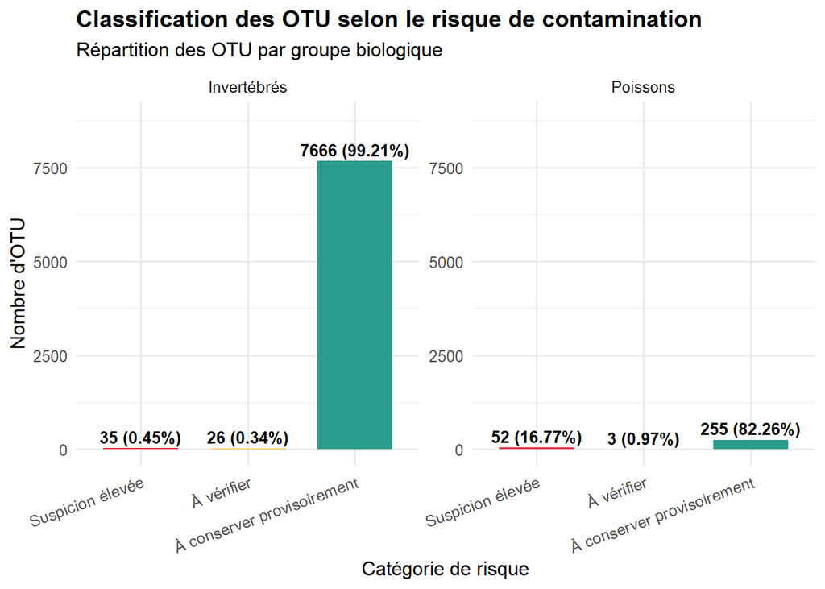

```r
## 44. Visualisation de la classification des OTU

library(ggplot2)

ordre_risque <- c(
  "Suspicion élevée",
  "À vérifier",
  "À conserver provisoirement"
)

donnees_graphique_risque <- synthese_risque_otu_pourcentage %>%
  dplyr::mutate(
    Niveau_risque = factor(
      Niveau_risque,
      levels = ordre_risque
    ),
    Etiquette = paste0(
      Nombre_OTU, " (", Pourcentage, "%)"
    )
  )

graphique_risque_otu <- ggplot(
  donnees_graphique_risque,
  aes(
    x = Niveau_risque,
    y = Nombre_OTU,
    fill = Niveau_risque
  )
) +
  geom_col(width = 0.7) +
  geom_text(
    aes(label = Etiquette),
    vjust = -0.4,
    size = 3.5,
    fontface = "bold"
  ) +
  facet_wrap(~ Groupe, scales = "free_y") +
  scale_fill_manual(
    values = c(
      "Suspicion élevée" = "#E63946",
      "À vérifier" = "#FFB703",
      "À conserver provisoirement" = "#2A9D8F"
    )
  ) +
  labs(
    title = "Classification des OTU selon le risque de contamination",
    subtitle = "Répartition des OTU par groupe biologique",
    x = "Catégorie de risque",
    y = "Nombre d'OTU",
    fill = "Classification"
  ) +
  theme_minimal(base_size = 12) +
  theme(
    axis.text.x = element_text(
      angle = 20,
      hjust = 1
    ),
    legend.position = "none",
    plot.title = element_text(face = "bold")
  ) +
  expand_limits(
    y = max(donnees_graphique_risque$Nombre_OTU) * 1.15
  )

print(graphique_risque_otu)
```

**Analyse de la classification des OTU selon leur niveau de suspicion de contamination**

La classification exploratoire des OTU selon leur profil de détection dans les échantillons biologiques et les contrôles a permis de répartir les 7 727 OTU d’invertébrés et les 310 OTU de poissons en trois catégories : les OTU à conserver provisoirement, les OTU à vérifier et les OTU présentant une suspicion élevée de contamination.

Chez les invertébrés, 7 666 OTU (99,2 %) ont été classées dans la catégorie « À conserver provisoirement », 26 (0,34 %) dans la catégorie « À vérifier » et 35 (0,45 %) dans la catégorie « Suspicion élevée ».

Chez les poissons, 255 OTU (82,3 %) ont été classées comme pouvant être conservées provisoirement, 3 (0,97 %) nécessitent une vérification complémentaire et 52 (16,8 %) présentent une suspicion élevée.

Les OTU 7, 604, 627 et 2741 chez les invertébrés, ainsi que les OTU 1, 41, 56 et 77 chez les poissons, figurent parmi les cas nécessitant une attention particulière en raison de leur profil de détection dans les contrôles. Certaines de ces OTU sont absentes des échantillons biologiques, tandis que d’autres sont également détectées dans ces derniers, mais présentent des signaux importants dans les contrôles.

Ces résultats mettent en évidence la nécessité d’un contrôle qualité approfondi, particulièrement pour les données du groupe poissons. Toutefois, cette classification constitue une première approche exploratoire et ne permet pas de confirmer définitivement la contamination des OTU identifiées. Une analyse complémentaire tenant compte des fréquences de détection et des nombres de lectures par échantillon est nécessaire avant toute exclusion des données.

###Évaluation quantitative des OTU suspectes

**Calcul des indicateurs complémentaires**

Les indicateurs complémentaires ont permis de quantifier les lectures et les fréquences de détection des OTU dans les échantillons biologiques et les contrôles. Ils ont apporté des informations supplémentaires pour l’évaluation des signaux suspects.

```r
## BLOC 44 : ÉVALUATION QUANTITATIVE DES OTU SUSPECTES


# Calcul des indicateurs complémentaires à partir du bilan détaillé

bilan_quantitatif_44 <- bilan_detail_global %>%
  dplyr::mutate(

    # Moyenne de lectures par échantillon biologique positif
    Moyenne_lectures_Biologique = dplyr::if_else(
      N_echantillons_positifs_Biologique > 0,
      Total_lectures_Biologique /
        N_echantillons_positifs_Biologique,
      NA_real_
    ),

    # Moyenne de lectures par blanc de terrain positif
    Moyenne_lectures_Blanc = dplyr::if_else(
      N_echantillons_positifs_Blanc > 0,
      Total_lectures_Blanc /
        N_echantillons_positifs_Blanc,
      NA_real_
    ),

    # Le nombre de blancs d'extraction est égal à 1 dans chaque groupe
    Moyenne_lectures_Blanc_extraction = dplyr::if_else(
      N_echantillons_positifs_Blanc_extraction > 0,
      Total_lectures_Blanc_extraction /
        N_echantillons_positifs_Blanc_extraction,
      NA_real_
    ),

    # Rapport entre la prévalence dans les blancs et celle dans les
    # échantillons biologiques
    Rapport_prevalence_Blanc_Biologique = dplyr::if_else(
      Prevalence_biologique > 0,
      Prevalence_blancs / Prevalence_biologique,
      NA_real_
    ),

    # Rapport entre les lectures moyennes des blancs et des échantillons
    # biologiques positifs
    Rapport_moyenne_Blanc_Biologique = dplyr::if_else(
      !is.na(Moyenne_lectures_Biologique) &
        Moyenne_lectures_Biologique > 0 &
        !is.na(Moyenne_lectures_Blanc),
      Moyenne_lectures_Blanc / Moyenne_lectures_Biologique,
      NA_real_
    ),

    # Signal taxonomique atypique à examiner
    Taxonomie_atypique = dplyr::if_else(
      grepl(
        "Mammalia|Homo|Hominidae|Primates|Bovidae|Bos",
        taxonomy,
        ignore.case = TRUE
      ),
      "Oui",
      "Non"
    )
  )

# Vérification des résultats
dplyr::glimpse(bilan_quantitatif_44)
```

```
## Rows: 8,037
## Columns: 27
## $ OTU                                      <chr> "1", "100", "1000", "1001", "…
## $ taxonomy                                 <chr> "k__Eukaryota;", "k__Eukaryot…
## $ N_echantillons_positifs_Biologique       <int> 23, 6, 3, 3, 4, 4, 3, 3, 5, 1…
## $ N_echantillons_positifs_Blanc            <int> 2, 0, 0, 0, 0, 0, 0, 0, 0, 0,…
## $ N_echantillons_positifs_Blanc_extraction <int> 0, 0, 0, 0, 0, 0, 0, 0, 0, 0,…
## $ Total_lectures_Biologique                <dbl> 186372, 5468, 474, 474, 474, …
## $ Total_lectures_Blanc                     <dbl> 54, 0, 0, 0, 0, 0, 0, 0, 0, 0…
## $ Total_lectures_Blanc_extraction          <dbl> 0, 0, 0, 0, 0, 0, 0, 0, 0, 0,…
## $ N_total_Biologique                       <int> 27, 27, 27, 27, 27, 27, 27, 2…
## $ N_total_Blanc                            <int> 25, 25, 25, 25, 25, 25, 25, 2…
## $ N_total_Blanc_extraction                 <int> 1, 1, 1, 1, 1, 1, 1, 1, 1, 1,…
## $ Groupe                                   <chr> "Invertébrés", "Invertébrés",…
## $ Prevalence_biologique                    <dbl> 85.185185, 22.222222, 11.1111…
## $ Prevalence_blancs                        <dbl> 8, 0, 0, 0, 0, 0, 0, 0, 0, 0,…
## $ Prevalence_blanc_extraction              <dbl> 0, 0, 0, 0, 0, 0, 0, 0, 0, 0,…
## $ Detection_biologique                     <lgl> TRUE, TRUE, TRUE, TRUE, TRUE,…
## $ Detection_blanc                          <lgl> TRUE, FALSE, FALSE, FALSE, FA…
## $ Detection_blanc_extraction               <lgl> FALSE, FALSE, FALSE, FALSE, F…
## $ Total_lectures_controles                 <dbl> 54, 0, 0, 0, 0, 0, 0, 0, 0, 0…
## $ Rapport_controles_biologiques            <dbl> 0.0002897431, 0.0000000000, 0…
## $ Profil_detection                         <chr> "Biologique et contrôles", "B…
## $ Moyenne_lectures_Biologique              <dbl> 8103.13043, 911.33333, 158.00…
## $ Moyenne_lectures_Blanc                   <dbl> 27, NA, NA, NA, NA, NA, NA, N…
## $ Moyenne_lectures_Blanc_extraction        <dbl> NA, NA, NA, NA, NA, NA, NA, N…
## $ Rapport_prevalence_Blanc_Biologique      <dbl> 0.09391304, 0.00000000, 0.000…
## $ Rapport_moyenne_Blanc_Biologique         <dbl> 0.003332046, NA, NA, NA, NA, …
## $ Taxonomie_atypique                       <chr> "Non", "Non", "Non", "Non", "…
```

### 5.3.3 Extraire les OTU détectées dans au moins un contrôle

```r
## ------------------------------------------------------------
## 44.2. OTU détectées dans les contrôles
## ------------------------------------------------------------

otu_controles_44 <- bilan_quantitatif_44 %>%
  dplyr::filter(
    N_echantillons_positifs_Blanc > 0 |
      N_echantillons_positifs_Blanc_extraction > 0
  ) %>%
  dplyr::arrange(
    dplyr::desc(Total_lectures_Blanc +
                  Total_lectures_Blanc_extraction)
  )

# Nombre d'OTU détectées dans au moins un contrôle
cat("Nombre d'OTU détectées dans au moins un contrôle :",
    nrow(otu_controles_44), "\n")
```

```
## Nombre d'OTU détectées dans au moins un contrôle : 116
```

```r
# Aperçu des résultats
otu_controles_44 %>%
  dplyr::select(
    Groupe,
    OTU,
    taxonomy,
    N_echantillons_positifs_Biologique,
    N_echantillons_positifs_Blanc,
    N_echantillons_positifs_Blanc_extraction,
    Prevalence_biologique,
    Prevalence_blancs,
    Total_lectures_Biologique,
    Total_lectures_Blanc,
    Total_lectures_Blanc_extraction,
    Moyenne_lectures_Biologique,
    Moyenne_lectures_Blanc,
    Taxonomie_atypique
  ) %>%
  print(n = 30)
```

```
## # A tibble: 116 × 14
##    Groupe      OTU   taxonomy      N_echantillons_posit…¹ N_echantillons_posit…²
##    <chr>       <chr> <chr>                          <int>                  <int>
##  1 Poissons    1     k__Eukaryota…                      6                     11
##  2 Invertébrés 7     k__Bacteria;…                      0                      1
##  3 Invertébrés 22    k__Eukaryota…                      7                     11
##  4 Poissons    38    k__Eukaryota…                      0                      1
##  5 Poissons    39    k__Eukaryota…                      0                      1
##  6 Poissons    41    k__Eukaryota…                      0                      4
##  7 Poissons    51    k__Eukaryota…                      0                      1
##  8 Poissons    56    k__Eukaryota…                      0                      0
##  9 Poissons    58    k__Eukaryota…                      0                      1
## 10 Poissons    63    k__Eukaryota…                      0                      1
## 11 Poissons    65    k__Eukaryota…                      0                      1
## 12 Poissons    66    k__Eukaryota…                      0                      1
```

[output cut: 25 more lines]

### 5.3.4 Classification quantitative indicative

La classification quantitative a identifié **34 OTU à forte suspicion chez les invertébrés (0,44 %)** et **52 chez les poissons (16,8 %)**. La majorité des OTU a été classée comme provisoirement conservable. Ces résultats ont permis de hiérarchiser les vérifications sans confirmer directement une contamination.

```r
## ------------------------------------------------------------
## 44.3. Classification quantitative indicative
## ------------------------------------------------------------

classification_quantitative_44 <- bilan_quantitatif_44 %>%
  dplyr::mutate(

    Niveau_suspicion_44 = dplyr::case_when(

      # OTU absente des échantillons biologiques mais détectée
      # dans au moins un contrôle
      N_echantillons_positifs_Biologique == 0 &
        (N_echantillons_positifs_Blanc > 0 |
           N_echantillons_positifs_Blanc_extraction > 0) ~
        "Suspicion élevée",

      # OTU détectée dans le blanc d'extraction avec un signal
      # supérieur à la moyenne des échantillons biologiques positifs
      N_echantillons_positifs_Blanc_extraction > 0 &
        N_echantillons_positifs_Biologique > 0 &
        Total_lectures_Blanc_extraction >
          Moyenne_lectures_Biologique ~
        "Suspicion élevée",

      # Prévalence plus élevée dans les blancs de terrain
      # et moyenne de lectures également plus élevée
      N_echantillons_positifs_Blanc > 0 &
        N_echantillons_positifs_Biologique > 0 &
        Prevalence_blancs > Prevalence_biologique &
        Moyenne_lectures_Blanc > Moyenne_lectures_Biologique ~
        "Suspicion élevée",

      # OTU détectée dans les échantillons biologiques et les contrôles
      N_echantillons_positifs_Biologique > 0 &
        (N_echantillons_positifs_Blanc > 0 |
           N_echantillons_positifs_Blanc_extraction > 0) ~
        "À vérifier",

      # OTU présentant une annotation taxonomique atypique
      Taxonomie_atypique == "Oui" ~
        "À vérifier",

      # OTU détectée uniquement dans les échantillons biologiques
      TRUE ~ "À conserver provisoirement"
    )
  )

# Effectifs par groupe et niveau de suspicion
bilan_classification_44 <- classification_quantitative_44 %>%
  dplyr::count(
    Groupe,
    Niveau_suspicion_44,
    name = "Nombre_OTU"
  ) %>%
  dplyr::group_by(Groupe) %>%
  dplyr::mutate(
    Pourcentage = round(
      Nombre_OTU / sum(Nombre_OTU) * 100,
      2
    )
  ) %>%
  dplyr::ungroup()

print(bilan_classification_44)
```

```
## # A tibble: 6 × 4
##   Groupe      Niveau_suspicion_44        Nombre_OTU Pourcentage
##   <chr>       <chr>                           <int>       <dbl>
## 1 Invertébrés Suspicion élevée                   34        0.44
## 2 Invertébrés À conserver provisoirement       7653       99.0
## 3 Invertébrés À vérifier                         40        0.52
## 4 Poissons    Suspicion élevée                   52       16.8
## 5 Poissons    À conserver provisoirement        243       78.4
## 6 Poissons    À vérifier                         15        4.84
```

### 5.3.5 Visualisation de la classification quantitative

Le graphique a mis en évidence une prédominance des OTU provisoirement conservables dans les deux groupes, avec une proportion plus élevée d’OTU à forte suspicion chez les poissons. Cette différence doit être interprétée séparément pour chaque marqueur et à la lumière des détections dans les contrôles.

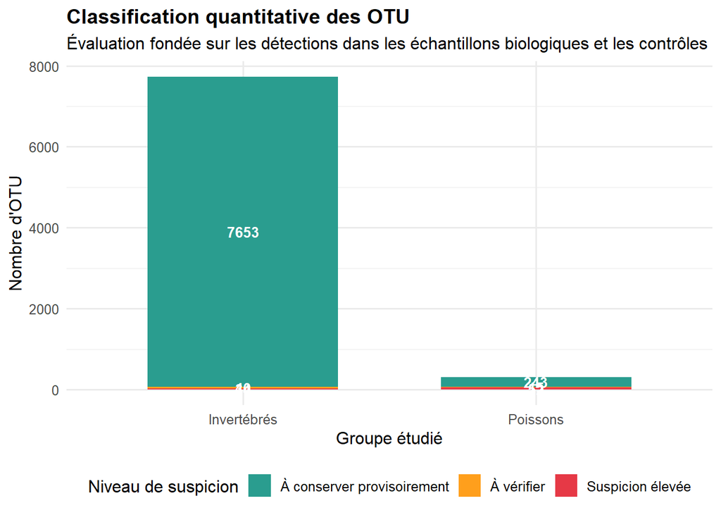

```r
## ------------------------------------------------------------
## 44.4. Graphique de la classification
## ------------------------------------------------------------

graph_classification_44 <- ggplot2::ggplot(
  bilan_classification_44,
  ggplot2::aes(
    x = Groupe,
    y = Nombre_OTU,
    fill = Niveau_suspicion_44
  )
) +
  ggplot2::geom_col(
    position = "stack",
    width = 0.65
  ) +
  ggplot2::geom_text(
    ggplot2::aes(label = Nombre_OTU),
    position = ggplot2::position_stack(vjust = 0.5),
    color = "white",
    size = 3.5,
    fontface = "bold"
  ) +
  ggplot2::scale_fill_manual(
    values = c(
      "Suspicion élevée" = "#E63946",
      "À vérifier" = "#FF9F1C",
      "À conserver provisoirement" = "#2A9D8F"
    )
  ) +
  ggplot2::labs(
    title = "Classification quantitative des OTU",
    subtitle = "Évaluation fondée sur les détections dans les échantillons biologiques et les contrôles",
    x = "Groupe étudié",
    y = "Nombre d'OTU",
    fill = "Niveau de suspicion"
  ) +
  ggplot2::theme_minimal(base_size = 12) +
  ggplot2::theme(
    plot.title = ggplot2::element_text(face = "bold"),
    legend.position = "bottom"
  )

print(graph_classification_44)
```

### 5.3.6 Liste des OTU prioritaires

L’identification des OTU prioritaires a permis de cibler les séquences nécessitant des vérifications complémentaires, notamment celles associées à des lectures dans les contrôles ou à des annotations taxonomiques inhabituelles.

```r
## ------------------------------------------------------------
## 44.5. Liste des OTU prioritaires
## ------------------------------------------------------------

otu_prioritaires_44 <- classification_quantitative_44 %>%
  dplyr::filter(
    Niveau_suspicion_44 == "Suspicion élevée" |
      Taxonomie_atypique == "Oui"
  ) %>%
  dplyr::select(
    Groupe,
    OTU,
    taxonomy,
    Niveau_suspicion_44,
    Taxonomie_atypique,
    N_echantillons_positifs_Biologique,
    N_echantillons_positifs_Blanc,
    N_echantillons_positifs_Blanc_extraction,
    Total_lectures_Biologique,
    Total_lectures_Blanc,
    Total_lectures_Blanc_extraction,
    Moyenne_lectures_Biologique,
    Moyenne_lectures_Blanc,
    Rapport_prevalence_Blanc_Biologique
  ) %>%
  dplyr::arrange(
    Groupe,
    dplyr::desc(Total_lectures_Blanc +
                  Total_lectures_Blanc_extraction)
  )

cat("Nombre d'OTU prioritaires à examiner :",
    nrow(otu_prioritaires_44), "\n")
```

```
## Nombre d'OTU prioritaires à examiner : 111
```

```r
print(otu_prioritaires_44, n = 50)
```

```
## # A tibble: 111 × 14
##    Groupe      OTU   taxonomy             Niveau_suspicion_44 Taxonomie_atypique
##    <chr>       <chr> <chr>                <chr>               <chr>
##  1 Invertébrés 7     k__Bacteria;p__Prot… Suspicion élevée    Non
##  2 Invertébrés 22    k__Eukaryota;p__Cho… Suspicion élevée    Oui
##  3 Invertébrés 604   k__Eukaryota;p__Cho… Suspicion élevée    Oui
##  4 Invertébrés 623   k__Eukaryota;        Suspicion élevée    Non
##  5 Invertébrés 627   k__Bacteria;p__Bact… Suspicion élevée    Non
##  6 Invertébrés 1179  k__Bacteria;p__Prot… Suspicion élevée    Non
##  7 Invertébrés 1292  k__Eukaryota;p__Cho… Suspicion élevée    Oui
##  8 Invertébrés 1406  k__Eukaryota;p__Cho… Suspicion élevée    Oui
##  9 Invertébrés 1559  k__Bacteria;p__Prot… Suspicion élevée    Non
## 10 Invertébrés 1660  k__Eukaryota;p__Asc… Suspicion élevée    Non
## 11 Invertébrés 1838  k__Bacteria;p__Prot… Suspicion élevée    Non
## 12 Invertébrés 1945  k__Eukaryota;p__Cho… Suspicion élevée    Oui
```

[output cut: 45 more lines]

###Distinction entre les risques liés aux contrôles et les anomalies taxonomiques **Croisement des deux catégories de problèmes**

**Interprétation** Les résultats confirment que nous devons traiter séparément les risques de contamination potentielle et les anomalies d’identification taxonomique. Cette distinction est essentielle pour éviter de supprimer des OTU biologiquement pertinentes sur la seule base de leur annotation. Chez les invertébrés Sur les 7 727 OTU : - 7 653 (environ 99 %) ne présentent ni détection dans les contrôles ni anomalie taxonomique selon notre critère. - 13 présentent une annotation atypique, mais aucune détection dans les contrôles. - 8 cumulent une annotation atypique et une détection dans les contrôles. - 53 sont détectées dans les contrôles sans être signalées comme atypiques. Cela montre que les anomalies taxonomiques ne sont pas nécessairement liées à une contamination. Les 13 OTU absentes des contrôles doivent notamment faire l’objet d’une vérification de leur identification, sans être automatiquement supprimées. Chez les poissons Sur les 310 OTU : - 243 (78,4 %) ne présentent aucun de ces deux signaux. - 12 ont une annotation atypique, mais sont absentes des contrôles. - 45 présentent simultanément une annotation atypique et une détection dans les contrôles. - 10 sont détectées dans les contrôles sans annotation atypique. Le résultat le plus marquant est celui des 45 OTU de poissons qui cumulent une détection dans les contrôles et une annotation taxonomique atypique.

Cela renforce la nécessité d’examiner les éventuels signaux de contamination humaine ou de mammifères dans cette matrice.

```r
## ============================================================
## BLOC 45 : DISTINCTION ENTRE RISQUE DE CONTAMINATION
## ET ANOMALIE TAXONOMIQUE
## ============================================================

bilan_45 <- classification_quantitative_44 %>%
  dplyr::mutate(

    Signal_controle = dplyr::if_else(
      N_echantillons_positifs_Blanc > 0 |
        N_echantillons_positifs_Blanc_extraction > 0,
      "Détectée dans au moins un contrôle",
      "Absente des contrôles"
    ),

    Signal_taxonomique = dplyr::if_else(
      Taxonomie_atypique == "Oui",
      "Annotation atypique",
      "Annotation non signalée comme atypique"
    )
  )

# Tableau croisé des deux dimensions
tableau_croise_45 <- bilan_45 %>%
  dplyr::count(
    Groupe,
    Signal_controle,
    Signal_taxonomique,
    name = "Nombre_OTU"
  )

print(tableau_croise_45, n = Inf)
```

```
## # A tibble: 8 × 4
##   Groupe      Signal_controle                    Signal_taxonomique   Nombre_OTU
##   <chr>       <chr>                              <chr>                     <int>
## 1 Invertébrés Absente des contrôles              Annotation atypique          13
## 2 Invertébrés Absente des contrôles              Annotation non sign…       7653
## 3 Invertébrés Détectée dans au moins un contrôle Annotation atypique           8
## 4 Invertébrés Détectée dans au moins un contrôle Annotation non sign…         53
## 5 Poissons    Absente des contrôles              Annotation atypique          12
## 6 Poissons    Absente des contrôles              Annotation non sign…        243
## 7 Poissons    Détectée dans au moins un contrôle Annotation atypique          45
## 8 Poissons    Détectée dans au moins un contrôle Annotation non sign…         10
```

### 5.3.7 Classification fondée uniquement sur les contrôles

##Interprétation du bloc 45.2 : niveau de risque lié aux contrôles

C’est le tableau le plus important pour évaluer les signaux potentiellement liés à la contamination. Chez les invertébrés - 7 666 OTU (99,2 %) ne sont détectées dans aucun contrôle. - 31 OTU (0,4 %) sont détectées uniquement dans les contrôles. - 27 OTU (0,35 %) sont détectées à la fois dans les échantillons biologiques et dans les contrôles. - 2 OTU présentent un signal de blancs de terrain à examiner. - 1 OTU présente un signal du blanc d’extraction à examiner. La majorité des OTU ne présentent donc aucun signal de détection dans les contrôles. Néanmoins, les OTU présentes dans les blancs doivent être examinées individuellement, particulièrement celles qui sont également détectées dans les échantillons biologiques. Chez les poissons - 255 OTU (82,3 %) ne sont détectées dans aucun contrôle. - 51 OTU (16,4 %) sont détectées uniquement dans les contrôles. - 3 OTU (0,97 %) sont détectées dans les échantillons biologiques et les contrôles. - 1 OTU présente un signal du blanc d’extraction à examiner.

Le jeu de données poissons présente une proportion nettement plus importante d’OTU détectées uniquement dans les contrôles que celui des invertébrés.

Cette situation peut être liée à des contaminations potentielles, à des transferts de matériel génétique ou à d’autres phénomènes techniques. Elle doit être examinée avant toute analyse écologique définitive.

Il faut toutefois noter que les catégories « Signal blancs à examiner » et « Signal extraction à examiner » correspondent à des règles de classification particulières. Elles ne représentent pas nécessairement toutes les OTU détectées dans les contrôles.

```r
## ------------------------------------------------------------
## 45.2. Classification indépendante de la taxonomie
## ------------------------------------------------------------

classification_controles_45 <- bilan_45 %>%
  dplyr::mutate(

    Niveau_risque_controle = dplyr::case_when(

      # Absence biologique et présence dans un contrôle
      N_echantillons_positifs_Biologique == 0 &
        Signal_controle == "Détectée dans au moins un contrôle" ~
        "Contrôle uniquement",

      # Signal du blanc d'extraction supérieur à la moyenne
      # des échantillons biologiques positifs
      N_echantillons_positifs_Blanc_extraction > 0 &
        N_echantillons_positifs_Biologique > 0 &
        Total_lectures_Blanc_extraction >
          Moyenne_lectures_Biologique ~
        "Signal extraction à examiner",

      # Prévalence et moyenne des lectures plus élevées
      # dans les blancs de terrain
      N_echantillons_positifs_Blanc > 0 &
        N_echantillons_positifs_Biologique > 0 &
        Prevalence_blancs > Prevalence_biologique &
        Moyenne_lectures_Blanc > Moyenne_lectures_Biologique ~
        "Signal blancs à examiner",

      # Présence dans les deux types d'échantillons
      Signal_controle == "Détectée dans au moins un contrôle" &
        N_echantillons_positifs_Biologique > 0 ~
        "Présence biologique et contrôles",

      # Absence de détection dans tous les contrôles
      TRUE ~ "Aucun signal dans les contrôles"
    )
  )

# Synthèse par groupe
synthese_controles_45 <- classification_controles_45 %>%
  dplyr::count(
    Groupe,
    Niveau_risque_controle,
    name = "Nombre_OTU"
  ) %>%
  dplyr::group_by(Groupe) %>%
  dplyr::mutate(
    Pourcentage = round(
      Nombre_OTU / sum(Nombre_OTU) * 100,
      2
    )
  ) %>%
  dplyr::ungroup()

print(synthese_controles_45, n = Inf)
```

```
## # A tibble: 9 × 4
##   Groupe      Niveau_risque_controle           Nombre_OTU Pourcentage
##   <chr>       <chr>                                 <int>       <dbl>
## 1 Invertébrés Aucun signal dans les contrôles        7666       99.2
## 2 Invertébrés Contrôle uniquement                      31        0.4
## 3 Invertébrés Présence biologique et contrôles         27        0.35
## 4 Invertébrés Signal blancs à examiner                  2        0.03
## 5 Invertébrés Signal extraction à examiner              1        0.01
## 6 Poissons    Aucun signal dans les contrôles         255       82.3
## 7 Poissons    Contrôle uniquement                      51       16.4
## 8 Poissons    Présence biologique et contrôles          3        0.97
## 9 Poissons    Signal extraction à examiner              1        0.32
```

### 5.3.8 Anomalies taxonomiques sans détection dans les contrôles

**Interprétation**

25 OTU ont été identifiés présentant une anomalie taxonomique sans aucune détection dans les contrôles : - 13 chez les invertébrés ; - 12 chez les poissons. Ces résultats sont particulièrement intéressants, car ils permettent de distinguer une possible erreur d’assignation taxonomique d’une contamination détectable dans les blancs. **Chez les invertébrés**

Les **OTU 1301, 3086 et 6692** sont notamment annotées comme Chordata/Mammalia.

D’autres OTU, telles que **1330, 1953, 2863, 3566, 3743, 3893, 3954, 4100 et 4232,** présentent des annotations appartenant à des groupes taxonomiques qui doivent être vérifiés au regard de la cible de l’analyse.

Il **ne faut cependant pas considérer automatiquement les annotations Arthropoda comme erronées** : les *arthropodes constituent bien un groupe d’invertébrés. Il faudra examiner les rangs taxonomiques complets pour comprendre ce qui rend ces annotations atypiques.*

**Chez les poissons**

Les **12 OTU** sont toutes annotées comme **Chordata/Mammalia** dans les extraits fournis.

L’analyse croisée des détections dans les échantillons biologiques et les contrôles négatifs, associée à l’examen des annotations taxonomiques, a permis de distinguer les OTU présentant des signaux de contamination potentielle de celles dont l’identification taxonomique mérite une vérification indépendante.

Chez les invertébrés, 7 666 OTU (99,2 %) n’ont été détectées dans aucun contrôle, tandis que 31 OTU ont été détectées uniquement dans les contrôles et 27 à la fois dans les échantillons biologiques et les contrôles. Par ailleurs, 21 OTU présentent une annotation taxonomique atypique, dont 13 sans détection dans les contrôles.

Chez les poissons, 255 OTU (82,3 %) n’ont été détectées dans aucun contrôle. En revanche, 51 OTU ont été détectées uniquement dans les contrôles et 3 à la fois dans les échantillons biologiques et les contrôles. L’analyse taxonomique a également mis en évidence 57 OTU présentant des annotations atypiques, dont 45 sont également détectées dans les contrôles.

Ces observations révèlent une proportion plus importante de signaux associés aux contrôles dans le jeu de données poissons que dans celui des invertébrés. Elles soulignent également la nécessité de ne pas confondre contamination potentielle et anomalie taxonomique. En effet, certaines OTU présentant des annotations atypiques sont exclusivement détectées dans les échantillons biologiques.

En conséquence, les résultats justifient une étape complémentaire de vérification des séquences et des assignations taxonomiques, ainsi qu’une évaluation individuelle des OTU détectées dans les contrôles, avant toute décision de filtrage définitif des matrices.

```r
## 45.3. Anomalies taxonomiques sans détection dans les contrôles

otu_taxonomie_seule_45 <- classification_controles_45 %>%
  dplyr::filter(
    Taxonomie_atypique == "Oui",
    Signal_controle == "Absente des contrôles"
  ) %>%
  dplyr::select(
    Groupe,
    OTU,
    taxonomy,
    N_echantillons_positifs_Biologique,
    Total_lectures_Biologique,
    Taxonomie_atypique
  ) %>%
  dplyr::arrange(Groupe, OTU)

cat(
  "Nombre d'OTU présentant uniquement une anomalie taxonomique :",
  nrow(otu_taxonomie_seule_45),
  "\n"
)
```

```
## Nombre d'OTU présentant uniquement une anomalie taxonomique : 25
```

```r
print(otu_taxonomie_seule_45, n = Inf)
```

```
## # A tibble: 25 × 6
##    Groupe      OTU   taxonomy      N_echantillons_posit…¹ Total_lectures_Biolo…²
##    <chr>       <chr> <chr>                          <int>                  <dbl>
##  1 Invertébrés 1301  k__Eukaryota…                      2                    343
##  2 Invertébrés 1330  k__Eukaryota…                      3                    335
##  3 Invertébrés 1953  k__Eukaryota…                      1                    190
##  4 Invertébrés 2863  k__Eukaryota…                      1                    104
##  5 Invertébrés 3086  k__Eukaryota…                      1                     91
##  6 Invertébrés 3566  k__Eukaryota…                      1                     68
##  7 Invertébrés 3743  k__Eukaryota…                      1                     61
##  8 Invertébrés 3893  k__Eukaryota…                      1                     56
##  9 Invertébrés 3954  k__Eukaryota…                      1                     54
## 10 Invertébrés 4100  k__Eukaryota…                      1                     49
## 11 Invertébrés 4232  k__Eukaryota…                      1                     46
## 12 Invertébrés 6692  k__Eukaryota…                      1                     10
```

[output cut: 16 more lines]

```r
options(na.print = "NA")
getOption("na.print")
```

```
## [1] "NA"
```

```r
# Vérification des colonnes de bilan_quantitatif_44
names(bilan_quantitatif_44)
```

```
##  [1] "OTU"
##  [2] "taxonomy"
##  [3] "N_echantillons_positifs_Biologique"
##  [4] "N_echantillons_positifs_Blanc"
##  [5] "N_echantillons_positifs_Blanc_extraction"
##  [6] "Total_lectures_Biologique"
##  [7] "Total_lectures_Blanc"
##  [8] "Total_lectures_Blanc_extraction"
##  [9] "N_total_Biologique"
## [10] "N_total_Blanc"
## [11] "N_total_Blanc_extraction"
## [12] "Groupe"
## [13] "Prevalence_biologique"
## [14] "Prevalence_blancs"
## [15] "Prevalence_blanc_extraction"
## [16] "Detection_biologique"
## [17] "Detection_blanc"
## [18] "Detection_blanc_extraction"
## [19] "Total_lectures_controles"
## [20] "Rapport_controles_biologiques"
## [21] "Profil_detection"
## [22] "Moyenne_lectures_Biologique"
## [23] "Moyenne_lectures_Blanc"
## [24] "Moyenne_lectures_Blanc_extraction"
## [25] "Rapport_prevalence_Blanc_Biologique"
## [26] "Rapport_moyenne_Blanc_Biologique"
## [27] "Taxonomie_atypique"
```

```r
# Identifier les colonnes relatives aux contrôles
grep(
  "controle|blanc|Taxonomie|Statut",
  names(bilan_quantitatif_44),
  value = TRUE,
  ignore.case = TRUE
)
```

```
##  [1] "N_echantillons_positifs_Blanc"
##  [2] "N_echantillons_positifs_Blanc_extraction"
##  [3] "Total_lectures_Blanc"
##  [4] "Total_lectures_Blanc_extraction"
##  [5] "N_total_Blanc"
##  [6] "N_total_Blanc_extraction"
##  [7] "Prevalence_blancs"
##  [8] "Prevalence_blanc_extraction"
##  [9] "Detection_blanc"
## [10] "Detection_blanc_extraction"
## [11] "Total_lectures_controles"
## [12] "Rapport_controles_biologiques"
## [13] "Moyenne_lectures_Blanc"
## [14] "Moyenne_lectures_Blanc_extraction"
## [15] "Rapport_prevalence_Blanc_Biologique"
## [16] "Rapport_moyenne_Blanc_Biologique"
## [17] "Taxonomie_atypique"
```

```r
names(bilan_detail_global)
```

```
##  [1] "OTU"
##  [2] "taxonomy"
##  [3] "N_echantillons_positifs_Biologique"
##  [4] "N_echantillons_positifs_Blanc"
##  [5] "N_echantillons_positifs_Blanc_extraction"
##  [6] "Total_lectures_Biologique"
##  [7] "Total_lectures_Blanc"
##  [8] "Total_lectures_Blanc_extraction"
##  [9] "N_total_Biologique"
## [10] "N_total_Blanc"
## [11] "N_total_Blanc_extraction"
## [12] "Groupe"
## [13] "Prevalence_biologique"
## [14] "Prevalence_blancs"
## [15] "Prevalence_blanc_extraction"
## [16] "Detection_biologique"
## [17] "Detection_blanc"
## [18] "Detection_blanc_extraction"
## [19] "Total_lectures_controles"
## [20] "Rapport_controles_biologiques"
## [21] "Profil_detection"
```

```r
grep(
  "controle|blanc|Taxonomie|Statut",
  names(bilan_detail_global),
  value = TRUE,
  ignore.case = TRUE
)
```

```
##  [1] "N_echantillons_positifs_Blanc"
##  [2] "N_echantillons_positifs_Blanc_extraction"
##  [3] "Total_lectures_Blanc"
##  [4] "Total_lectures_Blanc_extraction"
##  [5] "N_total_Blanc"
##  [6] "N_total_Blanc_extraction"
##  [7] "Prevalence_blancs"
##  [8] "Prevalence_blanc_extraction"
##  [9] "Detection_blanc"
## [10] "Detection_blanc_extraction"
## [11] "Total_lectures_controles"
## [12] "Rapport_controles_biologiques"
```

### 5.3.9 Vérification des annotations taxonomiques

##Interprétation

Les résultats montrent que 25 OTUs présentent une taxonomie atypique tout en étant absents des blancs de terrain et d’extraction : 13 chez les invertébrés et 12 chez les poissons.

Chez les invertébrés, les annotations sont diversifiées : plusieurs OTUs appartiennent aux Arthropoda (Branchiopoda), tandis que trois sont associés aux Mammalia et un aux Chlorophyta.

Chez les poissons, les 12 OTUs sont annotés comme Chordata/Mammalia, avec des affiliations notamment aux Artiodactyla et aux Primates. Certains présentent des nombres de lectures importants, notamment les OTUs 21 (62 040 lectures) et 33 (22 788 lectures).

Interprétation : l’absence de détection dans les contrôles ne permet pas de confirmer la validité de ces annotations. Ces OTUs nécessitent une vérification taxonomique approfondie, notamment au niveau des séquences, avant toute décision de conservation ou d’exclusion.

```r
# BLOC 46 - VERIFICATION DES ANNOTATIONS TAXONOMIQUES

# 46.1 - Sélection des OTUs à taxonomie atypique
# absents des blancs de terrain et d'extraction

otu_atypiques_sans_controles_46 <- bilan_quantitatif_44 %>%
  dplyr::filter(
    Taxonomie_atypique == "Oui",
    Detection_blanc == FALSE,
    Detection_blanc_extraction == FALSE
  ) %>%
  dplyr::select(
    Groupe,
    OTU,
    taxonomy,
    Total_lectures_Biologique,
    N_echantillons_positifs_Biologique
  ) %>%
  dplyr::arrange(
    Groupe,
    dplyr::desc(Total_lectures_Biologique)
  )

# Affichage des OTUs concernés
print(otu_atypiques_sans_controles_46, n = Inf)
```

```
## # A tibble: 25 × 5
##    Groupe      OTU   taxonomy      Total_lectures_Biolo…¹ N_echantillons_posit…²
##    <chr>       <chr> <chr>                          <dbl>                  <int>
##  1 Invertébrés 1301  k__Eukaryota…                    343                      2
##  2 Invertébrés 1330  k__Eukaryota…                    335                      3
##  3 Invertébrés 1953  k__Eukaryota…                    190                      1
##  4 Invertébrés 2863  k__Eukaryota…                    104                      1
##  5 Invertébrés 3086  k__Eukaryota…                     91                      1
##  6 Invertébrés 3566  k__Eukaryota…                     68                      1
##  7 Invertébrés 3743  k__Eukaryota…                     61                      1
##  8 Invertébrés 3893  k__Eukaryota…                     56                      1
##  9 Invertébrés 3954  k__Eukaryota…                     54                      1
## 10 Invertébrés 4100  k__Eukaryota…                     49                      1
## 11 Invertébrés 4232  k__Eukaryota…                     46                      1
## 12 Invertébrés 6692  k__Eukaryota…                     10                      1
## 13 Invertébrés 6927  k__Eukaryota…                      9                      1
## 14 Poissons    21    k__Eukaryota…                  62040                      1
## 15 Poissons    33    k__Eukaryota…                  22788                      1
## 16 Poissons    57    k__Eukaryota…                   2048                      1
## 17 Poissons    121   k__Eukaryota…                    645                      1
## 18 Poissons    143   k__Eukaryota…                    513                      1
## 19 Poissons    247   k__Eukaryota…                    110                      1
## 20 Poissons    282   k__Eukaryota…                     34                      1
## 21 Poissons    291   k__Eukaryota…                     16                      2
## 22 Poissons    296   k__Eukaryota…                     12                      2
## 23 Poissons    300   k__Eukaryota…                     10                      1
## 24 Poissons    301   k__Eukaryota…                      9                      1
## 25 Poissons    304   k__Eukaryota…                      8                      1
## # ℹ abbreviated names: ¹Total_lectures_Biologique,
## #   ²N_echantillons_positifs_Biologique
```

```r
# Nombre d'OTUs par groupe
resume_atypiques_46 <- otu_atypiques_sans_controles_46 %>%
  dplyr::count(Groupe, name = "Nombre_OTUs")

print(resume_atypiques_46)
```

```
## # A tibble: 2 × 2
##   Groupe      Nombre_OTUs
##   <chr>             <int>
## 1 Invertébrés          13
## 2 Poissons             12
```

```r
# Vérification du nombre total
cat(
  "\nNombre total d'OTUs atypiques absents des contrôles :",
  nrow(otu_atypiques_sans_controles_46),
  "\n"
)
```

```
##
## Nombre total d'OTUs atypiques absents des contrôles : 25
```

```r
options(na.print = "NA")
getOption("na.print")
```

```
## [1] "NA"
```

**Recréer le tableau des taxonomies à vérifier**

```r
taxonomies_a_verifier_46 <- niveaux_taxonomiques_complets %>%
  dplyr::inner_join(
    otu_atypiques_sans_controles_46 %>%
      dplyr::select(Groupe, OTU),
    by = c("Groupe", "OTU")
  ) %>%
  dplyr::arrange(Groupe, OTU)

# Vérifier que les 25 OTUs sont bien retrouvés
cat("Nombre d'OTUs retrouvés :", nrow(taxonomies_a_verifier_46), "\n")
```

```
## Nombre d'OTUs retrouvés : 25
```

```r
print(as.data.frame(taxonomies_a_verifier_46), row.names = FALSE)
```

```
##   OTU      Groupe     Regne Embranchement           Classe        Ordre
##  1301 Invertébrés Eukaryota      Chordata         Mammalia Artiodactyla
##  1330 Invertébrés Eukaryota    Arthropoda     Branchiopoda  Diplostraca
##  1953 Invertébrés Eukaryota    Arthropoda     Branchiopoda  Diplostraca
##  2863 Invertébrés Eukaryota    Arthropoda     Branchiopoda  Diplostraca
##  3086 Invertébrés Eukaryota      Chordata         Mammalia     Rodentia
##  3566 Invertébrés Eukaryota    Arthropoda     Branchiopoda  Diplostraca
##  3743 Invertébrés Eukaryota    Arthropoda     Branchiopoda  Diplostraca
##  3893 Invertébrés Eukaryota    Arthropoda     Branchiopoda  Diplostraca
##  3954 Invertébrés Eukaryota    Arthropoda     Branchiopoda  Diplostraca
##  4100 Invertébrés Eukaryota    Arthropoda     Branchiopoda  Diplostraca
##  4232 Invertébrés Eukaryota    Arthropoda     Branchiopoda  Diplostraca
##  6692 Invertébrés Eukaryota      Chordata         Mammalia    Carnivora
##  6927 Invertébrés Eukaryota   Chlorophyta Trebouxiophyceae Trebouxiales
##   121    Poissons Eukaryota      Chordata         Mammalia Artiodactyla
##   143    Poissons Eukaryota      Chordata         Mammalia Artiodactyla
##    21    Poissons Eukaryota      Chordata         Mammalia Artiodactyla
##   247    Poissons Eukaryota      Chordata         Mammalia Artiodactyla
##   282    Poissons Eukaryota      Chordata         Mammalia Artiodactyla
##   291    Poissons Eukaryota      Chordata         Mammalia     Primates
##   296    Poissons Eukaryota      Chordata         Mammalia     Primates
##   300    Poissons Eukaryota      Chordata         Mammalia Artiodactyla
##   301    Poissons Eukaryota      Chordata         Mammalia Artiodactyla
##   304    Poissons Eukaryota      Chordata         Mammalia Artiodactyla
##    33    Poissons Eukaryota      Chordata         Mammalia Artiodactyla
##    57    Poissons Eukaryota      Chordata         Mammalia Artiodactyla
##        Famille       Genre Espece
##        Bovidae         Bos   <NA>
##     Bosminidae     Bosmina   <NA>
##     Bosminidae     Bosmina   <NA>
##     Bosminidae     Bosmina   <NA>
##     Cricetidae     Ondatra   <NA>
##     Bosminidae     Bosmina   <NA>
##     Bosminidae     Bosmina   <NA>
##     Bosminidae     Bosmina   <NA>
##     Bosminidae     Bosmina   <NA>
##     Bosminidae     Bosmina   <NA>
##     Bosminidae     Bosmina   <NA>
##        Felidae       Felis   <NA>
##  Trebouxiaceae Lobosphaera   <NA>
##        Bovidae         Bos   <NA>
##        Bovidae         Bos   <NA>
##        Bovidae         Bos   <NA>
##        Bovidae         Bos   <NA>
##        Bovidae         Bos   <NA>
##      Hominidae        Homo   <NA>
##      Hominidae        Homo   <NA>
##        Bovidae         Bos   <NA>
##        Bovidae         Bos   <NA>
##        Bovidae         Bos   <NA>
##        Bovidae         Bos   <NA>
##        Bovidae         Bos   <NA>
```

**Créer le résumé de la résolution taxonomique**

```r
resume_resolution_46 <- taxonomies_a_verifier_46 %>%
  dplyr::group_by(Groupe) %>%
  dplyr::summarise(
    Nombre_OTUs = dplyr::n(),
    Avec_Embranchement = sum(!is.na(Embranchement)),
    Avec_Classe = sum(!is.na(Classe)),
    Avec_Ordre = sum(!is.na(Ordre)),
    Avec_Famille = sum(!is.na(Famille)),
    Avec_Genre = sum(!is.na(Genre)),
    Avec_Espece = sum(!is.na(Espece)),
    .groups = "drop"
  )

print(as.data.frame(resume_resolution_46), row.names = FALSE)
```

```
##       Groupe Nombre_OTUs Avec_Embranchement Avec_Classe Avec_Ordre Avec_Famille
##  Invertébrés          13                 13          13         13           13
##     Poissons          12                 12          12         12           12
##  Avec_Genre Avec_Espece
##          13           0
##          12           0
```

```r
# ============================================================
# BLOC 46.2 - EXAMEN DETAILLE DES TAXONOMIES ATYPIQUES
# ============================================================

# 46.2.1 - Extraction des informations taxonomiques
taxonomies_a_verifier_46 <- niveaux_taxonomiques_complets %>%
  dplyr::inner_join(
    otu_atypiques_sans_controles_46 %>%
      dplyr::select(Groupe, OTU),
    by = c("Groupe", "OTU")
  ) %>%
  dplyr::arrange(Groupe, OTU)

# Affichage des classifications complètes
# Vérification de la structure
str(taxonomies_a_verifier_46)
```

```
## 'data.frame':    25 obs. of  9 variables:
##  $ OTU          : chr  "1301" "1330" "1953" "2863" ...
##  $ Groupe       : chr  "Invertébrés" "Invertébrés" "Invertébrés" "Invertébrés" ...
##  $ Regne        : chr  "Eukaryota" "Eukaryota" "Eukaryota" "Eukaryota" ...
##  $ Embranchement: chr  "Chordata" "Arthropoda" "Arthropoda" "Arthropoda" ...
##  $ Classe       : chr  "Mammalia" "Branchiopoda" "Branchiopoda" "Branchiopoda" ...
##  $ Ordre        : chr  "Artiodactyla" "Diplostraca" "Diplostraca" "Diplostraca" ...
##  $ Famille      : chr  "Bovidae" "Bosminidae" "Bosminidae" "Bosminidae" ...
##  $ Genre        : chr  "Bos" "Bosmina" "Bosmina" "Bosmina" ...
##  $ Espece       : chr  NA NA NA NA ...
```

```r
# Afficher le tableau
print(
  as.data.frame(taxonomies_a_verifier_46),
  row.names = FALSE
)
```

```
##   OTU      Groupe     Regne Embranchement           Classe        Ordre
##  1301 Invertébrés Eukaryota      Chordata         Mammalia Artiodactyla
##  1330 Invertébrés Eukaryota    Arthropoda     Branchiopoda  Diplostraca
##  1953 Invertébrés Eukaryota    Arthropoda     Branchiopoda  Diplostraca
##  2863 Invertébrés Eukaryota    Arthropoda     Branchiopoda  Diplostraca
##  3086 Invertébrés Eukaryota      Chordata         Mammalia     Rodentia
##  3566 Invertébrés Eukaryota    Arthropoda     Branchiopoda  Diplostraca
##  3743 Invertébrés Eukaryota    Arthropoda     Branchiopoda  Diplostraca
##  3893 Invertébrés Eukaryota    Arthropoda     Branchiopoda  Diplostraca
##  3954 Invertébrés Eukaryota    Arthropoda     Branchiopoda  Diplostraca
##  4100 Invertébrés Eukaryota    Arthropoda     Branchiopoda  Diplostraca
##  4232 Invertébrés Eukaryota    Arthropoda     Branchiopoda  Diplostraca
##  6692 Invertébrés Eukaryota      Chordata         Mammalia    Carnivora
##  6927 Invertébrés Eukaryota   Chlorophyta Trebouxiophyceae Trebouxiales
##   121    Poissons Eukaryota      Chordata         Mammalia Artiodactyla
##   143    Poissons Eukaryota      Chordata         Mammalia Artiodactyla
##    21    Poissons Eukaryota      Chordata         Mammalia Artiodactyla
##   247    Poissons Eukaryota      Chordata         Mammalia Artiodactyla
##   282    Poissons Eukaryota      Chordata         Mammalia Artiodactyla
##   291    Poissons Eukaryota      Chordata         Mammalia     Primates
##   296    Poissons Eukaryota      Chordata         Mammalia     Primates
##   300    Poissons Eukaryota      Chordata         Mammalia Artiodactyla
##   301    Poissons Eukaryota      Chordata         Mammalia Artiodactyla
##   304    Poissons Eukaryota      Chordata         Mammalia Artiodactyla
##    33    Poissons Eukaryota      Chordata         Mammalia Artiodactyla
##    57    Poissons Eukaryota      Chordata         Mammalia Artiodactyla
##        Famille       Genre Espece
##        Bovidae         Bos   <NA>
##     Bosminidae     Bosmina   <NA>
##     Bosminidae     Bosmina   <NA>
##     Bosminidae     Bosmina   <NA>
##     Cricetidae     Ondatra   <NA>
##     Bosminidae     Bosmina   <NA>
##     Bosminidae     Bosmina   <NA>
##     Bosminidae     Bosmina   <NA>
##     Bosminidae     Bosmina   <NA>
##     Bosminidae     Bosmina   <NA>
##     Bosminidae     Bosmina   <NA>
##        Felidae       Felis   <NA>
##  Trebouxiaceae Lobosphaera   <NA>
##        Bovidae         Bos   <NA>
##        Bovidae         Bos   <NA>
##        Bovidae         Bos   <NA>
##        Bovidae         Bos   <NA>
##        Bovidae         Bos   <NA>
##      Hominidae        Homo   <NA>
##      Hominidae        Homo   <NA>
##        Bovidae         Bos   <NA>
##        Bovidae         Bos   <NA>
##        Bovidae         Bos   <NA>
##        Bovidae         Bos   <NA>
##        Bovidae         Bos   <NA>
```

```r
# Résumé de la résolution taxonomique
print(
  as.data.frame(resume_resolution_46),
  row.names = FALSE
)
```

```
##       Groupe Nombre_OTUs Avec_Embranchement Avec_Classe Avec_Ordre Avec_Famille
##  Invertébrés          13                 13          13         13           13
##     Poissons          12                 12          12         12           12
##  Avec_Genre Avec_Espece
##          13           0
##          12           0
```

```r
# 46.2.2 - Résumé du niveau de résolution taxonomique
resume_resolution_46 <- taxonomies_a_verifier_46 %>%
  dplyr::group_by(Groupe) %>%
  dplyr::summarise(
    Nombre_OTUs = dplyr::n(),
    Avec_Embranchement = sum(!is.na(Embranchement)),
    Avec_Classe = sum(!is.na(Classe)),
    Avec_Ordre = sum(!is.na(Ordre)),
    Avec_Famille = sum(!is.na(Famille)),
    Avec_Genre = sum(!is.na(Genre)),
    Avec_Espece = sum(!is.na(Espece)),
    .groups = "drop"
  )

print(resume_resolution_46)
```

```
## # A tibble: 2 × 8
##   Groupe      Nombre_OTUs Avec_Embranchement Avec_Classe Avec_Ordre Avec_Famille
##   <chr>             <int>              <int>       <int>      <int>        <int>
## 1 Invertébrés          13                 13          13         13           13
## 2 Poissons             12                 12          12         12           12
## # ℹ 2 more variables: Avec_Genre <int>, Avec_Espece <int>
```

### 5.3.10 Distribution des embranchements des OTUs atypiques

####Interprétation des résultats Chez les invertébrés (13 OTUs) : - Arthropoda représente 9 OTUs, soit 69,23 %. - Chordata représente 3 OTUs, soit 23,08 %. - Chlorophyta représente 1 OTU, soit 7,69 %. La majorité des OTUs atypiques associés aux invertébrés sont donc annotés comme des arthropodes. Cependant, trois OTUs sont attribués aux chordés, notamment à des mammifères (Bos, Ondatra et Felis), ce qui constitue une attribution inattendue pour ce groupe d’analyse.

Chez les poissons (12 OTUs) :

Les 12 OTUs sont tous classés dans l’embranchement des Chordata, plus précisément dans la classe des Mammalia. Les annotations correspondent aux genres Bos et Homo. Cette situation est particulièrement atypique dans une analyse ciblant les poissons. En somme: La distribution taxonomique met en évidence deux situations : - Pour les invertébrés, la majorité des OTUs atypiques restent associés à l’embranchement attendu des arthropodes, mais quelques annotations correspondent à des groupes éloignés de la cible biologique. - Pour les poissons, tous les OTUs examinés présentent une attribution taxonomique à des mammifères plutôt qu’à des poissons. Ces observations suggèrent la nécessité d’une vérification approfondie des annotations taxonomiques, notamment à partir des séquences moléculaires et des références utilisées pour leur identification. Elles ne suffisent toutefois pas à démontrer une contamination ou une erreur d’identification.

```r
## 46.3. Distribution des embranchements des OTUs atypiques

distribution_embranchements_46 <- taxonomies_a_verifier_46 %>%
  dplyr::filter(!is.na(Embranchement)) %>%
  dplyr::count(Groupe, Embranchement, name = "Nombre_OTUs") %>%
  dplyr::group_by(Groupe) %>%
  dplyr::mutate(
    Pourcentage = Nombre_OTUs / sum(Nombre_OTUs) * 100
  ) %>%
  dplyr::ungroup()

print(as.data.frame(distribution_embranchements_46), row.names = FALSE)
```

```
##       Groupe Embranchement Nombre_OTUs Pourcentage
##  Invertébrés    Arthropoda           9   69.230769
##  Invertébrés   Chlorophyta           1    7.692308
##  Invertébrés      Chordata           3   23.076923
##     Poissons      Chordata          12  100.000000
```

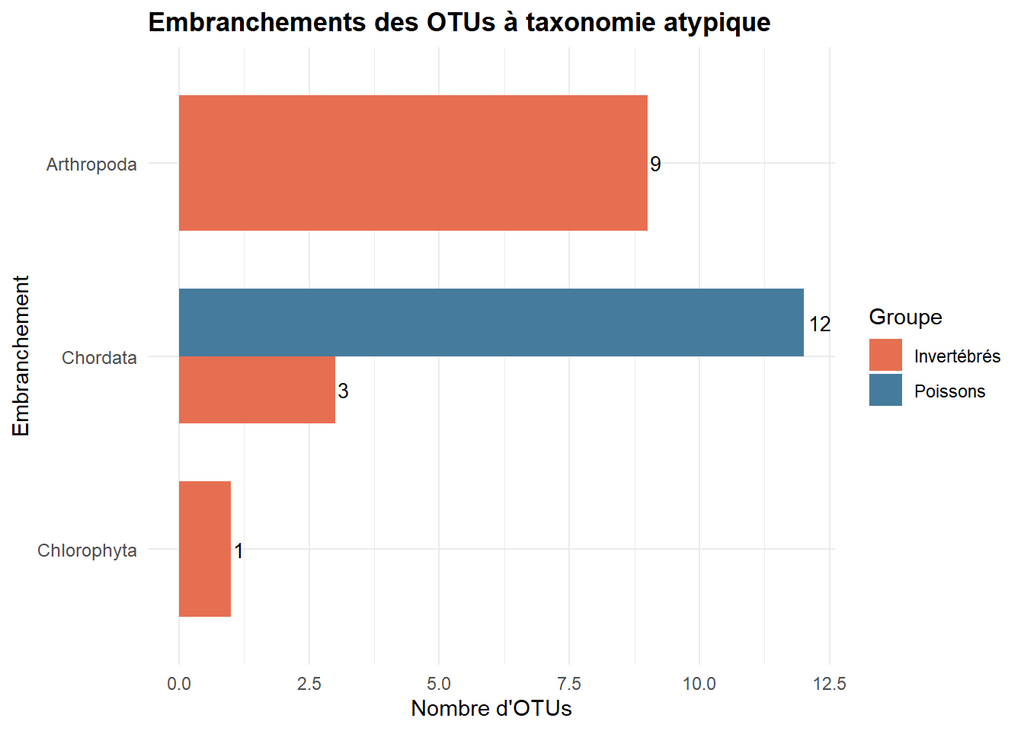

```r
## Visualisation

ggplot2::ggplot(
  distribution_embranchements_46,
  ggplot2::aes(
    x = reorder(Embranchement, Nombre_OTUs),
    y = Nombre_OTUs,
    fill = Groupe
  )
) +
  ggplot2::geom_col(
    position = "dodge",
    width = 0.7
  ) +
  ggplot2::geom_text(
    ggplot2::aes(label = Nombre_OTUs),
    position = ggplot2::position_dodge(width = 0.7),
    hjust = -0.2,
    size = 3.5
  ) +
  ggplot2::coord_flip() +
  ggplot2::scale_fill_manual(
    values = c(
      "Invertébrés" = "#E76F51",
      "Poissons" = "#457B9D"
    )
  ) +
  ggplot2::labs(
    title = "Embranchements des OTUs à taxonomie atypique",
    x = "Embranchement",
    y = "Nombre d'OTUs",
    fill = "Groupe"
  ) +
  ggplot2::theme_minimal() +
  ggplot2::theme(
    plot.title = ggplot2::element_text(face = "bold"),
    axis.text.y = ggplot2::element_text(size = 9)
  )
```

```r
options(na.print = "NA")
getOption("na.print")
```

```
## [1] "NA"
```

### 5.3.11 Distribution des genres des OTUs à taxonomie atypique

Examiner les genres associés à ces OTUs atypiques afin de préciser les groupes taxonomiques concernés.

**Interprétation**

Chez les invertébrés (13 OTUs) : - Bosmina représente 9 OTUs, soit 69,2 %. Ce genre appartient aux crustacés planctoniques (famille des Bosminidae) et son attribution est cohérente avec le groupe des invertébrés. - Bos, Felis et Ondatra représentent chacun un OTU (7,7 %). Ces genres correspondent respectivement à des mammifères : bovins, félins et rats musqués. Leurs annotations sont inattendues dans une analyse ciblant les invertébrés. - Lobosphaera représente un OTU (7,69 %) et appartient aux algues vertes (Chlorophyta). Chez les poissons (12 OTUs) : - Bos représente 10 OTUs, soit 83,3 %. - Homo représente 2 OTUs, soit 16,7 %. Les 12 OTUs sont donc attribués à des mammifères et non à des poissons. Cette situation constitue une anomalie taxonomique importante à examiner.

**Conclusion** La distribution des genres montre que les annotations atypiques sont principalement concentrées autour de Bosmina chez les invertébrés et de Bos chez les poissons.

Chez les invertébrés, la majorité des annotations restent compatibles avec le groupe étudié, malgré la présence de quelques genres inattendus. Chez les poissons, les annotations sont exclusivement associées à deux genres de mammifères (Bos et Homo).

Ces résultats renforcent la nécessité de vérifier les séquences des OTUs concernés, notamment leur similarité avec les séquences de référence et leur niveau de confiance taxonomique. L’absence de détection dans les contrôles ne permet pas, à elle seule, de confirmer leur identification.

```r
## 46.4. Distribution des genres des OTUs à taxonomie atypique
##Examiner les genres associés à ces OTUs atypiques afin de préciser les groupes taxonomiques concernés.

distribution_genres_46 <- taxonomies_a_verifier_46 %>%
  dplyr::filter(!is.na(Genre)) %>%
  dplyr::count(Groupe, Genre, name = "Nombre_OTUs") %>%
  dplyr::group_by(Groupe) %>%
  dplyr::mutate(
    Pourcentage = Nombre_OTUs / sum(Nombre_OTUs) * 100,
    Etiquette = paste0(
      Nombre_OTUs, " OTUs (",
      round(Pourcentage, 1), " %)"
    )
  ) %>%
  dplyr::ungroup()

## Affichage du tableau
print(as.data.frame(distribution_genres_46), row.names = FALSE)
```

```
##       Groupe       Genre Nombre_OTUs Pourcentage        Etiquette
##  Invertébrés         Bos           1    7.692308   1 OTUs (7.7 %)
##  Invertébrés     Bosmina           9   69.230769  9 OTUs (69.2 %)
##  Invertébrés       Felis           1    7.692308   1 OTUs (7.7 %)
##  Invertébrés Lobosphaera           1    7.692308   1 OTUs (7.7 %)
##  Invertébrés     Ondatra           1    7.692308   1 OTUs (7.7 %)
##     Poissons         Bos          10   83.333333 10 OTUs (83.3 %)
##     Poissons        Homo           2   16.666667  2 OTUs (16.7 %)
```

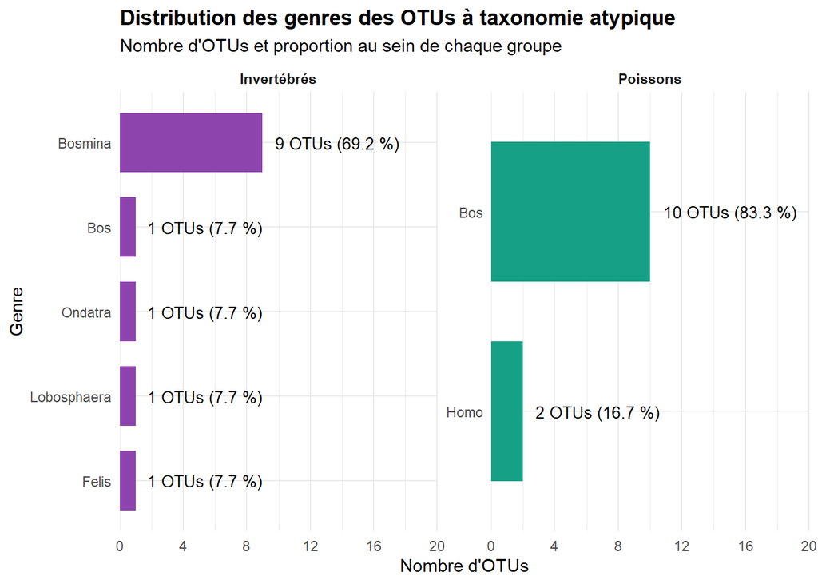

```r
## Graphique
ggplot2::ggplot(
  distribution_genres_46,
  ggplot2::aes(
    x = reorder(Genre, Nombre_OTUs),
    y = Nombre_OTUs,
    fill = Groupe
  )
) +
  ggplot2::geom_col(width = 0.7) +
  ggplot2::geom_text(
    ggplot2::aes(label = Etiquette),
    hjust = -0.1,
    size = 3.5
  ) +
  ggplot2::coord_flip() +
  ggplot2::facet_wrap(~ Groupe, scales = "free_y") +
  ggplot2::scale_fill_manual(
    values = c(
      "Invertébrés" = "#8E44AD",
      "Poissons" = "#16A085"
    )
  ) +
  ggplot2::scale_y_continuous(
    breaks = seq(0, 20, by = 4),
    limits = c(0, 20),
    expand = ggplot2::expansion(mult = c(0, 0))
  ) +
  ggplot2::labs(
    title = "Distribution des genres des OTUs à taxonomie atypique",
    subtitle = "Nombre d'OTUs et proportion au sein de chaque groupe",
    x = "Genre",
    y = "Nombre d'OTUs",
    fill = "Groupe"
  ) +
  ggplot2::theme_minimal() +
  ggplot2::theme(
    plot.title = ggplot2::element_text(face = "bold"),
    strip.text = ggplot2::element_text(face = "bold"),
    legend.position = "none"
  )
```

### 5.3.12 Fréquence de détection des OTUs atypiques

**Interprétation** Les résultats montrent une répartition assez similaire entre les deux groupes biologiques.

Chez les invertébrés (13 OTUs) : - *11 OTUs (84,6 %)* ont été détectés dans un seul échantillon biologique. - *2 OTUs (15,4 %)* ont été détectés dans plusieurs échantillons. Chez les poissons (12 OTUs) : - *10 OTUs (83,3 %)* ont été détectés dans un seul échantillon biologique. - *2 OTUs (16,7 %)* ont été détectés dans plusieurs échantillons. **Conclusion** La grande majorité des OTUs à taxonomie atypique présentent une fréquence de détection ponctuelle : environ 83 à 85 % ne sont retrouvés que dans un seul échantillon biologique. Seuls deux OTUs dans chaque groupe sont détectés dans plusieurs échantillons.

Cette faible récurrence constitue un élément à prendre en compte dans l’évaluation de ces OTUs. Toutefois, elle ne permet pas, à elle seule, de distinguer une véritable détection biologique d’une erreur d’assignation taxonomique ou d’un autre signal non ciblé.

```r
## 46.5. Fréquence de détection des OTUs atypiques

repartition_biologique_46 <- otu_atypiques_sans_controles_46 %>%
  dplyr::mutate(
    Frequence_detection = dplyr::case_when(
      N_echantillons_positifs_Biologique == 1 ~ "Un seul échantillon",
      N_echantillons_positifs_Biologique > 1 ~ "Plusieurs échantillons"
    )
  )

## Calcul des effectifs et pourcentages

resume_repartition_46 <- repartition_biologique_46 %>%
  dplyr::count(
    Groupe,
    Frequence_detection,
    name = "Nombre_OTUs"
  ) %>%
  tidyr::complete(
    Groupe,
    Frequence_detection = c(
      "Un seul échantillon",
      "Plusieurs échantillons"
    ),
    fill = list(Nombre_OTUs = 0)
  ) %>%
  dplyr::group_by(Groupe) %>%
  dplyr::mutate(
    Pourcentage = Nombre_OTUs / sum(Nombre_OTUs) * 100,
    Etiquette = paste0(
      Nombre_OTUs, " OTUs\n(",
      round(Pourcentage, 1), " %)"
    )
  ) %>%
  dplyr::ungroup()

## Affichage du tableau
print(as.data.frame(resume_repartition_46), row.names = FALSE)
```

```
##       Groupe    Frequence_detection Nombre_OTUs Pourcentage         Etiquette
##  Invertébrés Plusieurs échantillons           2    15.38462  2 OTUs\n(15.4 %)
##  Invertébrés    Un seul échantillon          11    84.61538 11 OTUs\n(84.6 %)
##     Poissons Plusieurs échantillons           2    16.66667  2 OTUs\n(16.7 %)
##     Poissons    Un seul échantillon          10    83.33333 10 OTUs\n(83.3 %)
```

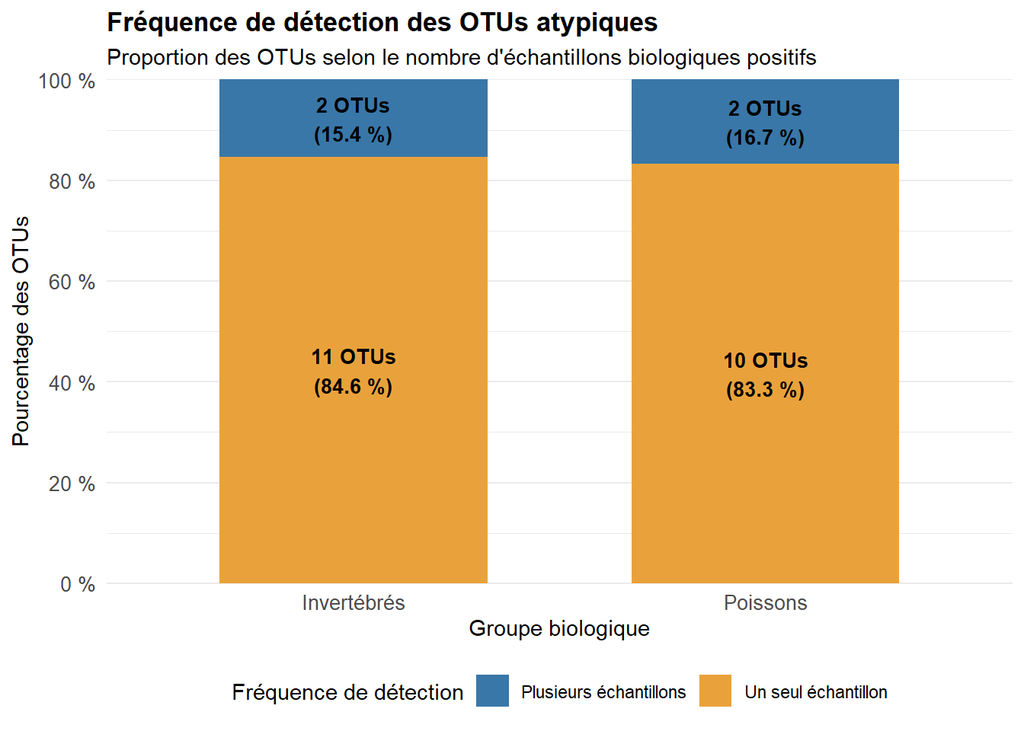

```r
## Graphique en barres empilées à 100 %

ggplot2::ggplot(
  resume_repartition_46,
  ggplot2::aes(
    x = Groupe,
    y = Pourcentage,
    fill = Frequence_detection
  )
) +
  ggplot2::geom_col(
    position = "stack",
    width = 0.65
  ) +
  ggplot2::geom_text(
    ggplot2::aes(label = Etiquette),
    position = ggplot2::position_stack(vjust = 0.5),
    size = 3.5,
    fontface = "bold"
  ) +
  ggplot2::scale_fill_manual(
    values = c(
      "Un seul échantillon" = "#E9A23B",
      "Plusieurs échantillons" = "#3977A8"
    )
  ) +
  ggplot2::scale_y_continuous(
    breaks = seq(0, 100, by = 20),
    limits = c(0, 100),
    labels = function(x) paste0(x, " %"),
    expand = c(0, 0)
  ) +
  ggplot2::labs(
    title = "Fréquence de détection des OTUs atypiques",
    subtitle = "Proportion des OTUs selon le nombre d'échantillons biologiques positifs",
    x = "Groupe biologique",
    y = "Pourcentage des OTUs",
    fill = "Fréquence de détection"
  ) +
  ggplot2::theme_minimal() +
  ggplot2::theme(
    plot.title = ggplot2::element_text(face = "bold"),
    axis.text = ggplot2::element_text(size = 10),
    legend.position = "bottom"
  )
```

### 5.3.13 Analyse des OTUs atypiques les plus abondants en lectures

Il s’agit identifier les OTUs qui concentrent le plus grand nombre de lectures afin de déterminer lesquels méritent une vérification prioritaire.

**Interprétation** Les résultats mettent en évidence des différences importantes entre les deux groupes.

**1. Chez les invertébrés**

Les 10 OTUs présentant le plus de lectures sont principalement associés à deux groupes taxonomiques : - Le genre Bosmina (Arthropoda, Branchiopoda) représente 8 des 10 OTUs. - Les genres Bos et Ondatra, appartenant aux mammifères, représentent les 2 autres OTUs. Les OTUs 1301 et 1330 présentent respectivement 343 et 335 lectures. L’OTU 1330 est détecté dans 3 échantillons biologiques, tandis que l’OTU 1301 est détecté dans 2 échantillons.

**2. Chez les poissons**

Les 10 OTUs les plus représentés sont tous annotés comme des mammifères : - Le genre Bos représente 8 OTUs. - Le genre Homo représente 2 OTUs. Les OTUs 21 et 33 présentent les nombres de lectures les plus élevés, avec respectivement 62 040 et 22 788 lectures. Cependant, chacun n’est détecté que dans un seul échantillon biologique.

Les deux OTUs associés au genre Homo (291 et 296) présentent respectivement 16 et 12 lectures et sont détectés dans 2 échantillons chacun.

De ce qui précède,l’analyse a révélé que certains OTUs atypiques présentent des nombres de lectures relativement élevés, particulièrement chez les poissons, où les OTUs 21 et 33 concentrent une grande partie des lectures associées aux annotations du genre Bos.

Chez les invertébrés, les OTUs associés au genre Bosmina sont majoritaires parmi les OTUs examinés, ce qui est cohérent avec le groupe biologique étudié. En revanche, les annotations correspondant aux mammifères nécessitent une attention particulière. Il est important de rappeler que le nombre de lectures ne correspond pas directement à l’abondance des organismes. De plus, une détection dans un seul échantillon ne suffit pas à invalider une séquence.

```r
## 46.6. OTUs atypiques ayant le plus grand nombre de lectures

top_otus_46 <- otu_atypiques_sans_controles_46 %>%
  dplyr::group_by(Groupe) %>%
  dplyr::slice_max(
    order_by = Total_lectures_Biologique,
    n = 10,
    with_ties = FALSE
  ) %>%
  dplyr::ungroup() %>%
  dplyr::arrange(
    Groupe,
    dplyr::desc(Total_lectures_Biologique)
  )

print(as.data.frame(top_otus_46), row.names = FALSE)
```

```
##       Groupe  OTU
##  Invertébrés 1301
##  Invertébrés 1330
##  Invertébrés 1953
##  Invertébrés 2863
##  Invertébrés 3086
##  Invertébrés 3566
##  Invertébrés 3743
##  Invertébrés 3893
##  Invertébrés 3954
##  Invertébrés 4100
##     Poissons   21
##     Poissons   33
##     Poissons   57
##     Poissons  121
##     Poissons  143
##     Poissons  247
##     Poissons  282
##     Poissons  291
##     Poissons  296
##     Poissons  300
##                                                                             taxonomy
##              k__Eukaryota;p__Chordata;c__Mammalia;o__Artiodactyla;f__Bovidae;g__Bos;
##  k__Eukaryota;p__Arthropoda;c__Branchiopoda;o__Diplostraca;f__Bosminidae;g__Bosmina;
##  k__Eukaryota;p__Arthropoda;c__Branchiopoda;o__Diplostraca;f__Bosminidae;g__Bosmina;
##  k__Eukaryota;p__Arthropoda;c__Branchiopoda;o__Diplostraca;f__Bosminidae;g__Bosmina;
##           k__Eukaryota;p__Chordata;c__Mammalia;o__Rodentia;f__Cricetidae;g__Ondatra;
##  k__Eukaryota;p__Arthropoda;c__Branchiopoda;o__Diplostraca;f__Bosminidae;g__Bosmina;
##  k__Eukaryota;p__Arthropoda;c__Branchiopoda;o__Diplostraca;f__Bosminidae;g__Bosmina;
##  k__Eukaryota;p__Arthropoda;c__Branchiopoda;o__Diplostraca;f__Bosminidae;g__Bosmina;
##  k__Eukaryota;p__Arthropoda;c__Branchiopoda;o__Diplostraca;f__Bosminidae;g__Bosmina;
##  k__Eukaryota;p__Arthropoda;c__Branchiopoda;o__Diplostraca;f__Bosminidae;g__Bosmina;
##              k__Eukaryota;p__Chordata;c__Mammalia;o__Artiodactyla;f__Bovidae;g__Bos;
##              k__Eukaryota;p__Chordata;c__Mammalia;o__Artiodactyla;f__Bovidae;g__Bos;
##              k__Eukaryota;p__Chordata;c__Mammalia;o__Artiodactyla;f__Bovidae;g__Bos;
##              k__Eukaryota;p__Chordata;c__Mammalia;o__Artiodactyla;f__Bovidae;g__Bos;
##              k__Eukaryota;p__Chordata;c__Mammalia;o__Artiodactyla;f__Bovidae;g__Bos;
##              k__Eukaryota;p__Chordata;c__Mammalia;o__Artiodactyla;f__Bovidae;g__Bos;
##              k__Eukaryota;p__Chordata;c__Mammalia;o__Artiodactyla;f__Bovidae;g__Bos;
##               k__Eukaryota;p__Chordata;c__Mammalia;o__Primates;f__Hominidae;g__Homo;
```

[output cut: 8 more lines]

```
##                         68                                  1
##                         61                                  1
##                         56                                  1
##                         54                                  1
##                         49                                  1
##                      62040                                  1
##                      22788                                  1
##                       2048                                  1
##                        645                                  1
##                        513                                  1
##                        110                                  1
##                         34                                  1
##                         16                                  2
##                         12                                  2
##                         10                                  1
```

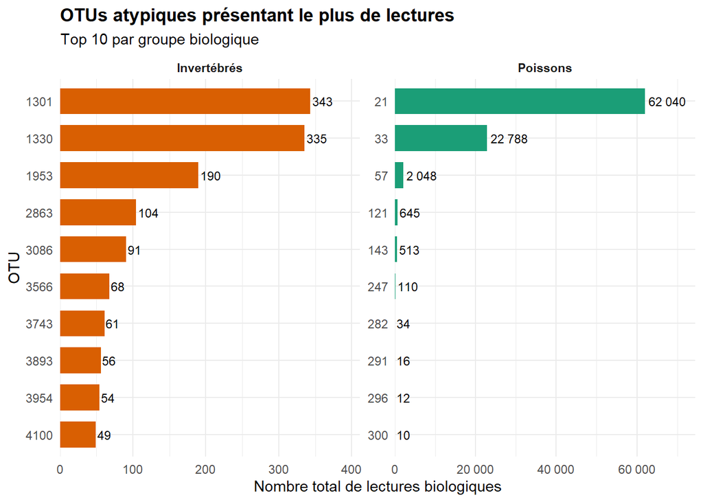

```r
## Graphique des 10 OTUs les plus représentés en lectures

ggplot2::ggplot(
  top_otus_46,
  ggplot2::aes(
    x = reorder(OTU, Total_lectures_Biologique),
    y = Total_lectures_Biologique,
    fill = Groupe
  )
) +
  ggplot2::geom_col(width = 0.7) +
  ggplot2::geom_text(
    ggplot2::aes(
      label = scales::label_number(big.mark = " ")(Total_lectures_Biologique)
    ),
    hjust = -0.1,
    size = 3
  ) +
  ggplot2::coord_flip() +
  ggplot2::facet_wrap(~ Groupe, scales = "free") +
  ggplot2::scale_fill_manual(
    values = c(
      "Invertébrés" = "#D95F02",
      "Poissons" = "#1B9E77"
    )
  ) +
  ggplot2::scale_y_continuous(
    labels = scales::label_number(big.mark = " "),
    expand = ggplot2::expansion(mult = c(0, 0.2))
  ) +
  ggplot2::labs(
    title = "OTUs atypiques présentant le plus de lectures",
    subtitle = "Top 10 par groupe biologique",
    x = "OTU",
    y = "Nombre total de lectures biologiques"
  ) +
  ggplot2::theme_minimal() +
  ggplot2::theme(
    plot.title = ggplot2::element_text(face = "bold"),
    strip.text = ggplot2::element_text(face = "bold"),
    legend.position = "none"
  )
```

### 5.3.14 Synthèse graphique des OTUs atypiques

**Préparation du tableau de synthèse**

```r
## 46.7. Synthèse des OTUs atypiques

synthese_otus_46 <- otu_atypiques_sans_controles_46 %>%
  dplyr::mutate(
    Frequence_detection = dplyr::case_when(
      N_echantillons_positifs_Biologique == 1 ~ "Un seul échantillon",
      N_echantillons_positifs_Biologique > 1 ~ "Plusieurs échantillons"
    ),
    Genre = vapply(
      strsplit(as.character(taxonomy), ";", fixed = TRUE),
      function(x) {
        genre <- x[startsWith(x, "g__")]
        if (length(genre) == 0) return(NA_character_)
        sub("^g__", "", genre[1])
      },
      character(1)
    )
  ) %>%
  dplyr::select(
    Groupe,
    OTU,
    Genre,
    Total_lectures_Biologique,
    N_echantillons_positifs_Biologique,
    Frequence_detection
  ) %>%
  dplyr::arrange(
    Groupe,
    dplyr::desc(Total_lectures_Biologique)
  )

print(as.data.frame(synthese_otus_46), row.names = FALSE)
```

```
##       Groupe  OTU       Genre Total_lectures_Biologique
##  Invertébrés 1301         Bos                       343
##  Invertébrés 1330     Bosmina                       335
##  Invertébrés 1953     Bosmina                       190
##  Invertébrés 2863     Bosmina                       104
##  Invertébrés 3086     Ondatra                        91
##  Invertébrés 3566     Bosmina                        68
##  Invertébrés 3743     Bosmina                        61
##  Invertébrés 3893     Bosmina                        56
##  Invertébrés 3954     Bosmina                        54
##  Invertébrés 4100     Bosmina                        49
##  Invertébrés 4232     Bosmina                        46
##  Invertébrés 6692       Felis                        10
##  Invertébrés 6927 Lobosphaera                         9
##     Poissons   21         Bos                     62040
##     Poissons   33         Bos                     22788
##     Poissons   57         Bos                      2048
##     Poissons  121         Bos                       645
##     Poissons  143         Bos                       513
##     Poissons  247         Bos                       110
##     Poissons  282         Bos                        34
##     Poissons  291        Homo                        16
##     Poissons  296        Homo                        12
##     Poissons  300         Bos                        10
##     Poissons  301         Bos                         9
##     Poissons  304         Bos                         8
##  N_echantillons_positifs_Biologique    Frequence_detection
##                                   2 Plusieurs échantillons
##                                   3 Plusieurs échantillons
##                                   1    Un seul échantillon
##                                   1    Un seul échantillon
##                                   1    Un seul échantillon
##                                   1    Un seul échantillon
##                                   1    Un seul échantillon
##                                   1    Un seul échantillon
##                                   1    Un seul échantillon
##                                   1    Un seul échantillon
##                                   1    Un seul échantillon
##                                   1    Un seul échantillon
##                                   1    Un seul échantillon
##                                   1    Un seul échantillon
##                                   1    Un seul échantillon
##                                   1    Un seul échantillon
##                                   1    Un seul échantillon
##                                   1    Un seul échantillon
##                                   1    Un seul échantillon
##                                   1    Un seul échantillon
##                                   2 Plusieurs échantillons
##                                   2 Plusieurs échantillons
##                                   1    Un seul échantillon
##                                   1    Un seul échantillon
##                                   1    Un seul échantillon
```

### 5.3.15 Graphique des OTUs selon le nombre de lectures

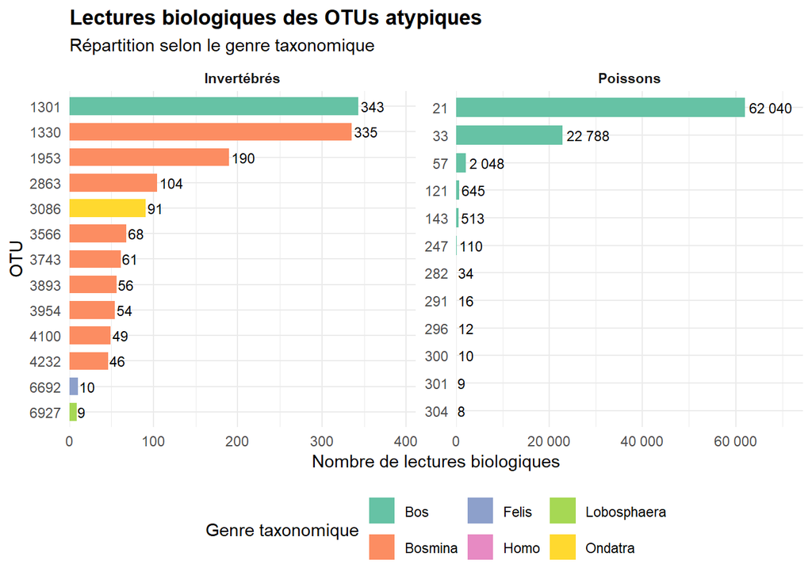

```r
ggplot2::ggplot(
  synthese_otus_46,
  ggplot2::aes(
    x = reorder(OTU, Total_lectures_Biologique),
    y = Total_lectures_Biologique,
    fill = Genre
  )
) +
  ggplot2::geom_col(width = 0.7) +
  ggplot2::geom_text(
    ggplot2::aes(
      label = scales::label_number(big.mark = " ")(
        Total_lectures_Biologique
      )
    ),
    hjust = -0.1,
    size = 3
  ) +
  ggplot2::coord_flip() +
  ggplot2::facet_wrap(~ Groupe, scales = "free") +
  ggplot2::scale_fill_brewer(palette = "Set2") +
  ggplot2::scale_y_continuous(
    labels = scales::label_number(big.mark = " "),
    expand = ggplot2::expansion(mult = c(0, 0.2))
  ) +
  ggplot2::labs(
    title = "Lectures biologiques des OTUs atypiques",
    subtitle = "Répartition selon le genre taxonomique",
    x = "OTU",
    y = "Nombre de lectures biologiques",
    fill = "Genre taxonomique"
  ) +
  ggplot2::theme_minimal() +
  ggplot2::theme(
    plot.title = ggplot2::element_text(face = "bold"),
    strip.text = ggplot2::element_text(face = "bold"),
    legend.position = "bottom"
  )
```

### 5.3.16 Graphique de la fréquence de détection

Certains OTUs présentent des nombres de lectures élevés malgré une détection limitée à un seul échantillon. Ces observations justifient une vérification approfondie des séquences, particulièrement pour les OTUs associés aux mammifères.

**Répartition spatiale des OTUs atypiques absents des contrôles.**

L’objectif est de repérer les sites où ces OTUs ont été détectés, séparément pour les invertébrés et les poissons. Nous utiliserons les coordonnées GPS déjà présentes dans mapping_invertebres et mapping_poissons, sans géocodage.

Comme les OTUs sélectionnés au bloc 46 sont déjà absents des blancs, nous allons rechercher leurs détections positives dans les échantillons, puis les relier aux coordonnées des sites.

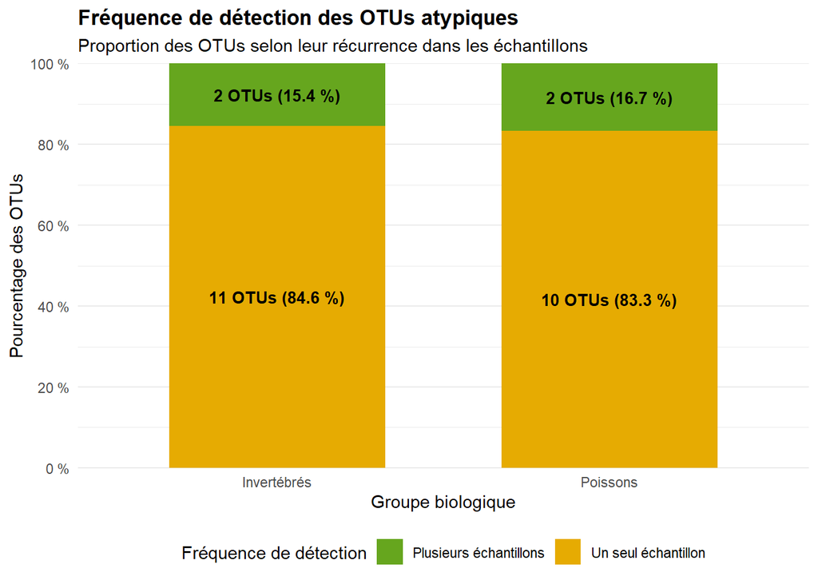

```r
resume_synthese_46 <- synthese_otus_46 %>%
  dplyr::count(
    Groupe,
    Frequence_detection,
    name = "Nombre_OTUs"
  ) %>%
  tidyr::complete(
    Groupe,
    Frequence_detection = c(
      "Un seul échantillon",
      "Plusieurs échantillons"
    ),
    fill = list(Nombre_OTUs = 0)
  ) %>%
  dplyr::group_by(Groupe) %>%
  dplyr::mutate(
    Pourcentage = Nombre_OTUs / sum(Nombre_OTUs) * 100,
    Etiquette = paste0(
      Nombre_OTUs, " OTUs (",
      round(Pourcentage, 1), " %)"
    )
  ) %>%
  dplyr::ungroup()

ggplot2::ggplot(
  resume_synthese_46,
  ggplot2::aes(
    x = Groupe,
    y = Pourcentage,
    fill = Frequence_detection
  )
) +
  ggplot2::geom_col(width = 0.65) +
  ggplot2::geom_text(
    ggplot2::aes(label = Etiquette),
    position = ggplot2::position_stack(vjust = 0.5),
    size = 3.5,
    fontface = "bold"
  ) +
  ggplot2::scale_fill_manual(
    values = c(
      "Un seul échantillon" = "#E6AB02",
      "Plusieurs échantillons" = "#66A61E"
    )
  ) +
  ggplot2::scale_y_continuous(
    breaks = seq(0, 100, 20),
    limits = c(0, 100),
    labels = function(x) paste0(x, " %"),
    expand = c(0, 0)
  ) +
  ggplot2::labs(
    title = "Fréquence de détection des OTUs atypiques",
    subtitle = "Proportion des OTUs selon leur récurrence dans les échantillons",
    x = "Groupe biologique",
    y = "Pourcentage des OTUs",
    fill = "Fréquence de détection"
  ) +
  ggplot2::theme_minimal() +
  ggplot2::theme(
    plot.title = ggplot2::element_text(face = "bold"),
    legend.position = "bottom"
  )
```

### 5.3.17 Extraire les détections positives et les relier aux coordonnées GPS

**Interprétation**

Le tableau présente 30 détections d’OTUs atypiques : 16 chez les invertébrés et 14 chez les poissons. Chez les invertébrés Les détections sont réparties entre plusieurs sites. On observe notamment : - Amont du barrage : cinq OTUs détectés (2863, 3566, 3743, 3893 et 3954), avec 343 lectures au total. - Les Écluses : deux OTUs détectés (1330 et 4100), avec 286 lectures. - Vieux-Port, le pont : l’OTU 1953, avec 190 lectures. - Héron Bleu : l’OTU 1301, avec 175 lectures. L’OTU 1330 est détecté à plusieurs sites, notamment au Parc Martel, aux Écluses et au Parc Paul-Leveille. L’OTU 1301 est également détecté à deux sites : Héron Bleu et Parc Marcel-Seers. Chez les poissons Les détections sont davantage concentrées sur certains sites : - Parc de la Fabrique : six OTUs détectés (121, 143, 57, 21, 33 et 282), représentant 88 068 lectures. - Parc Marcel-Seers : l’OTU 247, avec 110 lectures. - Les autres sites : quelques détections isolées, notamment les OTUs 291, 296, 300, 301 et 304. Le Parc de la Fabrique présente donc une concentration importante de lectures associées aux OTUs atypiques chez les poissons. Cette observation mérite une attention particulière, notamment parce que les OTUs concernés sont majoritairement assignés au genre Bos.

Point de vigilance : les nombres de lectures ne représentent pas directement l’abondance des organismes. La concentration observée au Parc de la Fabrique ne permet donc pas de conclure à une présence ou à une abondance élevée de bovins sur ce site.

**Vérifier la répartition des détections par site**

Ce tableau permettra de savoir combien d’OTUs atypiques ont été détectés sur chaque site et dans combien d’échantillons.

```r
## 47.1. Préparation des détections des OTUs atypiques

# OTUs atypiques à examiner chez les invertébrés
otus_cibles_invertebres_47 <- otu_atypiques_sans_controles_46 %>%
  dplyr::filter(Groupe == "Invertébrés") %>%
  dplyr::pull(OTU) %>%
  as.character()

# OTUs atypiques à examiner chez les poissons
otus_cibles_poissons_47 <- otu_atypiques_sans_controles_46 %>%
  dplyr::filter(Groupe == "Poissons") %>%
  dplyr::pull(OTU) %>%
  as.character()


# Fonction pour extraire les détections positives et les coordonnées
extraire_detections_gps_47 <- function(matrice, mapping, otus, groupe) {

  detections <- matrice %>%
    dplyr::filter(as.character(`#FEATURE_ID`) %in% otus) %>%
    tidyr::pivot_longer(
      cols = -c(`#FEATURE_ID`, taxonomy),
      names_to = "SampleID",
      values_to = "Lectures"
    ) %>%
    dplyr::mutate(
      OTU = as.character(`#FEATURE_ID`),
      Lectures = as.numeric(as.character(Lectures)),
      Groupe = groupe
    ) %>%
    dplyr::filter(Lectures > 0) %>%
    dplyr::select(Groupe, OTU, SampleID, Lectures) %>%
    dplyr::inner_join(mapping, by = "SampleID") %>%
    dplyr::mutate(
      Longitude = as.numeric(gsub(",", ".", as.character(`Longitude(X)`))),
      Latitude = as.numeric(gsub(",", ".", as.character(`Latitude(Y)`)))
    )

  return(detections)
}


# Détections des invertébrés
detections_invertebres_47 <- extraire_detections_gps_47(
  matrice = data_invertebres,
  mapping = mapping_invertebres,
  otus = otus_cibles_invertebres_47,
  groupe = "Invertébrés"
)

# Détections des poissons
detections_poissons_47 <- extraire_detections_gps_47(
  matrice = data_poissons,
  mapping = mapping_poissons,
  otus = otus_cibles_poissons_47,
  groupe = "Poissons"
)

# Regrouper les deux groupes
detections_gps_47 <- dplyr::bind_rows(
  detections_invertebres_47,
  detections_poissons_47
)

# Vérifier les résultats
print(detections_gps_47, n = Inf)
```

```
## # A tibble: 30 × 20
##    Groupe OTU   SampleID Lectures `#SampleID` alias CoursEau SiteEchantillonnage
##    <chr>  <chr> <chr>       <dbl> <chr>       <chr> <chr>    <chr>
##  1 Inver… 1301  MI.M058…      175 MI.M05812_… 5.3.… Riviere… Heron.Bleu
##  2 Inver… 1301  MI.M058…      168 MI.M05812_… 8.1.… Riviere… Parc.Marcel.Seers
##  3 Inver… 1330  MI.M058…      237 MI.M05812_… 2.1.… Bassin.… Les.ecluses
##  4 Inver… 1330  MI.M058…       57 MI.M05812_… 2.3.… Bassin.… Le.Parc.Martel
##  5 Inver… 1330  MI.M058…       41 MI.M05812_… 13.2… Riviere… Parc.Paul-Leveille
##  6 Inver… 1953  MI.M058…      190 MI.M05812_… 4.2.… Fleuve.… Vieux-Port,.le.pont
##  7 Inver… 2863  MI.M058…      104 MI.M05812_… 10.2… Riviere… Amont.du.barrage
##  8 Inver… 3086  MI.M058…       91 MI.M05812_… 12.1… Riviere… Berge.des.Baigneurs
##  9 Inver… 3566  MI.M058…       68 MI.M05812_… 10.2… Riviere… Amont.du.barrage
## 10 Inver… 3743  MI.M058…       61 MI.M05812_… 10.2… Riviere… Amont.du.barrage
## 11 Inver… 3893  MI.M058…       56 MI.M05812_… 10.2… Riviere… Amont.du.barrage
## 12 Inver… 3954  MI.M058…       54 MI.M05812_… 10.2… Riviere… Amont.du.barrage
```

[output cut: 22 more lines]

*Interprétation du bloc 47.2 : synthèse par site* Le tableau agrège les détections par groupe biologique et par site. Principales observations Groupe Site Nombre d’OTUs Lectures Invertébrés Amont du barrage 5 343 Invertébrés Les Écluses 2 286 Invertébrés Héron Bleu 1 175 Invertébrés Vieux-Port, le pont 1 190 Poissons Parc de la Fabrique 6 88 068 Poissons Parc Marcel-Seers 1 110

Chez les invertébrés, l’Amont du barrage présente le plus grand nombre d’OTUs atypiques, avec cinq OTUs. Les Écluses arrivent ensuite avec deux OTUs.

Chez les poissons, le Parc de la Fabrique se distingue nettement avec six OTUs et 88 068 lectures. Les autres sites présentent généralement un seul OTU atypique.

Il faut toutefois noter que le nombre d’échantillons indiqué est égal à 1 pour chaque site dans ce tableau. Les résultats ne permettent donc pas de réaliser des comparaisons statistiques solides entre les sites. Ils décrivent uniquement les observations obtenues dans les échantillons disponibles.

*Vérification complémentaire* : les OTUs retenus précédemment sont censés être absents des contrôles. Vérifions que les détections obtenues ici correspondent bien à des échantillons biologiques.

```r
## 47.2. Synthèse des détections par site

resume_sites_47 <- detections_gps_47 %>%
  dplyr::filter(
    !is.na(Longitude),
    !is.na(Latitude)
  ) %>%
  dplyr::group_by(
    Groupe,
    SiteEchantillonnage,
    Longitude,
    Latitude
  ) %>%
  dplyr::summarise(
    Nombre_OTUs = dplyr::n_distinct(OTU),
    Nombre_echantillons = dplyr::n_distinct(SampleID),
    Total_lectures = sum(Lectures, na.rm = TRUE),
    Liste_OTUs = paste(sort(unique(OTU)), collapse = ", "),
    .groups = "drop"
  ) %>%
  dplyr::arrange(Groupe, SiteEchantillonnage)

print(resume_sites_47, n = Inf)
```

```
## # A tibble: 20 × 8
##    Groupe SiteEchantillonnage Longitude Latitude Nombre_OTUs Nombre_echantillons
##    <chr>  <chr>                   <dbl>    <dbl>       <int>               <int>
##  1 Inver… Amont.du.barrage        -75.7     45.4           5                   1
##  2 Inver… Aval.du.barrage         -75.7     45.4           1                   1
##  3 Inver… Berge.des.Baigneurs     -73.8     45.6           1                   1
##  4 Inver… Heron.Bleu              -73.8     45.6           1                   1
##  5 Inver… Le.Parc.Martel          -73.3     45.4           1                   1
##  6 Inver… Les.ecluses             -73.3     45.4           2                   1
##  7 Inver… Parc.Andre.J..Cote      -73.5     45.4           1                   1
##  8 Inver… Parc.Marcel.Seers       -73.8     45.4           1                   1
##  9 Inver… Parc.Paul-Leveille      -73.8     45.2           1                   1
## 10 Inver… Parc.de.la.Fabrique     -73.8     45.6           1                   1
## 11 Inver… Vieux-Port,.le.pont     -73.5     45.5           1                   1
## 12 Poiss… Berge.des.Baigneurs     -73.8     45.6           1                   1
## 13 Poiss… Le.pont.du.Chemin.…     -73.8     45.4           1                   1
## 14 Poiss… Les.ecluses             -73.3     45.4           1                   1
## 15 Poiss… Montee.Robert           -73.3     45.5           1                   1
## 16 Poiss… Parc.Andre.J..Cote      -73.5     45.4           1                   1
## 17 Poiss… Parc.Charbonneau        -73.8     45.6           1                   1
## 18 Poiss… Parc.Marcel.Seers       -73.8     45.4           1                   1
## 19 Poiss… Parc.de.Ile.Belair      -73.8     45.6           1                   1
## 20 Poiss… Parc.de.la.Fabrique     -73.8     45.6           6                   1
## # ℹ 2 more variables: Total_lectures <dbl>, Liste_OTUs <chr>
```

### 5.3.18 Analyse de la répartition spatiale des OTUs présentant une taxonomie atypique

**Interprétation**

La vérification confirme que les 30 détections proviennent d’échantillons portant la mention Biologique dans la colonne TypeEchantillon.

Cela est cohérent avec le choix initial d’étudier les OTUs atypiques absents des blancs de terrain et des blancs d’extraction.

On peut donc retenir que : - Les détections présentées concernent des échantillons biologiques. - Les OTUs atypiques ne sont pas signalés dans les contrôles négatifs examinés. - Leur présence dans les échantillons biologiques ne suffit toutefois pas à confirmer leur identification taxonomique. - Une vérification des séquences et de leur correspondance avec les bases de référence demeure nécessaire.

L’analyse spatiale des OTUs présentant une taxonomie atypique et absents des contrôles négatifs a permis d’identifier 30 détections dans les échantillons biologiques, dont 16 associées au groupe des invertébrés et 14 au groupe des poissons.

Chez les invertébrés, les détections sont réparties entre plusieurs sites d’échantillonnage. Le site Amont du barrage présente le plus grand nombre d’OTUs atypiques, avec cinq OTUs totalisant 343 lectures. Le site Les Écluses compte deux OTUs, tandis que les autres sites présentent généralement une seule détection. L’OTU 1330, assigné au genre Bosmina, est notamment observé dans plusieurs sites.

Chez les poissons, les détections sont principalement marquées au Parc de la Fabrique, où six OTUs atypiques ont été identifiés, totalisant 88 068 lectures. Ces OTUs sont majoritairement assignés au genre Bos. Les autres sites présentent des détections plus ponctuelles, généralement limitées à un seul OTU.

La vérification des métadonnées confirme que les détections recensées proviennent d’échantillons biologiques. Toutefois, ces observations doivent être interprétées avec prudence. Les OTUs concernés ne sont pas détectés dans les contrôles négatifs examinés, mais cette absence ne garantit pas à elle seule la fiabilité de leur assignation taxonomique. De plus, les nombres de lectures ne constituent pas une mesure directe de l’abondance des organismes.

Enfin, puisque les sites sont généralement représentés par un seul échantillon, cette répartition doit être considérée comme descriptive. Une vérification complémentaire des séquences et des assignations taxonomiques sera nécessaire avant de tirer des conclusions écologiques sur la présence éventuelle de ces organismes.

```r
## Vérification du type d'échantillon

detections_gps_47 %>%
  dplyr::count(
    Groupe,
    TypeEchantillon,
    Treatment,
    name = "Nombre_detections"
  ) %>%
  print(n = Inf)
```

```
## # A tibble: 20 × 4
##    Groupe      TypeEchantillon Treatment                       Nombre_detections
##    <chr>       <chr>           <chr>                                       <int>
##  1 Invertébrés Biologique      College.Charles-Lemoyne_Fleuve…                 1
##  2 Invertébrés Biologique      College.Heritage_Riviere.Chate…                 1
##  3 Invertébrés Biologique      College.Ville-Marie_Fleuve.St-…                 1
##  4 Invertébrés Biologique      Ecole.Sainte-Martine_Riviere.C…                 1
##  5 Invertébrés Biologique      Ecole.polyvalente.Lavigne_Rivi…                 5
##  6 Invertébrés Biologique      Ecole.polyvalente.Lavigne_Rivi…                 1
##  7 Invertébrés Biologique      Ecole.secondaire.Cure-Labelle_…                 1
##  8 Invertébrés Biologique      Ecole.secondaire.Cure-Labelle_…                 1
##  9 Invertébrés Biologique      Ecole.secondaire.de.Chambly_Ba…                 1
## 10 Invertébrés Biologique      Ecole.secondaire.de.Chambly_Ba…                 2
## 11 Invertébrés Biologique      Polyvalente.Sainte-Therese_Riv…                 1
## 12 Poissons    Biologique      College.Charles-Lemoyne_Fleuve…                 1
## 13 Poissons    Biologique      College.Heritage_Riviere.Chate…                 1
## 14 Poissons    Biologique      College.Heritage_Riviere.Chate…                 1
## 15 Poissons    Biologique      Ecole.Secondaire.Andre-Laurend…                 1
## 16 Poissons    Biologique      Ecole.secondaire.Cure-Labelle_…                 1
## 17 Poissons    Biologique      Ecole.secondaire.Cure-Labelle_…                 6
## 18 Poissons    Biologique      Ecole.secondaire.Jean-Jacques-…                 1
## 19 Poissons    Biologique      Ecole.secondaire.Jean-Jacques-…                 1
## 20 Poissons    Biologique      Ecole.secondaire.de.Chambly_Ba…                 1
```

### 5.3.19 Préparation des données cartographiques

Les détections d’OTU atypiques ont été associées aux coordonnées GPS des échantillons. Cette préparation a permis de représenter leur répartition spatiale et d’identifier les sites concernés.

```r
## 47.3.1. Préparation des données pour les cartes

library(dplyr)
library(leaflet)

# Séparation des données par groupe biologique
carte_invertebres_47 <- resume_sites_47 %>%
  dplyr::filter(Groupe == "Invertébrés") %>%
  dplyr::mutate(
    Popup = paste0(
      "<b>Groupe :</b> ", Groupe, "<br>",
      "<b>Site :</b> ", SiteEchantillonnage, "<br>",
      "<b>Nombre d'OTUs :</b> ", Nombre_OTUs, "<br>",
      "<b>Nombre d'échantillons :</b> ", Nombre_echantillons, "<br>",
      "<b>Total de lectures :</b> ", Total_lectures, "<br>",
      "<b>OTUs détectés :</b> ", Liste_OTUs
    )
  )

carte_poissons_47 <- resume_sites_47 %>%
  dplyr::filter(Groupe == "Poissons") %>%
  dplyr::mutate(
    Popup = paste0(
      "<b>Groupe :</b> ", Groupe, "<br>",
      "<b>Site :</b> ", SiteEchantillonnage, "<br>",
      "<b>Nombre d'OTUs :</b> ", Nombre_OTUs, "<br>",
      "<b>Nombre d'échantillons :</b> ", Nombre_echantillons, "<br>",
      "<b>Total de lectures :</b> ", Total_lectures, "<br>",
      "<b>OTUs détectés :</b> ", Liste_OTUs
    )
  )

# Vérification des coordonnées
cat("Invertébrés :\n")
```

```
## Invertébrés :
```

```r
print(summary(carte_invertebres_47[, c("Longitude", "Latitude")]))
```

```
##    Longitude         Latitude
##  Min.   :-75.70   Min.   :45.24
##  1st Qu.:-73.80   1st Qu.:45.42
##  Median :-73.79   Median :45.45
##  Mean   :-74.00   Mean   :45.47
##  3rd Qu.:-73.54   3rd Qu.:45.56
##  Max.   :-73.28   Max.   :45.62
```

```r
cat("\nPoissons :\n")
```

```
##
## Poissons :
```

```r
print(summary(carte_poissons_47[, c("Longitude", "Latitude")]))
```

```
##    Longitude         Latitude
##  Min.   :-73.80   Min.   :45.37
##  1st Qu.:-73.79   1st Qu.:45.40
##  Median :-73.76   Median :45.51
##  Mean   :-73.64   Mean   :45.51
##  3rd Qu.:-73.53   3rd Qu.:45.62
##  Max.   :-73.25   Max.   :45.64
```

### 5.3.20 Carte des OTU atypiques chez les invertébrés

La cartographie a mis en évidence la présence d’OTU à annotations taxonomiques atypiques dans plusieurs secteurs d’échantillonnage. Ces observations ont justifié des vérifications complémentaires, sans permettre de confirmer une contamination ou une présence biologique réelle.

```r
## 47.3.2. Carte des OTUs atypiques chez les invertébrés
## Couleurs selon le nombre d'OTUs détectés

# Fonction de classification des couleurs
couleur_nombre_otus_47 <- function(n) {
  dplyr::case_when(
    n == 1 ~ "#2ECC71",
    n == 2 ~ "#F1C40F",
    n == 3 ~ "#E67E22",
    n >= 4 ~ "#E74C3C",
    TRUE ~ "#808080"
  )
}

# Attribution des couleurs
carte_invertebres_47 <- carte_invertebres_47 %>%
  dplyr::mutate(
    Couleur_OTUs = couleur_nombre_otus_47(Nombre_OTUs)
  )

# Création de la carte
carte_leaflet_invertebres_47 <- leaflet(
  carte_invertebres_47
) %>%
  addProviderTiles("OpenStreetMap") %>%
  addCircleMarkers(
    lng = ~Longitude,
    lat = ~Latitude,
    radius = ~6 + Nombre_OTUs * 1.5,
    color = ~Couleur_OTUs,
    fillColor = ~Couleur_OTUs,
    fillOpacity = 0.85,
    weight = 2,
    popup = ~Popup,
    label = ~paste(
      SiteEchantillonnage,
      "-",
      Nombre_OTUs,
      "OTUs"
    )
  ) %>%
  addLegend(
    position = "bottomright",
    colors = c("#2ECC71", "#F1C40F", "#E67E22", "#E74C3C"),
    labels = c("1 OTU", "2 OTUs", "3 OTUs", "4 OTUs ou plus"),
    title = "Nombre d'OTUs",
    opacity = 0.85
  )

carte_leaflet_invertebres_47
```

[interactive chart not shown]

### 5.3.21 Carte des poissons avec couleurs selon le nombre d’OTUs

**Information sur les cartes**

Ce que nous observons sur les 2 cartes : - Sur la carte des invertébrés, le site Amont du barrage apparaîtra en rouge, car il compte 5 OTUs. - Les Écluses apparaîtront en jaune avec 2 OTUs. - Sur la carte des poissons, le Parc de la Fabrique apparaîtra en rouge avec 6 OTUs. - Les sites avec un seul OTU seront en vert. La couleur et la taille des cercles donneront donc deux informations complémentaires : le nombre d’OTUs sera indiqué par les deux, tandis que la fenêtre contextuelle donnera le détail des OTUs et des lectures.

```r
## 47.3.3. Carte des OTUs atypiques chez les poissons
## Couleurs selon le nombre d'OTUs détectés

# Attribution des couleurs
carte_poissons_47 <- carte_poissons_47 %>%
  dplyr::mutate(
    Couleur_OTUs = couleur_nombre_otus_47(Nombre_OTUs)
  )

# Création de la carte
carte_leaflet_poissons_47 <- leaflet(
  carte_poissons_47
) %>%
  addProviderTiles("OpenStreetMap") %>%
  addCircleMarkers(
    lng = ~Longitude,
    lat = ~Latitude,
    radius = ~6 + Nombre_OTUs * 1.5,
    color = ~Couleur_OTUs,
    fillColor = ~Couleur_OTUs,
    fillOpacity = 0.85,
    weight = 2,
    popup = ~Popup,
    label = ~paste(
      SiteEchantillonnage,
      "-",
      Nombre_OTUs,
      "OTUs"
    )
  ) %>%
  addLegend(
    position = "bottomright",
    colors = c("#2ECC71", "#F1C40F", "#E67E22", "#E74C3C"),
    labels = c("1 OTU", "2 OTUs", "3 OTUs", "4 OTUs ou plus"),
    title = "Nombre d'OTUs",
    opacity = 0.85
  )

carte_leaflet_poissons_47
```

[interactive chart not shown]

### 5.3.22 Analyse de la distribution des OTUs atypiques selon les sites et les groupes biologiques.

Après l’analyse spatiale, l’objectif est de mieux caractériser les sites concernés : quels OTUs sont partagés entre plusieurs sites, lesquels sont propres à un seul site et quels sites présentent les profils de détection les plus particuliers ?

Cette étape a permis de compléter les cartes par une analyse descriptive des profils de détection, sans conclure à une présence certaine des organismes correspondant aux assignations taxonomiques.

### 5.3.23 Nombre de sites concernés par chaque OTU atypique

Nous allons d’abord déterminer si chaque OTU atypique est : - détecté dans un seul site ; - détecté dans plusieurs sites. Nous allons également récupérer le genre taxonomique attribué à chaque OTU pour faciliter l’interprétation.

**Interprétation : répartition des OTUs par site** Sur les 25 OTUs atypiques étudiés :

Chez les invertébrés (13 OTUs) - 11 OTUs sont détectés dans un seul site. - L’OTU 1330, assigné au genre Bosmina, est retrouvé dans trois sites : Parc Martel, Les Écluses et Parc Paul-Leveille. - L’OTU 1301, assigné au genre Bos, est détecté à Héron Bleu et au Parc Marcel-Seers. - Les autres OTUs présentent une distribution limitée à un seul site. Chez les poissons (12 OTUs) - 10 OTUs sont détectés dans un seul site. - L’OTU 291, assigné au genre Homo, est retrouvé au Parc André-J.-Côté et au Parc de l’Île Bélair. - L’OTU 296, également assigné au genre Homo, est détecté au pont du Chemin Saint-Bernard et au Parc Charbonneau. - Les dix autres OTUs sont détectés dans un seul site, notamment les six OTUs associés au genre Bos au Parc de la Fabrique.

**Observation importante** : les six OTUs associés au genre Bos au Parc de la Fabrique présentent un total de 88 068 lectures. Ce total correspond au cumul des lectures des six OTUs dans cet échantillon, et non à six observations indépendantes de présence de bovins.

```r
## 48.1. Répartition des OTUs atypiques selon le nombre de sites

# Transformer la liste des OTUs de chaque site en observations individuelles
otus_sites_48 <- resume_sites_47 %>%
  tidyr::separate_rows(Liste_OTUs, sep = ",\\s*") %>%
  dplyr::mutate(
    OTU = trimws(Liste_OTUs)
  ) %>%
  dplyr::select(
    Groupe,
    SiteEchantillonnage,
    OTU,
    Total_lectures
  )

# Calculer le nombre de sites dans lesquels chaque OTU est détecté
resume_otus_sites_48 <- otus_sites_48 %>%
  dplyr::group_by(Groupe, OTU) %>%
  dplyr::summarise(
    Nombre_sites = dplyr::n_distinct(SiteEchantillonnage),
    Liste_sites = paste(
      unique(SiteEchantillonnage),
      collapse = ", "
    ),
    Total_lectures = sum(Total_lectures),
    .groups = "drop"
  ) %>%
  dplyr::mutate(
    Repartition = dplyr::case_when(
      Nombre_sites == 1 ~ "Un seul site",
      Nombre_sites > 1 ~ "Plusieurs sites"
    )
  ) %>%
  dplyr::left_join(
    taxonomies_a_verifier_46 %>%
      dplyr::select(Groupe, OTU, Genre),
    by = c("Groupe", "OTU")
  ) %>%
  dplyr::arrange(
    Groupe,
    dplyr::desc(Nombre_sites),
    dplyr::desc(Total_lectures)
  )

print(resume_otus_sites_48, n = Inf)
```

```
## # A tibble: 25 × 7
##    Groupe      OTU   Nombre_sites Liste_sites   Total_lectures Repartition Genre
##    <chr>       <chr>        <int> <chr>                  <dbl> <chr>       <chr>
##  1 Invertébrés 1330             3 Le.Parc.Mart…            384 Plusieurs … Bosm…
##  2 Invertébrés 1301             2 Heron.Bleu, …            343 Plusieurs … Bos
##  3 Invertébrés 2863             1 Amont.du.bar…            343 Un seul si… Bosm…
##  4 Invertébrés 3566             1 Amont.du.bar…            343 Un seul si… Bosm…
##  5 Invertébrés 3743             1 Amont.du.bar…            343 Un seul si… Bosm…
##  6 Invertébrés 3893             1 Amont.du.bar…            343 Un seul si… Bosm…
##  7 Invertébrés 3954             1 Amont.du.bar…            343 Un seul si… Bosm…
##  8 Invertébrés 4100             1 Les.ecluses              286 Un seul si… Bosm…
##  9 Invertébrés 1953             1 Vieux-Port,.…            190 Un seul si… Bosm…
## 10 Invertébrés 3086             1 Berge.des.Ba…             91 Un seul si… Onda…
## 11 Invertébrés 4232             1 Parc.Andre.J…             46 Un seul si… Bosm…
## 12 Invertébrés 6692             1 Parc.de.la.F…             10 Un seul si… Felis
## 13 Invertébrés 6927             1 Aval.du.barr…              9 Un seul si… Lobo…
## 14 Poissons    291              2 Parc.Andre.J…             16 Plusieurs … Homo
## 15 Poissons    296              2 Le.pont.du.C…             12 Plusieurs … Homo
## 16 Poissons    121              1 Parc.de.la.F…          88068 Un seul si… Bos
## 17 Poissons    143              1 Parc.de.la.F…          88068 Un seul si… Bos
## 18 Poissons    21               1 Parc.de.la.F…          88068 Un seul si… Bos
## 19 Poissons    282              1 Parc.de.la.F…          88068 Un seul si… Bos
## 20 Poissons    33               1 Parc.de.la.F…          88068 Un seul si… Bos
## 21 Poissons    57               1 Parc.de.la.F…          88068 Un seul si… Bos
## 22 Poissons    247              1 Parc.Marcel.…            110 Un seul si… Bos
## 23 Poissons    300              1 Les.ecluses               10 Un seul si… Bos
## 24 Poissons    301              1 Montee.Robert              9 Un seul si… Bos
## 25 Poissons    304              1 Berge.des.Ba…              8 Un seul si… Bos
```

##48.2 – Synthèse de la répartition spatiale des OTUs A ce niveau, nous calculons le nombre et le pourcentage d’OTUs détectés dans un seul site ou dans plusieurs sites, séparément pour les deux groupes biologiques.

**Interprétation**

Les deux groupes présentent donc des proportions très proches : - 84,6 % des OTUs atypiques chez les invertébrés sont limités à un seul site. - 83,3 % des OTUs atypiques chez les poissons sont également limités à un seul site. Cette similarité descriptive indique que la distribution spatiale des OTUs atypiques est principalement ponctuelle dans les deux groupes.

```r
## 48.2. Synthèse du nombre de sites par OTU

synthese_sites_48 <- resume_otus_sites_48 %>%
  dplyr::count(
    Groupe,
    Repartition,
    name = "Nombre_OTUs"
  ) %>%
  tidyr::complete(
    Groupe,
    Repartition = c("Un seul site", "Plusieurs sites"),
    fill = list(Nombre_OTUs = 0)
  ) %>%
  dplyr::group_by(Groupe) %>%
  dplyr::mutate(
    Pourcentage = Nombre_OTUs / sum(Nombre_OTUs) * 100,
    Etiquette = paste0(
      Nombre_OTUs, " OTUs\n(",
      round(Pourcentage, 1), " %)"
    )
  ) %>%
  dplyr::ungroup()

print(synthese_sites_48)
```

```
## # A tibble: 4 × 5
##   Groupe      Repartition     Nombre_OTUs Pourcentage Etiquette
##   <chr>       <chr>                 <int>       <dbl> <chr>
## 1 Invertébrés Plusieurs sites           2        15.4 "2 OTUs\n(15.4 %)"
## 2 Invertébrés Un seul site             11        84.6 "11 OTUs\n(84.6 %)"
## 3 Poissons    Plusieurs sites           2        16.7 "2 OTUs\n(16.7 %)"
## 4 Poissons    Un seul site             10        83.3 "10 OTUs\n(83.3 %)"
```

### 5.3.24 Visualisation graphique de la répartition des OTU selon les sites

L’analyse spatiale a révélé que 11 des 13 OTU atypiques chez les invertébrés et 10 des 12 chez les poissons ont été détectées dans un seul site. Ces résultats ont montré une prédominance des détections spatialement limitées et ont permis d’identifier les OTU présentes dans plusieurs sites pour des vérifications complémentaires.

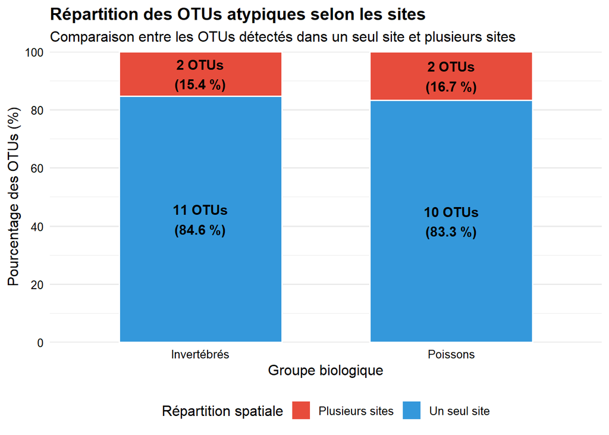

```r
## 48.3. Graphique de la répartition des OTUs selon les sites

library(ggplot2)

ggplot(
  synthese_sites_48,
  aes(
    x = Groupe,
    y = Pourcentage,
    fill = Repartition
  )
) +
  geom_col(
    position = "stack",
    width = 0.65,
    color = "white"
  ) +
  geom_text(
    aes(label = Etiquette),
    position = position_stack(vjust = 0.5),
    size = 4,
    fontface = "bold"
  ) +
  scale_fill_manual(
    values = c(
      "Un seul site" = "#3498DB",
      "Plusieurs sites" = "#E74C3C"
    )
  ) +
  scale_y_continuous(
    breaks = seq(0, 100, by = 20),
    limits = c(0, 100),
    expand = c(0, 0)
  ) +
  labs(
    title = "Répartition des OTUs atypiques selon les sites",
    subtitle = "Comparaison entre les OTUs détectés dans un seul site et plusieurs sites",
    x = "Groupe biologique",
    y = "Pourcentage des OTUs (%)",
    fill = "Répartition spatiale"
  ) +
  theme_minimal(base_size = 12) +
  theme(
    plot.title = element_text(
      face = "bold",
      size = 14
    ),
    axis.text = element_text(color = "black"),
    legend.position = "bottom"
  )
```

##48.4 – Identifier les OTUs détectés dans plusieurs sites Nous avons isolé les OTUs retrouvés dans plusieurs sites. Ce tableau est particulièrement intéressant pour identifier les assignations taxonomiques atypiques qui se répètent spatialement.

**Interprétation : OTUs détectés dans plusieurs sites** Quatre OTUs méritent une attention particulière. Deux observations ressortent : - Chez les invertébrés, l’OTU 1330 (Bosmina) possède la distribution spatiale la plus étendue, avec trois sites. - Chez les poissons, les deux OTUs retrouvés dans plusieurs sites sont assignés au genre Homo. Ils présentent toutefois des nombres de lectures relativement faibles : 16 et 12 respectivement. La répétition de ces détections dans plusieurs sites mérite d’être examinée, mais elle ne permet pas de confirmer les assignations taxonomiques.

```r
## 48.4. Liste des OTUs détectés dans plusieurs sites

otus_multi_sites_48 <- resume_otus_sites_48 %>%
  dplyr::filter(Nombre_sites > 1) %>%
  dplyr::select(
    Groupe,
    OTU,
    Genre,
    Nombre_sites,
    Liste_sites,
    Total_lectures
  ) %>%
  dplyr::arrange(
    Groupe,
    dplyr::desc(Nombre_sites)
  )

print(otus_multi_sites_48, n = Inf)
```

```
## # A tibble: 4 × 6
##   Groupe      OTU   Genre   Nombre_sites Liste_sites              Total_lectures
##   <chr>       <chr> <chr>          <int> <chr>                             <dbl>
## 1 Invertébrés 1330  Bosmina            3 Le.Parc.Martel, Les.ecl…            384
## 2 Invertébrés 1301  Bos                2 Heron.Bleu, Parc.Marcel…            343
## 3 Poissons    291   Homo               2 Parc.Andre.J..Cote, Par…             16
## 4 Poissons    296   Homo               2 Le.pont.du.Chemin.Saint…             12
```

#48. Distribution spatiale des OTUs présentant une taxonomie atypique

L’analyse de la distribution spatiale des OTUs atypiques montre que la majorité d’entre eux sont détectés dans un seul site d’échantillonnage. Sur les 13 OTUs identifiés chez les invertébrés, 11 (84,6 %) sont limités à un seul site, tandis que deux (15,4 %) sont retrouvés dans plusieurs sites. Une tendance similaire est observée chez les poissons, où 10 OTUs sur 12 (83,3 %) sont détectés dans un seul site et deux (16,7 %) dans plusieurs sites.

Chez les invertébrés, l’OTU 1330, assigné au genre Bosmina, présente la distribution spatiale la plus étendue, puisqu’il est détecté au **Parc Martel, aux Écluses et au Parc Paul-Leveille**. L’**OTU 1301**, assigné au genre Bos, est également retrouvé dans deux sites : **Héron Bleu et Parc Marcel-Seers.**

Chez les poissons, les **OTUs 291 et 296**, tous deux assignés au genre Homo, sont chacun détectés dans deux sites distincts. Par ailleurs, **six OTUs assignés au genre Bos sont observés au Parc de la Fabrique, avec un total cumulé de 88 068** lectures dans l’échantillon concerné.

Dans l’ensemble, ces résultats indiquent que les OTUs atypiques présentent principalement une distribution spatiale restreinte dans les échantillons analysés. Toutefois, leur détection dans un ou plusieurs sites ne permet pas de confirmer leur identité taxonomique ni d’établir avec certitude la présence des organismes correspondants. Une vérification des séquences et des assignations taxonomiques demeure nécessaire avant toute interprétation écologique.

**Analyse des lectures associées aux OTUs atypiques dans les échantillons biologiques.**

L’objectif est de déterminer quels échantillons concentrent le plus de lectures attribuées aux 25 OTUs atypiques identifiés au bloc 46, et combien d’OTUs différents sont détectés dans chacun d’eux.

Nous avons repris les matrices initiales et les fichiers de mapping pour travailler directement à l’échelle de chaque échantillon. Nous avons aussi conservé uniquement les échantillons biologiques.

### 5.3.25 Extraction des lectures par échantillon biologique

Ce premier bloc extrait les lectures des OTUs atypiques à partir des matrices initiales. Il évite de reprendre les totaux agrégés par site, ce qui permet de calculer les véritables nombres de lectures par échantillon.

**Interprétation: détections par échantillon**

Les 30 détections recensées se répartissent ainsi : - Invertébrés : 16 détections concernant 13 OTUs, réparties dans 11 échantillons biologiques. - Poissons : 14 détections concernant 12 OTUs, réparties dans 9 échantillons biologiques. Un même échantillon peut contenir plusieurs OTUs atypiques. C’est notamment le cas de l’échantillon du Parc de la Fabrique chez les poissons, dans lequel six OTUs sont détectés.

```r
## 49.1. Extraction des détections des OTUs atypiques par échantillon

# Fonction d'extraction des détections biologiques
extraire_detections_49 <- function(matrice, mapping, groupe) {

  # Sélection des OTUs atypiques du groupe
  otus_cibles <- otu_atypiques_sans_controles_46 %>%
    dplyr::filter(Groupe == groupe) %>%
    dplyr::pull(OTU)

  # Passage au format long et extraction des détections
  detections <- matrice %>%
    dplyr::filter(
      as.character(`#FEATURE_ID`) %in% otus_cibles
    ) %>%
    tidyr::pivot_longer(
      cols = -c(`#FEATURE_ID`, taxonomy),
      names_to = "SampleID",
      values_to = "Lectures"
    ) %>%
    dplyr::filter(Lectures > 0) %>%
    dplyr::mutate(
      OTU = as.character(`#FEATURE_ID`),
      Groupe = groupe
    ) %>%
    dplyr::left_join(
      mapping %>%
        dplyr::select(
          SampleID,
          SiteEchantillonnage,
          TypeEchantillon,
          Treatment
        ),
      by = "SampleID"
    ) %>%
    dplyr::filter(TypeEchantillon == "Biologique") %>%
    dplyr::select(
      Groupe,
      OTU,
      SampleID,
      SiteEchantillonnage,
      Lectures,
      Treatment
    )

  return(detections)
}

# Extraction pour les deux groupes
detections_invertebres_49 <- extraire_detections_49(
  data_invertebres,
  mapping_invertebres,
  "Invertébrés"
)

detections_poissons_49 <- extraire_detections_49(
  data_poissons,
  mapping_poissons,
  "Poissons"
)

# Regroupement des deux groupes
detections_otus_atypiques_49 <- dplyr::bind_rows(
  detections_invertebres_49,
  detections_poissons_49
)

# Vérification
print(detections_otus_atypiques_49, n = Inf)
```

```
## # A tibble: 30 × 6
##    Groupe      OTU   SampleID             SiteEchantillonnage Lectures Treatment
##    <chr>       <chr> <chr>                <chr>                  <dbl> <chr>
##  1 Invertébrés 1301  MI.M05812_0023.001.… Heron.Bleu               175 Ecole.se…
##  2 Invertébrés 1301  MI.M05812_0023.001.… Parc.Marcel.Seers        168 College.…
##  3 Invertébrés 1330  MI.M05812_0023.001.… Les.ecluses              237 Ecole.se…
##  4 Invertébrés 1330  MI.M05812_0023.001.… Le.Parc.Martel            57 Ecole.se…
##  5 Invertébrés 1330  MI.M05812_0023.001.… Parc.Paul-Leveille        41 Ecole.Sa…
##  6 Invertébrés 1953  MI.M05812_0023.001.… Vieux-Port,.le.pont      190 College.…
##  7 Invertébrés 2863  MI.M05812_0023.001.… Amont.du.barrage         104 Ecole.po…
##  8 Invertébrés 3086  MI.M05812_0023.001.… Berge.des.Baigneurs       91 Polyvale…
##  9 Invertébrés 3566  MI.M05812_0023.001.… Amont.du.barrage          68 Ecole.po…
## 10 Invertébrés 3743  MI.M05812_0023.001.… Amont.du.barrage          61 Ecole.po…
## 11 Invertébrés 3893  MI.M05812_0023.001.… Amont.du.barrage          56 Ecole.po…
## 12 Invertébrés 3954  MI.M05812_0023.001.… Amont.du.barrage          54 Ecole.po…
```

[output cut: 18 more lines]

```r
# Vérification du nombre de détections par groupe
detections_otus_atypiques_49 %>%
  dplyr::count(Groupe, name = "Nombre_detections") %>%
  print()
```

```
## # A tibble: 2 × 2
##   Groupe      Nombre_detections
##   <chr>                   <int>
## 1 Invertébrés                16
## 2 Poissons                   14
```

### 5.3.26 Synthèse des lectures par échantillon

Nous avons calculé ici, pour chaque échantillon : - Le nombre d’OTUs atypiques détectés. - Le nombre total de lectures associées à ces OTUs. - La liste des OTUs concernés. - Le site d’échantillonnage correspondant.

**Interprétation : lectures par échantillon** **Chez les invertébrés** L’échantillon de l’Amont du barrage présente le plus grand nombre d’OTUs atypiques : cinq, pour un total de 343 lectures.

Il est suivi par : - **Les Écluses** : 2 OTUs et 286 lectures. - **Vieux-Port**, le pont : 1 OTU et 190 lectures. - **Héron Bleu** : 1 OTU et 175 lectures. - **Parc Marcel-Seers* : 1 OTU et 168 lectures. Les autres échantillons présentent des totaux plus faibles, compris entre 9 et 91 lectures.** Chez les poissons **Le résultat le plus marquant concerne l’échantillon du Parc de la Fabrique : -** 6 OTUs atypiques détectés** ; - **88 068 lectures cumulées**. Les autres échantillons présentent chacun un seul OTU atypique, avec des totaux compris entre **4 et 110 lectures**.

Cette concentration est particulièrement importante : elle représente presque toutes les 88 233 lectures atypiques recensées chez les poissons.

**NB** : ces **88 068 lectures** proviennent d’un seul échantillon. Elles ne constituent pas six observations indépendantes ni une preuve d’une présence de bovins sur le site.

```r
## 49.2. Synthèse des OTUs atypiques par échantillon biologique

resume_echantillons_49 <- detections_otus_atypiques_49 %>%
  dplyr::group_by(
    Groupe,
    SampleID,
    SiteEchantillonnage
  ) %>%
  dplyr::summarise(
    Nombre_OTUs = dplyr::n_distinct(OTU),
    Total_lectures = sum(Lectures, na.rm = TRUE),
    Liste_OTUs = paste(
      sort(unique(OTU)),
      collapse = ", "
    ),
    .groups = "drop"
  ) %>%
  dplyr::arrange(
    Groupe,
    dplyr::desc(Total_lectures)
  )

print(resume_echantillons_49, n = Inf)
```

```
## # A tibble: 20 × 6
##    Groupe     SampleID SiteEchantillonnage Nombre_OTUs Total_lectures Liste_OTUs
##    <chr>      <chr>    <chr>                     <int>          <dbl> <chr>
##  1 Invertébr… MI.M058… Amont.du.barrage              5            343 2863, 356…
##  2 Invertébr… MI.M058… Les.ecluses                   2            286 1330, 4100
##  3 Invertébr… MI.M058… Vieux-Port,.le.pont           1            190 1953
##  4 Invertébr… MI.M058… Heron.Bleu                    1            175 1301
##  5 Invertébr… MI.M058… Parc.Marcel.Seers             1            168 1301
##  6 Invertébr… MI.M058… Berge.des.Baigneurs           1             91 3086
##  7 Invertébr… MI.M058… Le.Parc.Martel                1             57 1330
##  8 Invertébr… MI.M058… Parc.Andre.J..Cote            1             46 4232
##  9 Invertébr… MI.M058… Parc.Paul-Leveille            1             41 1330
## 10 Invertébr… MI.M058… Parc.de.la.Fabrique           1             10 6692
## 11 Invertébr… MI.M058… Aval.du.barrage               1              9 6927
## 12 Poissons   MI.M058… Parc.de.la.Fabrique           6          88068 121, 143,…
## 13 Poissons   MI.M058… Parc.Marcel.Seers             1            110 247
## 14 Poissons   MI.M058… Les.ecluses                   1             10 300
## 15 Poissons   MI.M058… Montee.Robert                 1              9 301
## 16 Poissons   MI.M058… Parc.Andre.J..Cote            1              9 291
## 17 Poissons   MI.M058… Berge.des.Baigneurs           1              8 304
## 18 Poissons   MI.M058… Parc.Charbonneau              1              8 296
## 19 Poissons   MI.M058… Parc.de.Ile.Belair            1              7 291
## 20 Poissons   MI.M058… Le.pont.du.Chemin.…           1              4 296
```

### 5.3.27 Identification des échantillons les plus concernés

Ce bloc permet d’identifier les échantillons qui présentent les nombres les plus élevés de lectures associées aux OTUs atypiques.

**Interprétation : classement des échantillons**

Le classement confirme les observations précédentes. - Chez les invertébrés, l’échantillon de l’Amont du barrage arrive en tête avec 343 lectures. - Chez les poissons, l’échantillon du Parc de la Fabrique domine très largement avec **88 068 lectures**. Le tableau présente les dix premiers échantillons chez les invertébrés : celui de l’Aval du barrage, qui ne compte que 9 lectures, est donc absent du classement. Chez les poissons, les neuf échantillons détectés sont tous affichés.

```r
## 49.3. Classement des échantillons selon les lectures atypiques

top_echantillons_49 <- resume_echantillons_49 %>%
  dplyr::group_by(Groupe) %>%
  dplyr::slice_max(
    order_by = Total_lectures,
    n = 10,
    with_ties = TRUE
  ) %>%
  dplyr::ungroup() %>%
  dplyr::arrange(
    Groupe,
    dplyr::desc(Total_lectures)
  )

print(top_echantillons_49, n = Inf)
```

```
## # A tibble: 19 × 6
##    Groupe     SampleID SiteEchantillonnage Nombre_OTUs Total_lectures Liste_OTUs
##    <chr>      <chr>    <chr>                     <int>          <dbl> <chr>
##  1 Invertébr… MI.M058… Amont.du.barrage              5            343 2863, 356…
##  2 Invertébr… MI.M058… Les.ecluses                   2            286 1330, 4100
##  3 Invertébr… MI.M058… Vieux-Port,.le.pont           1            190 1953
##  4 Invertébr… MI.M058… Heron.Bleu                    1            175 1301
##  5 Invertébr… MI.M058… Parc.Marcel.Seers             1            168 1301
##  6 Invertébr… MI.M058… Berge.des.Baigneurs           1             91 3086
##  7 Invertébr… MI.M058… Le.Parc.Martel                1             57 1330
##  8 Invertébr… MI.M058… Parc.Andre.J..Cote            1             46 4232
##  9 Invertébr… MI.M058… Parc.Paul-Leveille            1             41 1330
## 10 Invertébr… MI.M058… Parc.de.la.Fabrique           1             10 6692
## 11 Poissons   MI.M058… Parc.de.la.Fabrique           6          88068 121, 143,…
## 12 Poissons   MI.M058… Parc.Marcel.Seers             1            110 247
## 13 Poissons   MI.M058… Les.ecluses                   1             10 300
## 14 Poissons   MI.M058… Montee.Robert                 1              9 301
## 15 Poissons   MI.M058… Parc.Andre.J..Cote            1              9 291
## 16 Poissons   MI.M058… Berge.des.Baigneurs           1              8 304
## 17 Poissons   MI.M058… Parc.Charbonneau              1              8 296
## 18 Poissons   MI.M058… Parc.de.Ile.Belair            1              7 291
## 19 Poissons   MI.M058… Le.pont.du.Chemin.…           1              4 296
```

### 5.3.28 Visualisation du nombre total de lectures atypiques par échantillon

La répartition des lectures associées aux OTU atypiques a révélé une forte hétérogénéité entre les échantillons. Chez les poissons, une concentration importante a été observée au Parc de la Fabrique, principalement pour les OTU annotées Bos. Cette observation a justifié une vérification taxonomique ciblée, sans permettre d’estimer l’abondance des organismes.

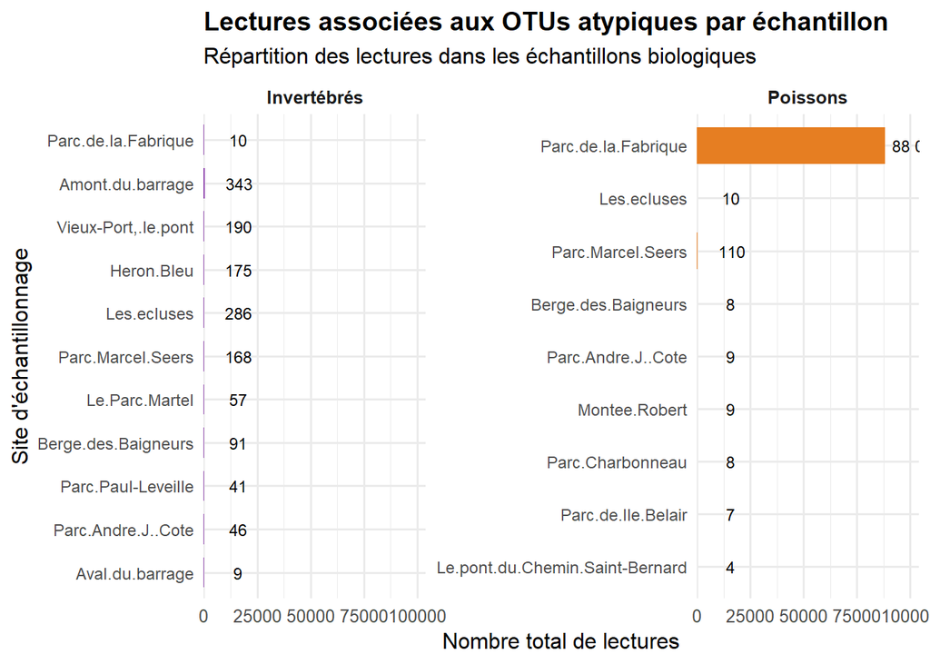

```r
## 49.4. Graphique du nombre de lectures atypiques par échantillon

library(ggplot2)

ggplot(
  resume_echantillons_49,
  aes(
    x = reorder(SiteEchantillonnage, Total_lectures),
    y = Total_lectures,
    fill = Groupe
  )
) +
  geom_col(
    width = 0.7,
    show.legend = FALSE
  ) +
  geom_text(
    aes(label = format(Total_lectures, big.mark = " ")),
    hjust = -0.15,
    size = 3.2
  ) +
  coord_flip() +
  facet_wrap(
    ~ Groupe,
    scales = "free_y"
  ) +
  scale_fill_manual(
    values = c(
      "Invertébrés" = "#8E44AD",
      "Poissons" = "#E67E22"
    )
  ) +
  scale_y_continuous(
    expand = expansion(mult = c(0, 0.18))
  ) +
  labs(
    title = "Lectures associées aux OTUs atypiques par échantillon",
    subtitle = "Répartition des lectures dans les échantillons biologiques",
    x = "Site d'échantillonnage",
    y = "Nombre total de lectures"
  ) +
  theme_minimal(base_size = 12) +
  theme(
    plot.title = element_text(face = "bold", size = 14),
    strip.text = element_text(face = "bold"),
    axis.text.y = element_text(size = 9)
  )
```

### 5.3.29 Graphique du nombre d’OTU atypiques par échantillon

Le nombre d’OTU atypiques a varié entre les échantillons, ce qui a révélé une répartition inégale des annotations inhabituelles entre les sites. Ces résultats ont souligné l’intérêt d’examiner conjointement les lectures, les fréquences de détection et les résultats des contrôles négatifs.

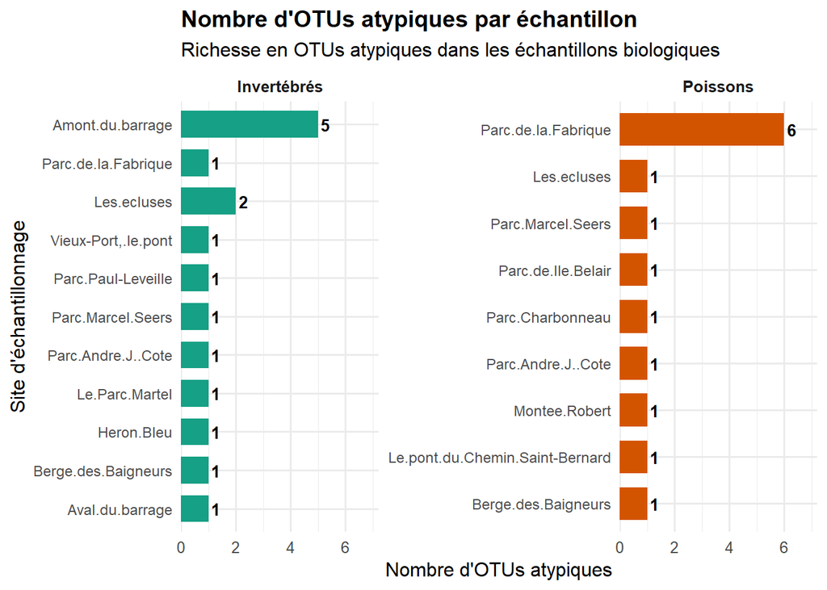

```r
## 49.5. Graphique du nombre d'OTUs atypiques par échantillon

ggplot(
  resume_echantillons_49,
  aes(
    x = reorder(SiteEchantillonnage, Nombre_OTUs),
    y = Nombre_OTUs,
    fill = Groupe
  )
) +
  geom_col(
    width = 0.7,
    show.legend = FALSE
  ) +
  geom_text(
    aes(label = Nombre_OTUs),
    hjust = -0.3,
    size = 3.5,
    fontface = "bold"
  ) +
  coord_flip() +
  facet_wrap(
    ~ Groupe,
    scales = "free_y"
  ) +
  scale_fill_manual(
    values = c(
      "Invertébrés" = "#16A085",
      "Poissons" = "#D35400"
    )
  ) +
  scale_y_continuous(
    breaks = scales::breaks_pretty(),
    expand = expansion(mult = c(0, 0.2))
  ) +
  labs(
    title = "Nombre d'OTUs atypiques par échantillon",
    subtitle = "Richesse en OTUs atypiques dans les échantillons biologiques",
    x = "Site d'échantillonnage",
    y = "Nombre d'OTUs atypiques"
  ) +
  theme_minimal(base_size = 12) +
  theme(
    plot.title = element_text(face = "bold", size = 14),
    strip.text = element_text(face = "bold"),
    axis.text.y = element_text(size = 9)
  )
```

##Analyse des lectures associées aux OTUs atypiques dans les échantillons biologiques

L’analyse des lectures associées aux OTUs atypiques a permis de recenser 30 détections dans les échantillons biologiques, dont 16 chez les invertébrés et 14 chez les poissons.

Chez les invertébrés, l’échantillon provenant de l’Amont du barrage présente le plus grand nombre d’OTUs atypiques, avec cinq OTUs totalisant 343 lectures. L’échantillon des Écluses présente également deux OTUs, avec 286 lectures. Les autres échantillons montrent généralement une seule détection, avec des nombres de lectures plus faibles.

Chez les poissons, une concentration particulièrement importante est observée dans l’échantillon du Parc de la Fabrique. Celui-ci contient six OTUs atypiques totalisant 88 068 lectures, alors que les autres échantillons positifs présentent chacun un seul OTU et des nombres de lectures nettement inférieurs.

Cette distribution a mis en évidence une forte concentration des lectures atypiques dans un échantillon particulier chez les poissons, contrairement aux invertébrés, pour lesquels les lectures sont réparties entre plusieurs échantillons. Cette observation doit toutefois être interprétée avec prudence : le nombre de lectures ne traduit pas directement l’abondance des organismes et ne permet pas, à lui seul, de confirmer les assignations taxonomiques. Une vérification des séquences associées aux OTUs concernés reste nécessaire.

### 5.3.30 Composition des lectures par OTU dans chaque échantillon

La prochaine étape consiste à visualiser la contribution de chaque OTU au total des lectures atypiques de chaque échantillon. Nous utiliserons des barres empilées : chaque couleur représentera un OTU différent.

Ce graphique a permis notamment de voir si les **88 068 lectures du Parc de la Fabrique** sont dominées par un seul OTU ou réparties entre les **six OTUs détectés**.

**Interprétation**

Le graphique présente la répartition des lectures associées aux OTUs atypiques détectés dans les échantillons biologiques, en distinguant les invertébrés et les poissons. Chaque couleur représente un OTU et la longueur de chaque segment correspond à son nombre de lectures.

**1. Résultats pour les invertébrés**

Les lectures atypiques sont réparties entre 11 échantillons provenant de différents sites. Le site Amont du barrage présente la plus grande diversité d’OTUs atypiques, avec cinq OTUs détectés, pour un total de 343 lectures. Le site Les Écluses présente deux OTUs, totalisant 286 lectures.

Dans les autres échantillons, un seul OTU atypique est détecté par site. Les nombres de lectures restent relativement faibles, allant de 9 à 190 selon les résultats du tableau récapitulatif. Cette répartition montre que les signaux atypiques chez les invertébrés sont dispersés entre plusieurs sites, sans concentration aussi marquée que celle observée chez les poissons.

**2. Résultats pour les poissons**

La distribution des lectures atypiques chez les poissons est fortement dominée par l’échantillon provenant du Parc de la Fabrique. Celui-ci regroupe six OTUs atypiques et totalise 88 068 lectures.

Deux OTUs contribuent particulièrement à ce résultat : l’**OTU21, avec 62 040 lectures**, et **l’OTU33, avec 22 788 lectures.** Les autres OTUs présents dans cet échantillon contribuent beaucoup plus faiblement au total.

Dans les huit autres échantillons, les détections sont limitées à un seul OTU par échantillon, avec des nombres de lectures compris entre 4 et 110. Le signal atypique observé chez les poissons est donc très fortement concentré au Parc de la Fabrique.

**3. Comparaison et interprétation générale**

Les deux groupes présentent des profils spatiaux différents. Chez les invertébrés, les lectures atypiques sont réparties entre plusieurs échantillons et plusieurs sites, tandis que chez les poissons, elles sont principalement concentrées dans un seul échantillon du Parc de la Fabrique.

Cette concentration mérite une attention particulière, notamment pour les **OTUs21 et 33**, qui représentent l’essentiel des lectures atypiques chez les poissons. Il serait pertinent de vérifier leurs séquences et leurs annotations taxonomiques afin de déterminer si les assignations obtenues sont fiables.

Il faut toutefois rappeler que le nombre de lectures ne correspond pas directement à l’abondance des organismes dans l’environnement. De plus, les résultats des poissons et des invertébrés proviennent de marqueurs moléculaires différents : leurs nombres de lectures ne doivent donc pas être comparés directement. Point important concernant la lisibilité du graphique Le graphique utilise actuellement une même échelle horizontale pour les deux groupes. Comme l’échantillon du **Parc de la Fabrique atteint 88 068 lectures chez les poissons**, les barres des invertébrés paraissent presque invisibles. Les petites valeurs inscrites dans les segments sont également difficiles à lire.

*NB* : Pour une meilleure présentation dans le rapport, nous avons donné à chaque groupe sa propre échelle horizontale (scales = “free_x”). Cela a permis de mieux distinguer la composition des OTUs chez les invertébrés sans masquer les différences observées chez les poissons.

```r
## 49.6. Composition des lectures atypiques par OTU et par échantillon


composition_otus_49 <- detections_otus_atypiques_49 %>%
  dplyr::mutate(OTU = factor(OTU)) %>%
  dplyr::group_by(Groupe, SiteEchantillonnage, SampleID, OTU) %>%
  dplyr::summarise(
    Lectures = sum(Lectures, na.rm = TRUE),
    .groups = "drop"
  )

ggplot(
  composition_otus_49,
  aes(x = SiteEchantillonnage, y = Lectures, fill = OTU)
) +
  geom_col(
    width = 0.75,
    color = "white",
    linewidth = 0.2
  ) +
  geom_text(
    aes(label = format(Lectures, big.mark = " ")),
    position = position_stack(vjust = 0.5),
    size = 3,
    color = "black"
  ) +
  coord_flip() +
  facet_wrap(~Groupe, scales = "free") +
  scale_fill_viridis_d(
    option = "turbo",
    name = "OTU"
  ) +
  scale_y_continuous(
    expand = expansion(mult = c(0, 0.15))
  ) +
  labs(
    title = "Composition des lectures atypiques par échantillon",
    subtitle = "Contribution de chaque OTU au total des lectures",
    x = "Site d'échantillonnage",
    y = "Nombre de lectures"
  ) +
  theme_minimal(base_size = 12) +
  theme(
    plot.title = element_text(face = "bold", size = 14),
    strip.text = element_text(face = "bold"),
    axis.text.y = element_text(size = 9),
    legend.position = "bottom"
  )
```

[figure not shown]

##Analyse de la contribution relative de chaque OTU dans les échantillons.

Jusqu’ici, nous avons étudié le nombre brut de lectures. Cette nouvelle étape a permis de déterminer la proportion que représente chaque OTU dans le total des lectures atypiques de son échantillon.

L’intérêt est notamment de voir si un échantillon est dominé par un seul OTU ou si les lectures sont réparties entre plusieurs OTUs.

### 5.3.31 Proportion des OTUs par échantillon

**Interprétation : Contribution relative des OTUs atypiques par échantillon** **1. Résultats pour les invertébrés**

Chez les invertébrés, la majorité des échantillons présentent un seul OTU atypique, qui représente donc 100 % des lectures atypiques détectées dans l’échantillon concerné.

Deux échantillons présentent toutefois plusieurs OTUs : - Les Écluses : deux OTUs sont détectés. L’un représente 82,9 % des lectures atypiques, tandis que l’autre contribue à hauteur de 17,1 %. La répartition est donc dominée par un OTU. - Amont du barrage : L’échantillon d’Amont du barrage présente cinq OTUs atypiques dont les contributions sont relativement réparties. L’OTU2863 est le plus représenté, avec 30,32 % des lectures, suivi des OTUs3566 (19,83 %), 3743 (17,78 %), 3893 (16,33 %) et 3954 (15,74 %). Aucun OTU ne représente à lui seul la majorité des lectures atypiques de cet échantillon.

Cette répartition traduit une composition plus équilibrée des lectures atypiques entre les cinq OTUs, contrairement à l’échantillon des Écluses, où un OTU représente 82,9 % des lectures.

Ces résultats montrent que, dans la plupart des échantillons d’invertébrés, le signal atypique est associé à un seul OTU. Les échantillons d’Amont du barrage et des Écluses présentent une composition plus diversifiée en termes d’OTUs atypiques.

**2. Résultats pour les poissons**

Chez les poissons, huit des neuf échantillons présentent un seul OTU atypique, représentant 100 % des lectures atypiques de chaque échantillon.

Le cas du Parc de la Fabrique est particulièrement remarquable : six OTUs y sont détectés, mais la distribution des lectures est fortement dominée par deux OTUs : - L’**OTU21 représente 70,4 % des lectures atypiques**. - L’**OTU33 représente 25,9 %.** - Les **quatre autres OTUs se partagent les quelque 3,7 % restants**.

Cette distribution confirme la forte concentration du signal atypique observée précédemment au Parc de la Fabrique.

```r
## 49.7. Calcul des proportions relatives des OTUs par échantillon

proportions_otus_49 <- composition_otus_49 %>%
  dplyr::group_by(Groupe, SampleID, SiteEchantillonnage) %>%
  dplyr::mutate(
    Total_lectures = sum(Lectures, na.rm = TRUE),
    Proportion = Lectures / Total_lectures,
    Pourcentage = Proportion * 100
  ) %>%
  dplyr::ungroup()

## Vérification des proportions par échantillon

resume_proportions_49 <- proportions_otus_49 %>%
  dplyr::group_by(Groupe, SampleID, SiteEchantillonnage) %>%
  dplyr::summarise(
    Total_lectures = first(Total_lectures),
    Somme_pourcentages = sum(Pourcentage),
    Nombre_OTUs = dplyr::n(),
    .groups = "drop"
  )

print(resume_proportions_49)
```

```
## # A tibble: 20 × 6
##    Groupe      SampleID    SiteEchantillonnage Total_lectures Somme_pourcentages
##    <chr>       <chr>       <chr>                        <dbl>              <dbl>
##  1 Invertébrés MI.M05812_… Les.ecluses                    286                100
##  2 Invertébrés MI.M05812_… Le.Parc.Martel                  57                100
##  3 Invertébrés MI.M05812_… Vieux-Port,.le.pont            190                100
##  4 Invertébrés MI.M05812_… Parc.de.la.Fabrique             10                100
##  5 Invertébrés MI.M05812_… Heron.Bleu                     175                100
##  6 Invertébrés MI.M05812_… Parc.Andre.J..Cote              46                100
##  7 Invertébrés MI.M05812_… Parc.Marcel.Seers              168                100
##  8 Invertébrés MI.M05812_… Aval.du.barrage                  9                100
##  9 Invertébrés MI.M05812_… Amont.du.barrage               343                100
## 10 Invertébrés MI.M05812_… Berge.des.Baigneurs             91                100
## 11 Invertébrés MI.M05812_… Parc.Paul-Leveille              41                100
## 12 Poissons    MI.M05812_… Montee.Robert                    9                100
## 13 Poissons    MI.M05812_… Les.ecluses                     10                100
## 14 Poissons    MI.M05812_… Berge.des.Baigneurs              8                100
## 15 Poissons    MI.M05812_… Parc.de.la.Fabrique          88068                100
## 16 Poissons    MI.M05812_… Parc.Charbonneau                 8                100
## 17 Poissons    MI.M05812_… Parc.de.Ile.Belair               7                100
## 18 Poissons    MI.M05812_… Parc.Andre.J..Cote               9                100
## 19 Poissons    MI.M05812_… Parc.Marcel.Seers              110                100
## 20 Poissons    MI.M05812_… Le.pont.du.Chemin.…              4                100
## # ℹ 1 more variable: Nombre_OTUs <int>
```

```r
## Visualisation des proportions relatives

ggplot(
  proportions_otus_49,
  aes(
    x = SiteEchantillonnage,
    y = Proportion,
    fill = OTU
  )
) +
  geom_col(
    width = 0.75,
    color = "white",
    linewidth = 0.2
  ) +
  geom_text(
    aes(
      label = ifelse(
        Proportion >= 0.05,
        paste0(round(Pourcentage, 1), "%"),
        ""
      )
    ),
    position = position_stack(vjust = 0.5),
    size = 2.8,
    color = "black"
  ) +
  coord_flip() +
  facet_wrap(~Groupe, scales = "free") +
  scale_fill_viridis_d(
    option = "turbo",
    name = "OTU"
  ) +
  scale_y_continuous(
    labels = scales::label_percent(),
    limits = c(0, 1),
    expand = expansion(mult = c(0, 0.02))
  ) +
  labs(
    title = "Contribution relative des OTUs atypiques par échantillon",
    subtitle = "Pourcentage des lectures attribuées à chaque OTU dans son échantillon",
    x = "Site d'échantillonnage",
    y = "Proportion des lectures"
  ) +
  theme_minimal(base_size = 12) +
  theme(
    plot.title = element_text(face = "bold", size = 14),
    strip.text = element_text(face = "bold"),
    axis.text.y = element_text(size = 9),
    legend.position = "bottom"
  )
```

[figure not shown]

Comment lire ce graphique ? - Chaque barre représente un échantillon et totalise 100 %. - Chaque couleur correspond à un OTU. - Un segment important indique que l’OTU représente une grande part des lectures atypiques de cet échantillon. - Les pourcentages inférieurs à 5 % ne sont pas affichés pour éviter de surcharger le graphique. Attention : ces proportions décrivent uniquement la composition des lectures atypiques retenues dans chaque échantillon. Elles ne représentent pas la proportion réelle des organismes présents dans le milieu.

# 6 Conclusion générale

L’analyse des proportions relatives met en évidence deux profils distincts. Chez les invertébrés, les lectures atypiques sont généralement associées à un seul OTU par échantillon, avec quelques situations de coexistence de plusieurs OTUs. Chez les poissons, le signal est également dominé par un seul OTU dans la majorité des échantillons, à l’exception notable du Parc de la Fabrique, où deux OTUs concentrent l’essentiel des lectures.

Ces observations permettent de mieux caractériser la composition des signaux atypiques, mais ne permettent pas de confirmer l’identité taxonomique des OTUs ni de conclure à l’abondance des organismes correspondants dans le milieu.

*NB* : cette synthèse concerne précisément les 25 OTUs signalés comme atypiques sur le plan taxonomique et absents des contrôles. Elle ne signifie pas que les autres OTUs détectés dans les contrôles sont tous fiables ou qu’ils doivent être écartés.

**Tableau de synthèse des OTUs atypiques** Ce tableau réunit les informations taxonomiques, le nombre de lectures, le nombre d’échantillons positifs et le nombre de sites concernés.

**Interprétation : Synthèse des OTUs atypiques** L’analyse a permis d’identifier 25 OTUs atypiques absents des contrôles, dont 13 chez les invertébrés et 12 chez les poissons.

Chez les invertébrés, les annotations taxonomiques sont principalement associées au genre Bosmina (9 OTUs), tandis que trois OTUs sont attribués à des mammifères (Bos, Ondatra et Felis) et un au genre Lobosphaera. L’OTU1301 présente le plus grand nombre de lectures (343), suivi de l’OTU1330 (335) et de l’OTU1953 (190). Sur le plan spatial, l’OTU1330 est détecté dans trois sites et l’OTU1301 dans deux sites, tandis que les autres OTUs sont chacun associés à un seul site.

Chez les poissons, les 12 OTUs sont tous annotés comme des mammifères : dix appartiennent au genre Bos et deux au genre Homo. Les OTUs21 et 33 dominent largement avec respectivement 62 040 et 22 788 lectures. Ils sont tous deux détectés au Parc de la Fabrique. Les deux OTUs attribués à Homo sont chacun retrouvés dans deux sites, mais présentent de faibles nombres de lectures.

Dans l’ensemble, les résultats révèlent des annotations taxonomiques inhabituelles, particulièrement chez les poissons où tous les OTUs sont associés à des mammifères. Bien que ces OTUs soient absents des contrôles, leurs assignations doivent être vérifiées à partir des séquences avant de confirmer leur identité taxonomique.

```r
## 50.1. Synthèse générale des 25 OTUs atypiques absents des contrôles

## Résumé des détections par OTU
resume_general_otus_50 <- detections_otus_atypiques_49 %>%
  dplyr::group_by(Groupe, OTU) %>%
  dplyr::summarise(
    Total_lectures = sum(Lectures, na.rm = TRUE),
    Nombre_echantillons = dplyr::n_distinct(SampleID),
    Nombre_sites = dplyr::n_distinct(SiteEchantillonnage),
    Liste_sites = paste(
      sort(unique(SiteEchantillonnage)),
      collapse = ", "
    ),
    .groups = "drop"
  )

## Récupération des informations taxonomiques
taxonomie_50 <- niveaux_taxonomiques_complets %>%
  dplyr::select(
    Groupe, OTU, Regne, Embranchement, Classe,
    Ordre, Famille, Genre, Espece
  ) %>%
  dplyr::distinct(Groupe, OTU, .keep_all = TRUE)

## Fusion des informations
synthese_otus_50 <- resume_general_otus_50 %>%
  dplyr::left_join(
    taxonomie_50,
    by = c("Groupe", "OTU")
  ) %>%
  dplyr::group_by(Groupe) %>%
  dplyr::mutate(
    Pourcentage_lectures_groupe =
      Total_lectures / sum(Total_lectures) * 100
  ) %>%
  dplyr::ungroup() %>%
  dplyr::select(
    Groupe, OTU, Regne, Embranchement, Classe,
    Ordre, Famille, Genre, Espece,
    Total_lectures, Nombre_echantillons,
    Nombre_sites, Pourcentage_lectures_groupe,
    Liste_sites
  ) %>%
  dplyr::arrange(Groupe, dplyr::desc(Total_lectures))

## Affichage du tableau
print(synthese_otus_50, n = Inf, width = Inf)
```

```
## # A tibble: 25 × 14
##    Groupe      OTU   Regne     Embranchement Classe           Ordre
##    <chr>       <chr> <chr>     <chr>         <chr>            <chr>
##  1 Invertébrés 1301  Eukaryota Chordata      Mammalia         Artiodactyla
##  2 Invertébrés 1330  Eukaryota Arthropoda    Branchiopoda     Diplostraca
##  3 Invertébrés 1953  Eukaryota Arthropoda    Branchiopoda     Diplostraca
##  4 Invertébrés 2863  Eukaryota Arthropoda    Branchiopoda     Diplostraca
##  5 Invertébrés 3086  Eukaryota Chordata      Mammalia         Rodentia
##  6 Invertébrés 3566  Eukaryota Arthropoda    Branchiopoda     Diplostraca
##  7 Invertébrés 3743  Eukaryota Arthropoda    Branchiopoda     Diplostraca
##  8 Invertébrés 3893  Eukaryota Arthropoda    Branchiopoda     Diplostraca
##  9 Invertébrés 3954  Eukaryota Arthropoda    Branchiopoda     Diplostraca
## 10 Invertébrés 4100  Eukaryota Arthropoda    Branchiopoda     Diplostraca
## 11 Invertébrés 4232  Eukaryota Arthropoda    Branchiopoda     Diplostraca
## 12 Invertébrés 6692  Eukaryota Chordata      Mammalia         Carnivora
```

[output cut: 94 more lines]

```r
## Vérification du nombre d'OTUs
synthese_otus_50 %>%
  dplyr::count(Groupe, name = "Nombre_OTUs") %>%
  print()
```

```
## # A tibble: 2 × 2
##   Groupe      Nombre_OTUs
##   <chr>             <int>
## 1 Invertébrés          13
## 2 Poissons             12
```

### 6.0.1 Visualisation des OTUs atypiques les plus représentés

Nous avons visualisé les dix OTUs présentant le plus grand nombre de lectures dans chaque groupe. Cette représentation a permis d’identifier les OTUs qui contribuent le plus aux signaux atypiques observés.

**Interprétation** Chez les invertébrés, les OTUs1301 et 1330 présentent les nombres de lectures les plus élevés, avec respectivement 343 et 335 lectures, suivis de l’OTU1953 avec 190 lectures. Les autres OTUs sont moins représentés, avec des valeurs comprises entre 49 et 104 lectures parmi les dix premiers.

Chez les poissons, la distribution est beaucoup plus concentrée : les OTUs21 et 33 totalisent respectivement 62 040 et 22 788 lectures. À eux deux, ils représentent environ 96,1 % des lectures atypiques du groupe. Les autres OTUs présentent des nombres de lectures nettement plus faibles.

Ainsi, les lectures atypiques sont davantage concentrées sur deux OTUs chez les poissons, tandis qu’elles sont réparties entre plusieurs OTUs chez les invertébrés. Ces différences décrivent les profils de séquençage et ne permettent pas de déduire directement l’abondance des organismes dans le milieu.

### 6.0.2 Hiérarchisation des OTUs atypiques à vérifier en priorité

L’objectif est de croiser trois informations déjà obtenues : - le nombre total de lectures ; - le nombre d’échantillons et de sites dans lesquels chaque OTU est détecté ; - son annotation taxonomique atypique. Cela permet d’identifier les OTUs qui nécessitent une vérification plus approfondie, sans les considérer automatiquement comme des contaminations ou des erreurs.

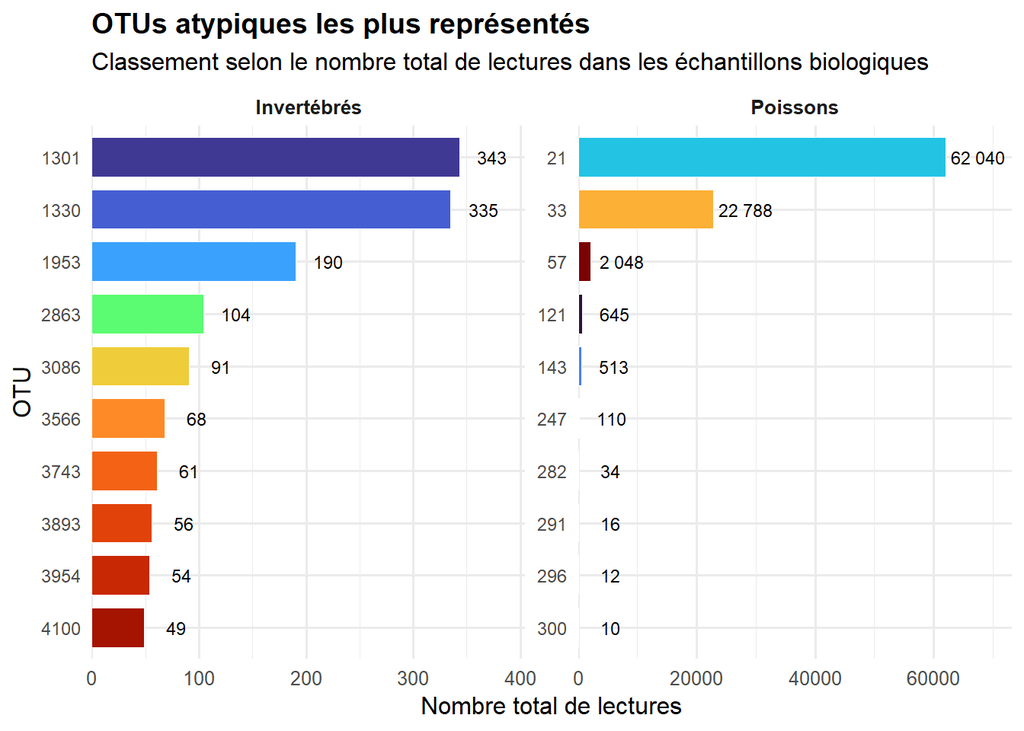

```r
## 50.2. Sélection des 10 OTUs les plus représentés par groupe

top_otus_50 <- synthese_otus_50 %>%
  dplyr::group_by(Groupe) %>%
  dplyr::slice_max(
    order_by = Total_lectures,
    n = 10,
    with_ties = TRUE
  ) %>%
  dplyr::ungroup()

## Graphique
ggplot(
  top_otus_50,
  aes(
    x = reorder(OTU, Total_lectures),
    y = Total_lectures,
    fill = OTU
  )
) +
  geom_col(
    width = 0.75,
    color = "white",
    linewidth = 0.3
  ) +
  geom_text(
    aes(label = format(Total_lectures, big.mark = " ")),
    hjust = -0.1,
    size = 3
  ) +
  coord_flip() +
  facet_wrap(~Groupe, scales = "free") +
  scale_fill_viridis_d(
    option = "turbo",
    name = "OTU"
  ) +
  scale_y_continuous(
    expand = expansion(mult = c(0, 0.18))
  ) +
  labs(
    title = "OTUs atypiques les plus représentés",
    subtitle = "Classement selon le nombre total de lectures dans les échantillons biologiques",
    x = "OTU",
    y = "Nombre total de lectures"
  ) +
  theme_minimal(base_size = 12) +
  theme(
    plot.title = element_text(face = "bold", size = 14),
    strip.text = element_text(face = "bold"),
    axis.text.y = element_text(size = 9),
    legend.position = "none"
  )
```

### 6.0.3 Classement des OTUs à vérifier

**Interprétation : Hiérarchisation des OTUs atypiques** La hiérarchisation des 25 OTUs atypiques selon leur nombre de lectures et leur répartition spatiale a permis de distinguer trois niveaux de priorité.

- **Priorité élevée** : trois OTUs ont été identifiés, tous chez les poissons (OTUs21, 33 et 57). Ils présentent respectivement 62 040, 22 788 et 2 048 lectures. Leur nombre élevé de lectures justifie une vérification prioritaire de leurs séquences et de leurs annotations taxonomiques.
- **Priorité intermédiaire** : quatre OTUs ont été identifiés. Chez les invertébrés, les OTUs1301 et 1330 sont détectés dans deux et trois sites respectivement. Chez les poissons, les OTUs291 et 296, annotés Homo, sont également retrouvés dans deux sites chacun. Leur présence dans plusieurs sites justifie une attention particulière, même si leurs nombres de lectures restent faibles pour les deux OTUs de poissons.
- **À examiner** : les 18 autres OTUs sont détectés dans un seul site et présentent des nombres de lectures inférieurs à 1 000. Ils restent à vérifier, mais leur signal est moins important ou moins récurrent selon les critères retenus.

Dans l’ensemble, cette classification a mis en évidence des OTUs nécessitant une vérification prioritaire, notamment les OTUs21, 33 et 57 chez les poissons. Toutefois, ce classement est exploratoire : un nombre élevé de lectures ou une détection dans plusieurs sites ne garantit pas la fiabilité de l’identification taxonomique.

**NB**: Une précision méthodologique importante Le classement actuel repose sur des seuils définis à titre exploratoire : - 1 000 lectures ou plus : priorité élevée ; - au moins deux sites : priorité intermédiaire ; - autres situations : à examiner. Il ne constitue donc pas une mesure formelle du risque de contamination ou de l’exactitude taxonomique.

```r
options(na.print = "NA")
getOption("na.print")
```

```
## [1] "NA"
```

```r
## 50.3. Hiérarchisation des OTUs atypiques


## 50.3. Hiérarchisation des OTUs atypiques

otus_prioritaires_50 <- synthese_otus_50 %>%
  dplyr::mutate(
    Priorite = dplyr::case_when(
      Total_lectures >= 1000 ~ "Priorité élevée",
      Nombre_sites >= 2 ~ "Priorité intermédiaire",
      TRUE ~ "À examiner"
    ),
    Priorite = factor(
      Priorite,
      levels = c(
        "Priorité élevée",
        "Priorité intermédiaire",
        "À examiner"
      )
    )
  ) %>%
  dplyr::arrange(
    Priorite,
    dplyr::desc(Total_lectures)
  )

## Affichage du classement
print(
  otus_prioritaires_50 %>%
    dplyr::select(
      Groupe, OTU, Genre,
      Total_lectures,
      Nombre_echantillons,
      Nombre_sites,
      Priorite
    ),
  n = Inf
)
```

```
## # A tibble: 25 × 7
##    Groupe   OTU   Genre Total_lectures Nombre_echantillons Nombre_sites Priorite
##    <chr>    <chr> <chr>          <dbl>               <int>        <int> <fct>
##  1 Poissons 21    Bos            62040                   1            1 Priorit…
##  2 Poissons 33    Bos            22788                   1            1 Priorit…
##  3 Poissons 57    Bos             2048                   1            1 Priorit…
##  4 Inverté… 1301  Bos              343                   2            2 Priorit…
##  5 Inverté… 1330  Bosm…            335                   3            3 Priorit…
##  6 Poissons 291   Homo              16                   2            2 Priorit…
##  7 Poissons 296   Homo              12                   2            2 Priorit…
##  8 Poissons 121   Bos              645                   1            1 À exami…
##  9 Poissons 143   Bos              513                   1            1 À exami…
## 10 Inverté… 1953  Bosm…            190                   1            1 À exami…
## 11 Poissons 247   Bos              110                   1            1 À exami…
## 12 Inverté… 2863  Bosm…            104                   1            1 À exami…
## 13 Inverté… 3086  Onda…             91                   1            1 À exami…
## 14 Inverté… 3566  Bosm…             68                   1            1 À exami…
## 15 Inverté… 3743  Bosm…             61                   1            1 À exami…
## 16 Inverté… 3893  Bosm…             56                   1            1 À exami…
## 17 Inverté… 3954  Bosm…             54                   1            1 À exami…
## 18 Inverté… 4100  Bosm…             49                   1            1 À exami…
## 19 Inverté… 4232  Bosm…             46                   1            1 À exami…
## 20 Poissons 282   Bos               34                   1            1 À exami…
## 21 Inverté… 6692  Felis             10                   1            1 À exami…
## 22 Poissons 300   Bos               10                   1            1 À exami…
## 23 Inverté… 6927  Lobo…              9                   1            1 À exami…
## 24 Poissons 301   Bos                9                   1            1 À exami…
## 25 Poissons 304   Bos                8                   1            1 À exami…
```

```r
## Nombre d'OTUs par niveau de priorité
resume_priorites_50 <- otus_prioritaires_50 %>%
  dplyr::count(Groupe, Priorite, name = "Nombre_OTUs")

print(resume_priorites_50)
```

```
## # A tibble: 5 × 3
##   Groupe      Priorite               Nombre_OTUs
##   <chr>       <fct>                        <int>
## 1 Invertébrés Priorité intermédiaire           2
## 2 Invertébrés À examiner                      11
## 3 Poissons    Priorité élevée                  3
## 4 Poissons    Priorité intermédiaire           2
## 5 Poissons    À examiner                       7
```

### 6.0.4 Visualisation de la répartition des OTUs selon leur niveau de priorité

*Interprétation du graphique*

Le graphique montre que la majorité des OTUs identifiées dans les deux groupes sont classées dans la catégorie « À examiner », avec 11 OTUs chez les invertébrés et 7 chez les poissons. La priorité intermédiaire concerne 2 OTUs dans chaque groupe. En revanche, 3 OTUs chez les poissons sont classées en priorité élevée, contre aucune chez les invertébrés.

Ces résultats montrent que la plupart des OTUs retenues nécessitent encore une vérification. Les poissons présentent également trois OTUs classées en priorité élevée, qui méritent une attention particulière lors des analyses complémentaires et de la validation des assignations taxonomiques.

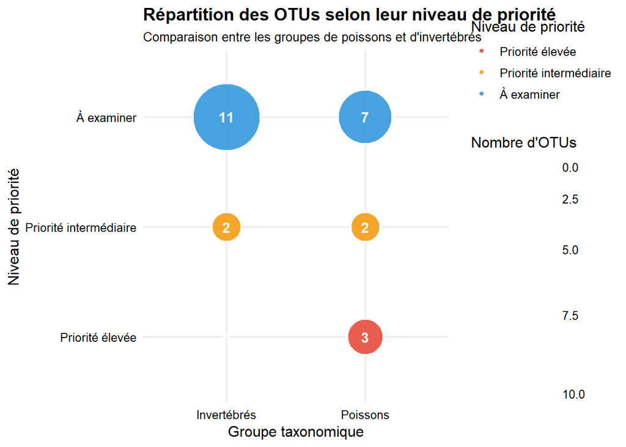

```r
## 50.4. Visualisation de la répartition des OTUs par niveau de priorité

# Préparation des données
resume_priorites_complet_50 <- resume_priorites_50 %>%
  tidyr::complete(
    Groupe,
    Priorite = factor(
      c("Priorité élevée", "Priorité intermédiaire", "À examiner"),
      levels = c(
        "Priorité élevée",
        "Priorité intermédiaire",
        "À examiner"
      )
    ),
    fill = list(Nombre_OTUs = 0)
  )

# Diagramme en bulles
ggplot(
  resume_priorites_complet_50,
  aes(
    x = Groupe,
    y = Priorite,
    size = Nombre_OTUs,
    fill = Priorite
  )
) +
  geom_point(
    shape = 21,
    color = "white",
    alpha = 0.9,
    stroke = 1.2
  ) +
  geom_text(
    aes(label = Nombre_OTUs),
    color = "white",
    fontface = "bold",
    size = 4
  ) +
  scale_fill_manual(
    values = c(
      "Priorité élevée" = "#E74C3C",
      "Priorité intermédiaire" = "#F39C12",
      "À examiner" = "#3498DB"
    )
  ) +
  scale_size_area(max_size = 25) +
  labs(
    title = "Répartition des OTUs selon leur niveau de priorité",
    subtitle = "Comparaison entre les groupes de poissons et d'invertébrés",
    x = "Groupe taxonomique",
    y = "Niveau de priorité",
    size = "Nombre d'OTUs",
    fill = "Niveau de priorité"
  ) +
  theme_minimal(base_size = 12) +
  theme(
    plot.title = element_text(face = "bold", size = 14),
    plot.subtitle = element_text(size = 10),
    axis.text = element_text(color = "black"),
    legend.position = "right",
    panel.grid.minor = element_blank()
  )
```

#### 6.0.4.1 Comparaison des OTUs selon leur nombre de lectures et leur priorité

Contrairement au graphique précédent, qui comparait le nombre d’OTUs dans chaque catégorie, celui-ci montrera le nombre de lectures associé à chaque OTU et son niveau de priorité.

Les poissons et les invertébrés seront présentés dans deux panneaux distincts, avec des échelles indépendantes pour éviter toute comparaison directe des lectures entre les deux marqueurs moléculaires.

**Interprétation du graphique**

Chez les invertébrés, les **OTUs 1301 et 1330** présentent les nombres de lectures les plus élevés, avec respectivement **343 et 335 lectures**. Elles sont classées en priorité intermédiaire. L’**OTU 1953 suit avec 190 lectures** et appartient à la catégorie **« À examiner ».** Les autres **OTUs présentent des nombres de lectures plus faibles, compris entre 9 et 104.**

Chez les poissons, les **OTUs 21 et 33** dominent largement avec respectivement **62 040 et 22 788 lectures.** Elles sont classées en priorité élevée, tout comme l’**OTU 57**, qui totalise **2 048 lectures**. Les **OTUs 121 et 143** présentent respectivement **645 et 513 lectures** et sont classées **« À examiner ».** Les autres OTUs affichent des nombres de lectures nettement plus faibles.

En somme, les **OTUs classées en priorité élevée sont uniquement observées chez les poissons, avec une forte concentration des lectures sur les OTUs 21 et 33.** Chez les invertébrés, les OTUs les plus représentées appartiennent plutôt à la catégorie de **priorité intermédiaire.** Ces résultats permettent de cibler les **OTUs à examiner** lors des vérifications taxonomiques complémentaires.

Il convient de rappeler que le nombre de lectures ne traduit pas directement l’abondance réelle des organismes dans le milieu.

```r
## 50.5. Représentation individuelle des OTUs prioritaires
## Diagramme en tiges (Lollipop plot)

# Préparation des données
donnees_graphique_50 <- otus_prioritaires_50 %>%
  dplyr::mutate(
    OTU_label = paste(Groupe, OTU, sep = " - ")
  )

# Diagramme en tiges
ggplot(
  donnees_graphique_50,
  aes(
    x = Total_lectures,
    y = reorder(OTU_label, Total_lectures),
    color = Priorite
  )
) +
  geom_segment(
    aes(
      x = 0,
      xend = Total_lectures,
      yend = reorder(OTU_label, Total_lectures)
    ),
    linewidth = 1.2,
    alpha = 0.8
  ) +
  geom_point(size = 3.5) +
  geom_text(
    aes(label = Total_lectures),
    hjust = -0.3,
    size = 5,
    show.legend = FALSE
  ) +
  facet_wrap(
    ~ Groupe,
    scales = "free_x"
  ) +
  scale_color_manual(
    values = c(
      "Priorité élevée" = "#E74C3C",
      "Priorité intermédiaire" = "#F39C12",
      "À examiner" = "#3498DB"
    )
  ) +
  scale_x_continuous(
    expand = expansion(mult = c(0.02, 0.20))
  ) +
  labs(
    title = "Nombre de lectures par OTU selon le niveau de priorité",
    subtitle = "Les OTUs sont présentées séparément pour chaque groupe",
    x = "Nombre total de lectures",
    y = "OTUs",
    color = "Niveau de priorité"
  ) +
  theme_minimal(base_size = 11) +
  theme(
    plot.title = element_text(face = "bold", size = 14),
    plot.subtitle = element_text(size = 10),
    axis.text.y = element_text(size = 9),
    strip.text = element_text(face = "bold", size = 11),
    legend.position = "bottom",
    panel.grid.minor = element_blank()
  )
```

[figure not shown]

**Répartition des OTUs selon leur niveau taxonomique**

Elle a permis de visualiser les genres auxquels appartiennent les 25 OTUs atypiques, en distinguant les poissons et les invertébrés.

Ce graphique apporte une autre information : au-delà du nombre de lectures, il montre aussi quels genres taxonomiques sont représentés parmi les OTUs à examiner.

**Interprétation du graphique**

Le graphique met en évidence une répartition différente des OTUs atypiques selon les genres taxonomiques identifiés dans les deux groupes.

Chez les invertébrés, le genre Bosmina est largement dominant avec 9 OTUs, tandis que les genres Bos, Ondatra, Lobosphaera et Felis sont chacun représentés par une seule OTU.

Chez les poissons, le genre Bos domine avec 10 OTUs, suivi du genre Homo avec 2 OTUs.

En somme, les OTUs atypiques des invertébrés sont principalement associées au genre Bosmina, tandis que celles des poissons sont majoritairement associées au genre Bos. La détection de genres tels que Bos, Homo, Ondatra et Felis, qui présentent des assignations taxonomiques inattendues dans le contexte de cette étude, justifie une vérification approfondie des séquences et de leurs annotations afin d’évaluer d’éventuelles erreurs d’assignation ou contaminations.

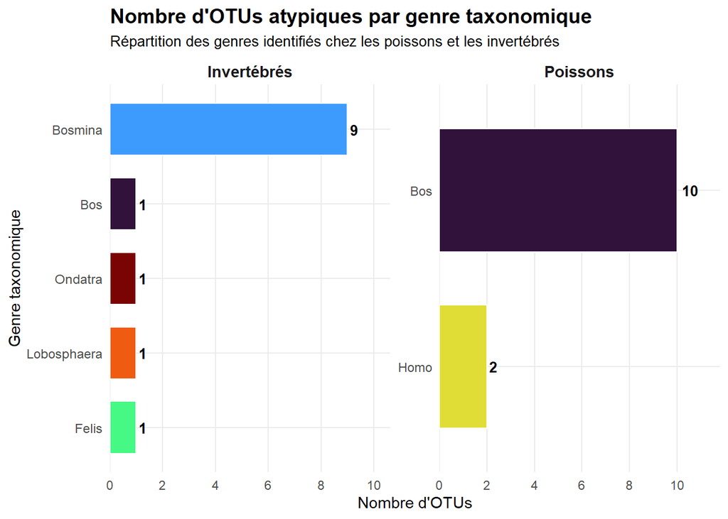

```r
## 50.6. Répartition des OTUs atypiques selon leur genre taxonomique

# Préparation des données
resume_genres_50 <- synthese_otus_50 %>%
  dplyr::mutate(
    Genre = ifelse(
      is.na(Genre) | Genre == "",
      "Genre non identifié",
      Genre
    )
  ) %>%
  dplyr::group_by(Groupe, Genre) %>%
  dplyr::summarise(
    Nombre_OTUs = dplyr::n_distinct(OTU),
    .groups = "drop"
  ) %>%
  dplyr::arrange(Groupe, dplyr::desc(Nombre_OTUs))

# Graphique en barres
ggplot(
  resume_genres_50,
  aes(
    x = reorder(Genre, Nombre_OTUs),
    y = Nombre_OTUs,
    fill = Genre
  )
) +
  geom_col(
    width = 0.7,
    color = "white",
    linewidth = 0.4
  ) +
  geom_text(
    aes(label = Nombre_OTUs),
    hjust = -0.3,
    size = 3.5,
    fontface = "bold"
  ) +
  facet_wrap(
    ~ Groupe,
    scales = "free"
  ) +
  coord_flip() +
  scale_fill_viridis_d(option = "turbo") +
  scale_y_continuous(
    breaks = scales::pretty_breaks(),
    expand = expansion(mult = c(0, 0.18))
  ) +
  labs(
    title = "Nombre d'OTUs atypiques par genre taxonomique",
    subtitle = "Répartition des genres identifiés chez les poissons et les invertébrés",
    x = "Genre taxonomique",
    y = "Nombre d'OTUs",
    fill = "Genre"
  ) +
  theme_minimal(base_size = 11) +
  theme(
    plot.title = element_text(face = "bold", size = 14),
    plot.subtitle = element_text(size = 10),
    strip.text = element_text(face = "bold", size = 11),
    axis.text.y = element_text(size = 9),
    legend.position = "none",
    panel.grid.minor = element_blank()
  )
```

```r
## 50.7. Tableau final de synthèse des OTUs atypiques

tableau_final_50 <- otus_prioritaires_50 %>%
  dplyr::select(
    Groupe,
    OTU,
    Genre,
    Total_lectures,
    Nombre_echantillons,
    Nombre_sites,
    Priorite
  ) %>%
  dplyr::arrange(
    Groupe,
    Priorite,
    dplyr::desc(Total_lectures)
  )

knitr::kable(
  tableau_final_50,
  caption = "Synthèse des OTUs atypiques absentes des contrôles et leur niveau de priorité",
  col.names = c(
    "Groupe",
    "OTU",
    "Genre taxonomique",
    "Nombre de lectures",
    "Nombre d'échantillons",
    "Nombre de sites",
    "Niveau de priorité"
  ),
  align = "l"
)
```

Synthèse des OTUs atypiques absentes des contrôles et leur niveau de priorité

| Groupe | OTU | Genre taxonomique | Nombre de lectures | Nombre d’échantillons | Nombre de sites | Niveau de priorité |
| --- | --- | --- | --- | --- | --- | --- |
| Invertébrés | 1301 | Bos | 343 | 2 | 2 | Priorité intermédiaire |
| Invertébrés | 1330 | Bosmina | 335 | 3 | 3 | Priorité intermédiaire |
| Invertébrés | 1953 | Bosmina | 190 | 1 | 1 | À examiner |
| Invertébrés | 2863 | Bosmina | 104 | 1 | 1 | À examiner |
| Invertébrés | 3086 | Ondatra | 91 | 1 | 1 | À examiner |
| Invertébrés | 3566 | Bosmina | 68 | 1 | 1 | À examiner |
| Invertébrés | 3743 | Bosmina | 61 | 1 | 1 | À examiner |
| Invertébrés | 3893 | Bosmina | 56 | 1 | 1 | À examiner |
| Invertébrés | 3954 | Bosmina | 54 | 1 | 1 | À examiner |
| Invertébrés | 4100 | Bosmina | 49 | 1 | 1 | À examiner |
| Invertébrés | 4232 | Bosmina | 46 | 1 | 1 | À examiner |
| Invertébrés | 6692 | Felis | 10 | 1 | 1 | À examiner |
| Invertébrés | 6927 | Lobosphaera | 9 | 1 | 1 | À examiner |
| Poissons | 21 | Bos | 62040 | 1 | 1 | Priorité élevée |
| Poissons | 33 | Bos | 22788 | 1 | 1 | Priorité élevée |
| Poissons | 57 | Bos | 2048 | 1 | 1 | Priorité élevée |
| Poissons | 291 | Homo | 16 | 2 | 2 | Priorité intermédiaire |
| Poissons | 296 | Homo | 12 | 2 | 2 | Priorité intermédiaire |
| Poissons | 121 | Bos | 645 | 1 | 1 | À examiner |
| Poissons | 143 | Bos | 513 | 1 | 1 | À examiner |
| Poissons | 247 | Bos | 110 | 1 | 1 | À examiner |
| Poissons | 282 | Bos | 34 | 1 | 1 | À examiner |
| Poissons | 300 | Bos | 10 | 1 | 1 | À examiner |
| Poissons | 301 | Bos | 9 | 1 | 1 | À examiner |
| Poissons | 304 | Bos | 8 | 1 | 1 | À examiner |

**Conclusion sur les OTUs atypiques absentes des contrôles**

L’analyse a permis d’identifier 25 OTUs présentant des assignations taxonomiques atypiques et qui n’ont pas été détectées dans les contrôles, dont 13 chez les invertébrés et 12 chez les poissons.

L’examen de leurs annotations taxonomiques a révélé des identifications qui méritent une attention particulière. Chez les invertébrés, plusieurs OTUs sont notamment associées aux genres Bos, Ondatra et Felis, tandis que chez les poissons, la majorité des OTUs concernées sont assignées au genre Bos. Aucune de ces 25 OTUs n’a toutefois obtenu une identification au niveau de l’espèce.

L’analyse spatiale montre que la plupart de ces OTUs ont été détectées sur un seul site. Certaines présentent néanmoins des détections sur plusieurs sites, notamment l’OTU 1330 chez les invertébrés et les OTUs 291 et 296 chez les poissons.

Le classement exploratoire a permis d’identifier trois OTUs de poissons (OTUs 21, 33 et 57) en priorité élevée, quatre OTUs en priorité intermédiaire et les 18 autres dans la catégorie « À examiner ».

Dans l’ensemble, ces résultats soulignent l’importance de vérifier les assignations taxonomiques des OTUs atypiques, notamment par l’examen des séquences et leur comparaison avec des références fiables. L’absence de détection dans les contrôles ne suffit pas à confirmer leur authenticité biologique, tout comme une assignation taxonomique inhabituelle ne constitue pas, à elle seule, une preuve de contamination ou d’erreur. Ces OTUs doivent donc être considérées avec prudence avant toute interprétation écologique.

# 7 Discussion générale

## 7.1 Qualité et fiabilité des données d’ADNe (OS1)

L’évaluation de la qualité des données d’ADN environnemental (ADNe) a permis de mettre en évidence une hétérogénéité des profondeurs de séquençage entre les échantillons biologiques. Chez les invertébrés, les profondeurs ont varié de 36 474 à 201 735 lectures, tandis que chez les poissons, elles se sont étendues de 16 à 172 886 lectures. Ces différences ont soulevé des interrogations sur la représentativité des échantillons faiblement séquencés et sur l’exhaustivité des détections moléculaires.

Ces observations ont présenté des similitudes méthodologiques avec les travaux de Larson et al. (2022), réalisés dans le sud-est de l’Alaska, aux États-Unis. Ces chercheurs ont utilisé le métabarcoding d’ADNe pour caractériser les communautés de poissons côtiers et ont examiné l’influence des réplicats et des procédures de filtrage sur les résultats. Leur étude a permis de retenir 24 taxons après traitement bioinformatique, alors que 167 variants de séquences avaient initialement été identifiés. Cette réduction a illustré l’importance des étapes de filtrage et de validation avant l’interprétation écologique des séquences.

Par ailleurs, Morey et al. (2024), dans une étude consacrée aux poissons d’eau douce canadiens, ont mis en évidence des limites de détection liées aux marqueurs moléculaires, aux amorces et aux bases de référence. Sur 59 espèces évaluées, environ 40 % n’ont pas été détectées de manière constante par les marqueurs étudiés. Ces résultats ont montré qu’une absence de détection moléculaire ne correspond pas nécessairement à une absence biologique.

Dans notre étude, les courbes de raréfaction ont également révélé des niveaux variables de stabilisation. Plusieurs courbes d’invertébrés ont présenté une tendance au plateau, tandis que celles des poissons ont généralement continué à augmenter avec la profondeur de séquençage. Ces observations ont suggéré que l’effort de séquençage n’avait pas permis d’atteindre une exhaustivité comparable pour tous les échantillons.

Ainsi, les résultats obtenus ont confirmé l’importance du contrôle qualité et de la prise en compte des limites de détection, conformément aux préoccupations méthodologiques documentées dans les études canadiennes et américaines.

## 7.2 Diversité moléculaire et répartition spatiale des poissons et des invertébrés (OS2)

### 7.2.1 Richesse et diversité moléculaire

L’analyse des échantillons biologiques a révélé une richesse moyenne de 528,44 OTU chez les invertébrés et de 12,31 OTU chez les poissons. La richesse a varié de 330 à 681 OTU chez les invertébrés et de 1 à 24 OTU chez les poissons. Ces résultats ont mis en évidence une variabilité de la diversité moléculaire détectée au sein de chaque groupe.

Chez les invertébrés, les résultats ont rejoint les observations de Hajibabaei et al. (2011), qui ont utilisé le séquençage à haut débit pour caractériser les communautés d’invertébrés benthiques de milieux fluviaux. Cette étude canadienne a démontré le potentiel du barcoding environnemental pour détecter une diversité taxonomique importante et soutenir les programmes de biosurveillance aquatique.

De même, Hajibabaei et al. (2016) ont souligné l’intérêt des approches moléculaires pour améliorer la caractérisation de la biodiversité et renforcer les méthodes traditionnelles de biosurveillance. Ces travaux ont apporté un appui méthodologique à l’utilisation des OTU comme unités de description de la diversité moléculaire.

Cependant, la différence importante observée entre les poissons et les invertébrés dans notre étude n’a pas permis de conclure à une biodiversité intrinsèquement plus élevée chez les invertébrés. Les deux groupes ont été étudiés avec des marqueurs et des protocoles distincts, ce qui a limité la comparabilité directe de leurs richesses.

Cette précaution a été confortée par Morey et al. (2024), qui ont montré que les performances des marqueurs 12S et COI différaient selon les espèces de poissons et les bases de référence utilisées.

### 7.2.2 Variabilité spatiale des communautés de poissons

Les analyses spatiales ont révélé une répartition variable des détections moléculaires entre les sites étudiés. Ces observations ont suggéré une hétérogénéité spatiale des profils d’OTU, sans toutefois permettre de confirmer des différences écologiques significatives en raison du nombre limité de réplicats par site.

Des résultats comparables ont été rapportés par Berger et al. (2020), dans le secteur de Contrecœur du fleuve Saint-Laurent, au Québec. À partir de 53 stations, les auteurs ont détecté 67 espèces de poissons par métabarcoding d’ADNe et ont mis en évidence des différences significatives de composition entre les masses d’eau. Ces variations ont notamment été associées à la turbidité, à la profondeur et à la position des stations dans le cours d’eau.

Les résultats de notre étude ont présenté une convergence descriptive avec ces travaux concernant l’existence d’une variabilité spatiale des détections. Toutefois, contrairement à Berger et al. (2020), notre étude n’a pas permis d’attribuer cette variabilité à des paramètres environnementaux précis.

Crowley et al. (2024) ont également étudié les communautés de poissons dans 174 sites fluviaux de Terre-Neuve-et-Labrador, au Canada, sur trois années. Leur analyse a permis de caractériser la composition des communautés et d’examiner leurs associations avec des variables climatiques. Ces résultats ont confirmé l’intérêt de combiner les données d’ADNe, les caractéristiques environnementales et les observations historiques pour mieux comprendre l’organisation spatiale des communautés aquatiques.

Dans notre étude, l’absence de séries temporelles et le faible nombre de réplicats ont limité la possibilité d’examiner ces relations. Les variations spatiales ont donc été interprétées comme des tendances descriptives nécessitant des investigations complémentaires.

## 7.3 Contrôles négatifs, signaux atypiques et fiabilité taxonomique (OS3)

### 7.3.1 Détections dans les contrôles négatifs

L’analyse des contrôles négatifs a révélé la présence de certaines OTU dans les blancs de terrain et d’extraction. Ces détections ont conduit à distinguer les signaux nécessitant une vérification des OTU provisoirement conservables.

Des observations similaires ont été rapportées par Larson et al. (2022), dans leur étude sur les poissons côtiers d’Alaska. Les auteurs ont détecté des lectures dans certains contrôles négatifs de terrain, tandis que les contrôles d’extraction et de PCR ont présenté des niveaux de contamination généralement faibles. Leur étude a ainsi montré que la présence de séquences dans les contrôles pouvait varier selon les étapes du protocole.

Dans notre étude, la présence d’une OTU dans un contrôle négatif n’a donc pas été considérée comme une preuve automatique de contamination. Son interprétation a reposé sur une approche exploratoire tenant compte des lectures et des fréquences de détection.

Cette démarche a permis d’éviter l’exclusion systématique de séquences potentiellement informatives, tout en signalant celles qui nécessitaient une vérification complémentaire.

### 7.3.2 OTU à annotations taxonomiques atypiques

L’analyse taxonomique a permis d’identifier 25 OTU présentant des annotations atypiques et absentes des contrôles examinés, dont 13 chez les invertébrés et 12 chez les poissons.

Chez les invertébrés, neuf OTU ont été associées au genre Bosmina, tandis que d’autres ont reçu des annotations correspondant notamment aux genres Bos, Ondatra, Felis et Lobosphaera. Chez les poissons, dix OTU ont été annotées Bos et deux Homo. Aucune des 25 OTU n’a été identifiée au niveau de l’espèce.

Ces résultats ont présenté des similitudes avec les difficultés d’assignation taxonomique documentées par Morey et al. (2024). Ces auteurs ont identifié plusieurs catégories de lacunes de détection chez les poissons d’eau douce canadiens, notamment celles associées aux bases de référence, à la résolution taxonomique et aux performances des amorces.

De leur côté, Larson et al. (2022) ont également signalé des variants de séquences correspondant à des organismes non ciblés ou à des taxons dont la présence locale était improbable. Ces observations ont montré que le métabarcoding pouvait produire des assignations nécessitant un examen complémentaire avant leur validation biologique.

Dans notre étude, les annotations attribuées à des mammifères dans les données de poissons ont ainsi constitué des signaux inhabituels nécessitant une vérification des séquences et des références taxonomiques. En revanche, l’annotation Bosmina chez les invertébrés n’a pas représenté, à elle seule, une incohérence biologique, ce genre appartenant aux cladocères.

Le classement exploratoire des 25 OTU a permis d’identifier trois OTU de poissons (OTU 21, 33 et 57) en priorité élevée, quatre OTU en priorité intermédiaire et 18 OTU dans la catégorie « À examiner ». Cette hiérarchisation a facilité l’identification des séquences à vérifier, sans constituer une confirmation de leur origine biologique.

### 7.3.3 Répartition spatiale des OTU atypiques

L’analyse spatiale a révélé que la majorité des OTU atypiques absentes des contrôles avaient été détectées dans un seul site, soit 11 sur 13 chez les invertébrés et 10 sur 12 chez les poissons.

Ces observations ont indiqué une prédominance des détections spatialement limitées. Certaines OTU ont néanmoins été retrouvées dans plusieurs sites, notamment l’OTU 1330 chez les invertébrés et les OTU 291 et 296 chez les poissons.

Les travaux de Berger et al. (2020) ont montré que la distribution spatiale de l’ADNe pouvait varier fortement à petite échelle dans les milieux fluviaux. Ces résultats ont fourni un cadre scientifique pour discuter de la variabilité spatiale des détections observées dans notre étude.

Toutefois, aucune relation causale n’a pu être établie entre la répartition des OTU atypiques et les caractéristiques environnementales des sites. Leur présence ponctuelle ou répétée n’a pas suffi à confirmer leur authenticité taxonomique.

# 8 Conclusion et perspectives

## 8.1 Conclusion générale et limites méthodologiques

Cette étude a permis d’évaluer la qualité des données d’ADN environnemental (ADNe), de caractériser la diversité moléculaire des poissons et des invertébrés et d’examiner les signaux taxonomiques atypiques. Les analyses ont révélé une richesse en OTU variable entre les échantillons, ainsi que des différences de composition et de répartition spatiale des détections. Les résultats des deux groupes ont toutefois été interprétés séparément en raison des différences de marqueurs et de protocoles.

L’examen des contrôles négatifs a mis en évidence des OTU nécessitant des vérifications complémentaires. Par ailleurs, 25 OTU présentant des annotations taxonomiques atypiques n’ont été détectées dans aucun des contrôles examinés, dont 13 chez les invertébrés et 12 chez les poissons. Parmi elles, trois OTU de poissons ont été classées en priorité élevée.

Plusieurs limites méthodologiques ont néanmoins été identifiées. Aucune des 25 OTU atypiques n’a obtenu une identification au niveau de l’espèce. Leur classement en catégories de priorité a reposé sur des critères exploratoires et n’a donc pas constitué une validation taxonomique ou une preuve de contamination. De plus, les différences de profondeur de séquençage, le faible nombre de réplicats par site et l’absence de confirmation indépendante des séquences ont limité la portée des interprétations écologiques.

Dans l’ensemble, cette étude a fourni une première caractérisation de la biodiversité moléculaire des sites étudiés et a permis de cibler les vérifications nécessaires avant toute utilisation des résultats pour la surveillance écologique.

## 8.2 Perspectives

Les prochaines étapes prioritaires pourraient être :

- de vérifier les échantillons absents des matrices et documenter les profondeurs de séquençage atypiques pour les prochains prélèvements;
- examiner les séquences des OTU prioritaires et confirmer leurs assignations taxonomiques à l’aide de références adaptées;
- revoir les profils de détection dans les blancs en tenant compte du type de contrôle, de la prévalence et du nombre de lectures;
- compléter les métadonnées spatiales et augmenter, lorsque possible, le nombre de réplicats par site;
- interpréter les comparaisons entre poissons et invertébrés séparément, en tenant compte des différences de marqueurs et de protocoles.

# 9 Impact sociétal et recommandations politiques

Cette étude a mis en évidence l’intérêt de l’ADNe comme outil complémentaire de surveillance de la biodiversité aquatique. Les analyses ont permis de documenter des signaux moléculaires chez les poissons et les invertébrés et d’identifier les limites nécessitant une attention particulière avant leur utilisation dans les décisions environnementales.

Les résultats ont souligné l’importance de renforcer les dispositifs de suivi écologique par l’intégration progressive des approches moléculaires aux méthodes conventionnelles d’inventaire.

Sur le plan des politiques publiques, il a été recommandé de promouvoir des protocoles harmonisés de prélèvement, de séquençage et de contrôle qualité, de soutenir la constitution de bases de référence taxonomiques fiables et d’encourager la répétition des prélèvements dans le temps.

L’intégration de ces recommandations pourrait contribuer à améliorer la détection précoce des changements de biodiversité, la gestion des milieux aquatiques et l’orientation des actions de conservation.

## 9.1 Orientations scientifiques futures

Les travaux futurs devront privilégier la validation des 25 OTU atypiques par comparaison de leurs séquences avec des bases de référence fiables et, lorsque nécessaire, par des méthodes moléculaires complémentaires. L’augmentation du nombre de réplicats biologiques et temporels permettra de mieux caractériser la variabilité des détections. Une attention particulière devra également être accordée aux échantillons faiblement séquencés et aux signaux présents dans les contrôles négatifs. Enfin, l’intégration de paramètres environnementaux pourrait permettre d’explorer les facteurs associés aux variations de diversité moléculaire.

# 10 Difficultés rencontrées et solutions employées

## 10.1 Difficultés

L’analyse des données d’ADNe a présenté plusieurs difficultés méthodologiques et techniques. Des différences entre les identifiants des fichiers de métadonnées et ceux des matrices d’OTU ont nécessité des vérifications préalables. L’hétérogénéité des profondeurs de séquençage a également compliqué l’interprétation de la richesse moléculaire. Certaines coordonnées géographiques manquantes ont limité les représentations spatiales. Par ailleurs, la présence d’OTU dans les contrôles négatifs et l’identification de taxons atypiques ont soulevé des incertitudes concernant la fiabilité de certaines détections.

## 10.2 Solutions employées

Pour répondre à ces difficultés, des procédures de vérification des identifiants, de nettoyage des données et de contrôle des valeurs manquantes ont été appliquées. Les analyses de diversité ont été interprétées en tenant compte des différences de profondeur de séquençage. Les données géographiques ont été vérifiées avant leur cartographie. Enfin, les détections dans les contrôles et les annotations taxonomiques atypiques ont été examinées séparément, puis les OTU concernées ont été hiérarchisées afin d’orienter les validations complémentaires.

## 10.3 Note

Les résultats ont reposé sur des détections moléculaires exploratoires. Ils n’ont constitué ni une confirmation définitive des espèces ni une estimation directe de leur abondance.

# 11 Références bibliographiques

[1] Berger, C. S., Hernandez, C., Laporte, M., Côté, G., Paradis, Y., Kameni T. M., N., Normandeau, E., & Bernatchez, L. (2020). Fine-scale environmental heterogeneity shapes fluvial fish communities as revealed by eDNA metabarcoding. Environmental DNA, 2(4), 647–666. https://doi.org/10.1002/edn3.129

[2] Crowley, S. E., Bentzen, P., Kess, T., Duffy, S. J., Messmer, A. M., Watson, B., Dempson, J. B., Keefe, D. G., Perry, R. C., Marquis, B., Hajibabaei, M., Fahner, N., Berghuis, L., Hobrecker, K., & Bradbury, I. R. (2024). eDNA metabarcoding reveals riverine fish community structure and climate associations in northeastern Canada. Environmental DNA, 6, e517. https://doi.org/10.1002/edn3.517

[3] Hajibabaei, M., Shokralla, S., Zhou, X., Singer, G. A. C., & Baird, D. J. (2011). Environmental barcoding: A next-generation sequencing approach for biomonitoring applications using river benthos. PLOS ONE, 6(4), e17497. https://doi.org/10.1371/journal.pone.0017497

[4] Hajibabaei, M., Baird, D. J., Fahner, N. A., Beiko, R., & Golding, G. B. (2016). A new way to contemplate Darwin’s tangled bank: How DNA barcodes are reconnecting biodiversity science and biomonitoring. Philosophical Transactions of the Royal Society B: Biological Sciences, 371(1702), 20150330. https://doi.org/10.1098/rstb.2015.0330

[5] Larson, W. A., Barry, P., Dokai, W., Maselko, J., Olson, J., & Baetscher, D. (2022). Leveraging eDNA metabarcoding to characterize nearshore fish communities in Southeast Alaska: Do habitat and tide matter? Environmental DNA. https://doi.org/10.1002/edn3.297

[6] Morey, K. C., Myler, E., Hanner, R., & Tetreault, G. (2024). Taxonomic blind spots: A limitation of environmental DNA metabarcoding-based detection for Canadian freshwater fishes. Environmental DNA, 6, e70054. https://doi.org/10.1002/edn3.70054